# Causal inference Hernan

Yazhuo Deng

January 10, 2019

## 0.1 Causal inference Hernan

### 0.1.1 Chapter 11

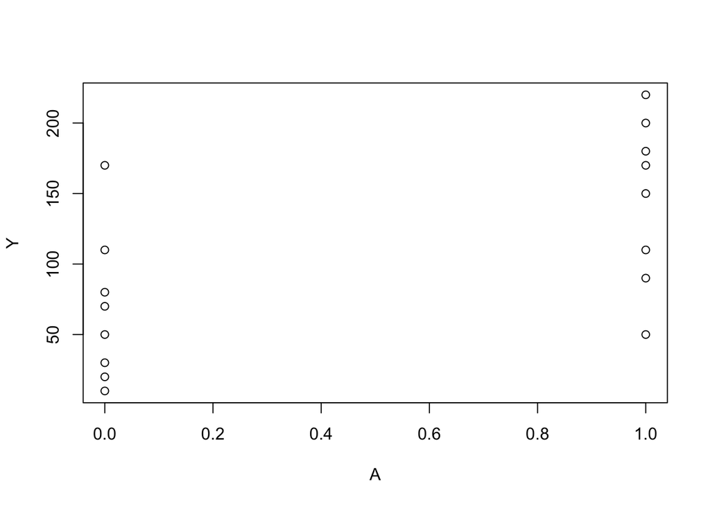

```r
#PROGRAM 11.1
#Sample averages by treatment level
#Data from Figures 11.1 and 11.2


##Install packages "Hmisc" and "rms" if necessary.

library(Hmisc)
library(rms)
A<-c(1,1,1,1,1,1,1,1,0,0,0,0,0,0,0,0)
Y<-c(200,150,220,110,50,180,90,170,170,30,70,110,80,50,10,20)

plot(A,Y)
```

```r
describe(Y[A==1])
```

```
## Y[A == 1]
##        n  missing distinct     Info     Mean      Gmd
##        8        0        8        1    146.2    70.36
##
## Value         50    90   110   150   170   180   200   220
## Frequency      1     1     1     1     1     1     1     1
## Proportion 0.125 0.125 0.125 0.125 0.125 0.125 0.125 0.125
```

```r
describe(Y[A==0])
```

```
## Y[A == 0]
##        n  missing distinct     Info     Mean      Gmd
##        8        0        8        1     67.5    62.14
##
## Value         10    20    30    50    70    80   110   170
## Frequency      1     1     1     1     1     1     1     1
## Proportion 0.125 0.125 0.125 0.125 0.125 0.125 0.125 0.125
```

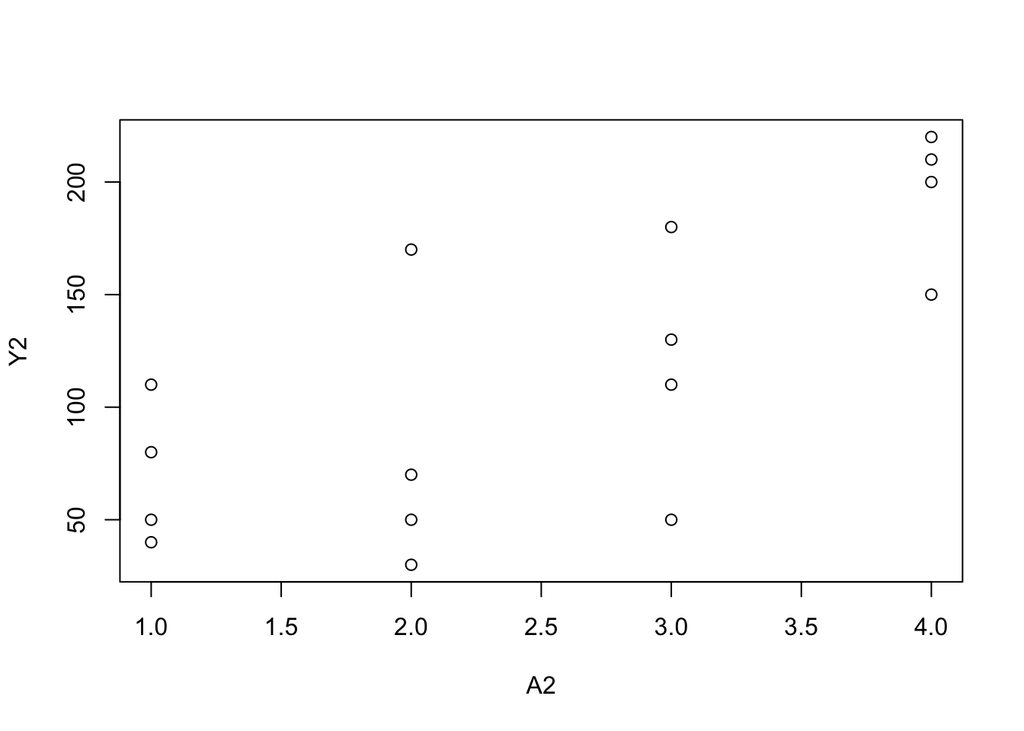

```r
A2<-c(1,1,1,1,2,2,2,2,3,3,3,3,4,4,4,4)
Y2<-c(110,80,50,40,170,30,70,50,110,50,180,130,200,150,220,210)


plot(A2,Y2)
```

```r
describe(Y2[A2==1])
```

```
## Y2[A2 == 1]
##        n  missing distinct     Info     Mean      Gmd
##        4        0        4        1       70       40
##
## Value        40   50   80  110
## Frequency     1    1    1    1
## Proportion 0.25 0.25 0.25 0.25
```

```r
describe(Y2[A2==2])
```

```
## Y2[A2 == 2]
##        n  missing distinct     Info     Mean      Gmd
##        4        0        4        1       80    73.33
##
## Value        30   50   70  170
## Frequency     1    1    1    1
## Proportion 0.25 0.25 0.25 0.25
```

```r
describe(Y2[A2==3])
```

```
## Y2[A2 == 3]
##        n  missing distinct     Info     Mean      Gmd
##        4        0        4        1    117.5    68.33
##
## Value        50  110  130  180
## Frequency     1    1    1    1
## Proportion 0.25 0.25 0.25 0.25
```

```r
describe(Y2[A2==4])
```

```
## Y2[A2 == 4]
##        n  missing distinct     Info     Mean      Gmd
##        4        0        4        1      195    36.67
##
## Value       150  200  210  220
## Frequency     1    1    1    1
## Proportion 0.25 0.25 0.25 0.25
```

```r
#PROGRAM 11.2
#2-parameter linear model
#Data from Figures 11.3 and 11.1

A3<-c(3,11,17,23,29,37,41,53,67,79,83,97,60,71,15,45)
Y3<-c(21,54,33,101,85,65,157,120,111,200,140,220,230,217,11,190)

ols(Y3~A3)
```

```
## Linear Regression Model
##
##  ols(formula = Y3 ~ A3)
##
##                  Model Likelihood     Discrimination
##                     Ratio Test           Indexes
##  Obs       16    LR chi2     17.80    R2       0.671
##  sigma44.0920    d.f.            1    R2 adj   0.648
##  d.f.      14    Pr(> chi2) 0.0000    g       72.147
##
##  Residuals
##
##      Min      1Q  Median      3Q     Max
##  -61.930 -30.564  -5.741  30.653  77.225
##
##
##            Coef    S.E.    t    Pr(>|t|)
##  Intercept 24.5464 21.3300 1.15 0.2691
##  A3         2.1372  0.3997 5.35 0.0001
##
```

```r
ols(Y~A)
```

```
## Linear Regression Model
##
##  ols(formula = Y ~ A)
##
##                  Model Likelihood     Discrimination
##                     Ratio Test           Indexes
##  Obs       16    LR chi2      7.21    R2       0.363
##  sigma55.7658    d.f.            1    R2 adj   0.317
##  d.f.      14    Pr(> chi2) 0.0072    g       42.000
##
##  Residuals
##
##      Min      1Q  Median      3Q     Max
##  -96.250 -40.000   3.125  35.938 102.500
##
##
##            Coef    S.E.    t    Pr(>|t|)
##  Intercept 67.5000 19.7162 3.42 0.0041
##  A         78.7500 27.8829 2.82 0.0135
##
```

```r
#PROGRAM 11.3
#3-parameter linear model
#Data from Figure 11.3
Asq<-A3*A3

ols(Y3~A3+Asq)
```

```
## Linear Regression Model
##
##  ols(formula = Y3 ~ A3 + Asq)
##
##                  Model Likelihood     Discrimination
##                     Ratio Test           Indexes
##  Obs       16    LR chi2     19.84    R2       0.711
##  sigma42.9267    d.f.            2    R2 adj   0.666
##  d.f.      13    Pr(> chi2) 0.0000    g       73.404
##
##  Residuals
##
##     Min     1Q Median     3Q    Max
##  -65.27 -34.42  13.21  26.11  64.36
##
##
##            Coef    S.E.    t     Pr(>|t|)
##  Intercept -7.4069 31.7478 -0.23 0.8192
##  A3         4.1072  1.5309  2.68 0.0188
##  Asq       -0.0204  0.0153 -1.33 0.2062
##
```

### 0.1.2 Chapter 12 IP WEIGHTING AND MARGINAL STRUCTURAL MODELS

```r
#####################################################
# PROGRAM 12.1
# Descriptive statistics from NHEFS data (Table 12.1)
#####################################################

# rm(list=ls(all=TRUE))
# setwd("C:\\Users\\ehsan\\code\\causal") # contains SAS datafile
# reading external data file
#install.packages("sas7bdat")
#library(sas7bdat)
#nhefs <- read.sas7bdat("nhefs_book.sas7bdat")
# or if csv file is available:
nhefs <- read.csv("nhefs.csv")
nhefs <- as.data.frame(nhefs)

#wt82: WEIGHT IN KILOGRAMS  IN 1982
nhefs$cens <- as.numeric(is.na(nhefs$wt82))
nhefs$older <- as.numeric(nhefs$age > 50 & !is.na(nhefs$age))
#install.packages("car")
library(car)
nhefs$education.code <- recode(nhefs$school, " 0:8 = 1; 9:11 = 2; 12 = 3;
                         13:15 = 4; 16:hi = 5; NA = 6 ")
nhefs$education <- recode(nhefs$education.code, " 1 = '1. 8th grade or less';
                    2 = '2. HS dropout';
                          3 = '3. HS';
                          4 = '4. College dropout';
                          5 = '5. College or more';
                          6 = 'Unknown' ")

# Analysis restricted to N=1566
# with non-missing values in the following covariates
nhefs.original <- nhefs # Original data saved for later use
nhefs$id <- 1:nrow(nhefs)
nhefs2 <- nhefs[c("id", "qsmk", "sex", "race", "age", "school",
                  "smokeintensity", "smokeyrs", "exercise", "active",
                  "wt71", "wt82")]
dim(nhefs2)
```

```
## [1] 1746   12
```

```r
nhefs2 <- as.data.frame(na.omit(nhefs2))
dim(nhefs2)
```

```
## [1] 1566   12
```

```r
nhefs <- subset(nhefs, id %in% nhefs2$id)
rm(nhefs2)
dim(nhefs)
```

```
## [1] 1566   66
```

```r
# mean weight change in those with and without smoking cessation
# qsmk:QUIT SMOKING BETWEEN 1ST QUESTIONNAIRE AND 1982, 1:YES, 0:NO
summary(nhefs$wt82_71[nhefs$cens == 0 & nhefs$qsmk == 0])
```

```
##    Min. 1st Qu.  Median    Mean 3rd Qu.    Max.
## -41.280  -1.811   2.151   1.984   6.119  48.538
```

```r
sd(nhefs$wt82_71[nhefs$cens == 0 & nhefs$qsmk == 0])
```

```
## [1] 7.449076
```

```r
summary(nhefs$wt82_71[nhefs$cens == 0 & nhefs$qsmk == 1])
```

```
##     Min.  1st Qu.   Median     Mean  3rd Qu.     Max.
## -22.2305  -0.1704   3.9716   4.5251   9.6948  47.5113
```

```r
sd(nhefs$wt82_71[nhefs$cens == 0 & nhefs$qsmk == 1])
```

```
## [1] 8.748261
```

```r
#if quit smoking, they gain more weight.
summary(glm(wt82_71 ~ qsmk, data = subset(nhefs, cens == 0)))
```

```
##
## Call:
## glm(formula = wt82_71 ~ qsmk, data = subset(nhefs, cens == 0))
##
## Deviance Residuals:
##     Min       1Q   Median       3Q      Max
## -43.265   -4.023    0.033    4.248   46.554
##
## Coefficients:
##             Estimate Std. Error t value Pr(>|t|)
## (Intercept)   1.9845     0.2288   8.672  < 2e-16 ***
## qsmk          2.5406     0.4511   5.632 2.11e-08 ***
## ---
## Signif. codes:  0 '***' 0.001 '**' 0.01 '*' 0.05 '.' 0.1 ' ' 1
##
## (Dispersion parameter for gaussian family taken to be 60.89757)
##
##     Null deviance: 97176  on 1565  degrees of freedom
## Residual deviance: 95244  on 1564  degrees of freedom
## AIC: 10883
##
## Number of Fisher Scoring iterations: 2
```

```r
# restricting data for uncensored
nhefs0 <- subset(nhefs, cens == 0)

# baseline characteristics
years1 <-mean(nhefs0$age[nhefs0$qsmk == 1])
years0 <-mean(nhefs0$age[nhefs0$qsmk == 0])
male1 <-100*mean(nhefs0$sex[nhefs0$qsmk == 1]==0)
male0 <-100*mean(nhefs0$sex[nhefs0$qsmk == 0]==0)
white1 <-100*mean(nhefs0$race[nhefs0$qsmk == 1]==0)
white0 <-100*mean(nhefs0$race[nhefs0$qsmk == 0]==0)
university1 <-100*mean(nhefs0$education.code[nhefs0$qsmk == 1]==5)
university0 <-100*mean(nhefs0$education.code[nhefs0$qsmk == 0]==5)
kg1 <-mean(nhefs0$wt71[nhefs0$qsmk == 1])
kg0 <-mean(nhefs0$wt71[nhefs0$qsmk == 0])
cigs1 <-mean(nhefs0$smokeintensity[nhefs0$qsmk == 1])
cigs0 <-mean(nhefs0$smokeintensity[nhefs0$qsmk == 0])
smoke1 <-mean(nhefs0$smokeyrs[nhefs0$qsmk == 1])
smoke0 <-mean(nhefs0$smokeyrs[nhefs0$qsmk == 0])
noexer1 <-100*mean(nhefs0$exercise[nhefs0$qsmk == 1]==2)
noexer0 <-100*mean(nhefs0$exercise[nhefs0$qsmk == 0]==2)
inactive1 <-100*mean(nhefs0$active[nhefs0$qsmk == 1]==2)
inactive0 <-100*mean(nhefs0$active[nhefs0$qsmk == 0]==2)

baseline.char <- round(matrix(c(years1, years0, male1, male0, white1, white0,
                                university1, university0, kg1, kg0, cigs1, cigs0, smoke1,
                                smoke0, noexer1, noexer0, inactive1, inactive0),
                              ncol = 2, byrow=T), 1)
dimnames(baseline.char) <- list(c("age, years", "men, %", "white, %",
                                  "university, %", "weight, kg",
                                  "Chigarettes/day", "year smoking",
                                  "little/no exercise, %",
                                  "inactive daily life, %"),
                                c("Smoking cessation (A=1)","No smoking cessation (A=0)"))
print(baseline.char)
```

```
##                        Smoking cessation (A=1) No smoking cessation (A=0)
## age, years                                46.2                       42.8
## men, %                                    54.6                       46.6
## white, %                                  91.1                       85.4
## university, %                             15.4                        9.9
## weight, kg                                72.4                       70.3
## Chigarettes/day                           18.6                       21.2
## year smoking                              26.0                       24.1
## little/no exercise, %                     40.7                       37.9
## inactive daily life, %                    11.2                        8.9
```

```r
#####################################################
# PROGRAM 12.2
# Estimating IP weights
# Data from NHEFS
#####################################################

# Estimation of ip weights via a logistic model
fit <- glm(qsmk ~ as.factor(sex) + as.factor(race) + age + I(age^2) +
  as.factor(education.code) + smokeintensity +
  I(smokeintensity^2) + smokeyrs + I(smokeyrs^2) +
  as.factor(exercise) + as.factor(active) + wt71 + I(wt71^2),
           family = binomial(), data = nhefs0)
summary(fit)
```

```
##
## Call:
## glm(formula = qsmk ~ as.factor(sex) + as.factor(race) + age +
##     I(age^2) + as.factor(education.code) + smokeintensity + I(smokeintensity^2) +
##     smokeyrs + I(smokeyrs^2) + as.factor(exercise) + as.factor(active) +
##     wt71 + I(wt71^2), family = binomial(), data = nhefs0)
##
## Deviance Residuals:
##     Min       1Q   Median       3Q      Max
## -1.5127  -0.7907  -0.6387   0.9832   2.3729
##
## Coefficients:
##                              Estimate Std. Error z value Pr(>|z|)
## (Intercept)                -2.2425191  1.3808360  -1.624 0.104369
## as.factor(sex)1            -0.5274782  0.1540496  -3.424 0.000617 ***
## as.factor(race)1           -0.8392636  0.2100665  -3.995 6.46e-05 ***
## age                         0.1212052  0.0512663   2.364 0.018068 *
## I(age^2)                   -0.0008246  0.0005361  -1.538 0.124039
## as.factor(education.code)2 -0.0287755  0.1983506  -0.145 0.884653
## as.factor(education.code)3  0.0864318  0.1780850   0.485 0.627435
## as.factor(education.code)4  0.0636010  0.2732108   0.233 0.815924
## as.factor(education.code)5  0.4759606  0.2262237   2.104 0.035384 *
## smokeintensity             -0.0772704  0.0152499  -5.067 4.04e-07 ***
## I(smokeintensity^2)         0.0010451  0.0002866   3.647 0.000265 ***
## smokeyrs                   -0.0735966  0.0277775  -2.650 0.008061 **
## I(smokeyrs^2)               0.0008441  0.0004632   1.822 0.068398 .
## as.factor(exercise)1        0.3548405  0.1801351   1.970 0.048855 *
## as.factor(exercise)2        0.3957040  0.1872400   2.113 0.034571 *
## as.factor(active)1          0.0319445  0.1329372   0.240 0.810100
## as.factor(active)2          0.1767840  0.2149720   0.822 0.410873
## wt71                       -0.0152357  0.0263161  -0.579 0.562625
## I(wt71^2)                   0.0001352  0.0001632   0.829 0.407370
## ---
## Signif. codes:  0 '***' 0.001 '**' 0.01 '*' 0.05 '.' 0.1 ' ' 1
##
## (Dispersion parameter for binomial family taken to be 1)
##
##     Null deviance: 1786.1  on 1565  degrees of freedom
## Residual deviance: 1676.9  on 1547  degrees of freedom
## AIC: 1714.9
##
## Number of Fisher Scoring iterations: 4
```

```r
p.qsmk.obs <- ifelse(nhefs0$qsmk == 0, 1 - predict(fit, type = "response"),
                     predict(fit, type = "response"))
nhefs0$w <- 1/p.qsmk.obs
summary(nhefs0$w)
```

```
##    Min. 1st Qu.  Median    Mean 3rd Qu.    Max.
##   1.054   1.230   1.373   1.996   1.990  16.700
```

```r
sd(nhefs0$w)
```

```
## [1] 1.474787
```

```r
# Estimates from a GEE
#install.packages("geepack")
require(geepack)
gee.obj <- geeglm(wt82_71~qsmk, data = nhefs0, std.err = 'san.se',
                  weights = w, id=seqn, corstr="independence")
summary(gee.obj)
```

```
##
## Call:
## geeglm(formula = wt82_71 ~ qsmk, data = nhefs0, weights = w,
##     id = seqn, corstr = "independence", std.err = "san.se")
##
##  Coefficients:
##             Estimate Std.err  Wald Pr(>|W|)
## (Intercept)   1.7800  0.2247 62.73 2.33e-15 ***
## qsmk          3.4405  0.5255 42.87 5.86e-11 ***
## ---
## Signif. codes:  0 '***' 0.001 '**' 0.01 '*' 0.05 '.' 0.1 ' ' 1
##
## Estimated Scale Parameters:
##             Estimate Std.err
## (Intercept)    65.06   4.221
##
## Correlation: Structure = independenceNumber of clusters:   1566   Maximum cluster size: 1
```

```r
#install.packages("multcomp")
library(multcomp)
#install.packages("BSagri")
library(BSagri)
comp<-glht(gee.obj)
CIadj<-CIGLM(comp,method="Adj")
CIadj # Confidence interval is slightly off
```

```
##
##   Simultaneous Confidence Intervals
##
## Fit: geeglm(formula = wt82_71 ~ qsmk, data = nhefs0, weights = w,
##     id = seqn, corstr = "independence", std.err = "san.se")
##
## Quantile = 2.221
## 95% family-wise confidence level
##
##
## Linear Hypotheses:
##                  Estimate lwr   upr
## (Intercept) == 0 1.780    1.281 2.279
## qsmk == 0        3.441    2.273 4.608
```

```r
# Estimates from a GLM with cluster option
glm.obj <- glm(wt82_71 ~ qsmk + cluster(seqn), data = nhefs0, weights = w)
summary(glm.obj)
```

```
##
## Call:
## glm(formula = wt82_71 ~ qsmk + cluster(seqn), data = nhefs0,
##     weights = w)
##
## Deviance Residuals:
##    Min      1Q  Median      3Q     Max
## -56.82   -5.40   -0.07    5.22   83.85
##
## Coefficients:
##               Estimate Std. Error t value Pr(>|t|)
## (Intercept)   1.02e+00   5.37e-01    1.89    0.059 .
## qsmk          3.45e+00   4.08e-01    8.45   <2e-16 ***
## cluster(seqn) 4.56e-05   2.71e-05    1.69    0.092 .
## ---
## Signif. codes:  0 '***' 0.001 '**' 0.01 '*' 0.05 '.' 0.1 ' ' 1
##
## (Dispersion parameter for gaussian family taken to be 129.9)
##
##     Null deviance: 212651  on 1565  degrees of freedom
## Residual deviance: 203031  on 1563  degrees of freedom
## AIC: 11232
##
## Number of Fisher Scoring iterations: 2
```

```r
comp<-glht(glm.obj)
CIadj<-CIGLM(comp,method="Adj")
CIadj
```

```
##
##   Simultaneous Confidence Intervals
##
## Fit: glm(formula = wt82_71 ~ qsmk + cluster(seqn), data = nhefs0,
##     weights = w)
##
## Quantile = 2.323
## 95% family-wise confidence level
##
##
## Linear Hypotheses:
##                    Estimate  lwr       upr
## (Intercept) == 0    1.02e+00 -2.32e-01  2.26e+00
## qsmk == 0           3.45e+00  2.50e+00  4.39e+00
## cluster(seqn) == 0  4.56e-05 -1.73e-05  1.09e-04
```

```r
vcov(glm.obj)
```

```
##               (Intercept)       qsmk cluster(seqn)
## (Intercept)     2.885e-01 -8.473e-02    -1.228e-05
## qsmk           -8.473e-02  1.662e-01     1.043e-07
## cluster(seqn)  -1.228e-05  1.043e-07     7.334e-10
```

```r
# install.packages("sandwich")
require(sandwich)
beta <- coef(glm.obj)
SE <-sqrt(diag(vcovHC(glm.obj, type="HC0"))) # robust standard errors
lcl <- beta-1.96*SE
ucl <- beta+1.96*SE
round(cbind(beta, lcl, ucl),1)[2,]
```

```
## beta  lcl  ucl
##  3.4  2.4  4.5
```

```r
# no association between sex and qsmk in pseudo-population
#install.packages("descr")
require(descr)
```

```r
crosstab(nhefs0$sex, nhefs0$qsmk, weight = nhefs0$w, plot = F, format = "SAS")
```

```
##    Cell Contents
## |-------------------------|
## |                       N |
## |-------------------------|
##
## =================================
##               nhefs0$qsmk
## nhefs0$sex       0      1   Total
## ---------------------------------
## 0              764    764    1528
## ---------------------------------
## 1              802    797    1599
## ---------------------------------
## Total         1566   1561    3127
## =================================
```

```r
# Numbers are approximately double: weight = nhefs0$w/2 makes it close

# "check" for positivity
age.restr <- nhefs0$age[nhefs0$race == 0 & nhefs0$sex == 1]
qsmk.restr <- nhefs0$qsmk[nhefs0$race == 0 & nhefs0$sex == 1]
CrossTable(age.restr, qsmk.restr, expected = F, format = "SAS")
```

```
##    Cell Contents
## |-------------------------|
## |                       N |
## | Chi-square contribution |
## |           N / Row Total |
## |           N / Col Total |
## |         N / Table Total |
## |-------------------------|
##
## ==================================
##              qsmk.restr
## age.restr        0       1   Total
## ----------------------------------
## 25              24       3      27
##              0.574   1.834
##              0.889   0.111   0.039
##              0.046   0.018
##              0.035   0.004
## ----------------------------------
## 26              14       5      19
##              0.015   0.049
##              0.737   0.263   0.028
##              0.027   0.030
##              0.020   0.007
## ----------------------------------
## 27              18       2      20
##              0.503   1.606
##              0.900   0.100   0.029
##              0.034   0.012
##              0.026   0.003
## ----------------------------------
## 28              20       5      25
##              0.048   0.154
##              0.800   0.200   0.036
##              0.038   0.030
##              0.029   0.007
## ----------------------------------
## 29              15       4      19
##              0.019   0.062
##              0.789   0.211   0.028
```

[output cut: 249 more lines]

```
## 72               2       2       4
##              0.359   1.149
##              0.500   0.500   0.006
##              0.004   0.012
##              0.003   0.003
## ----------------------------------
## 74               0       1       1
##              0.762   2.433
##              0.000   1.000   0.001
##              0.000   0.006
##              0.000   0.001
## ----------------------------------
## Total          524     164     688
##              0.762   0.238
## ==================================
```

```r
#####################################################
# PROGRAM 12.3
# Estimating stabilized IP weights
# Data from NHEFS
#####################################################

# estimation of denominator of ip weights
denom.fit <- glm(qsmk ~ as.factor(sex) + as.factor(race) + age + I(age^2) +
  as.factor(education.code) + smokeintensity +
  I(smokeintensity^2) + smokeyrs + I(smokeyrs^2) +
  as.factor(exercise) + as.factor(active) + wt71 + I(wt71^2),
                 family = binomial(), data = nhefs0)
summary(denom.fit)
```

```
##
## Call:
## glm(formula = qsmk ~ as.factor(sex) + as.factor(race) + age +
##     I(age^2) + as.factor(education.code) + smokeintensity + I(smokeintensity^2) +
##     smokeyrs + I(smokeyrs^2) + as.factor(exercise) + as.factor(active) +
##     wt71 + I(wt71^2), family = binomial(), data = nhefs0)
##
## Deviance Residuals:
##    Min      1Q  Median      3Q     Max
## -1.513  -0.791  -0.639   0.983   2.373
##
## Coefficients:
##                             Estimate Std. Error z value Pr(>|z|)
## (Intercept)                -2.242519   1.380836   -1.62  0.10437
## as.factor(sex)1            -0.527478   0.154050   -3.42  0.00062 ***
## as.factor(race)1           -0.839264   0.210067   -4.00  6.5e-05 ***
## age                         0.121205   0.051266    2.36  0.01807 *
## I(age^2)                   -0.000825   0.000536   -1.54  0.12404
## as.factor(education.code)2 -0.028776   0.198351   -0.15  0.88465
## as.factor(education.code)3  0.086432   0.178085    0.49  0.62744
## as.factor(education.code)4  0.063601   0.273211    0.23  0.81592
## as.factor(education.code)5  0.475961   0.226224    2.10  0.03538 *
## smokeintensity             -0.077270   0.015250   -5.07  4.0e-07 ***
## I(smokeintensity^2)         0.001045   0.000287    3.65  0.00027 ***
## smokeyrs                   -0.073597   0.027777   -2.65  0.00806 **
## I(smokeyrs^2)               0.000844   0.000463    1.82  0.06840 .
## as.factor(exercise)1        0.354841   0.180135    1.97  0.04885 *
## as.factor(exercise)2        0.395704   0.187240    2.11  0.03457 *
## as.factor(active)1          0.031944   0.132937    0.24  0.81010
## as.factor(active)2          0.176784   0.214972    0.82  0.41087
## wt71                       -0.015236   0.026316   -0.58  0.56262
## I(wt71^2)                   0.000135   0.000163    0.83  0.40737
## ---
## Signif. codes:  0 '***' 0.001 '**' 0.01 '*' 0.05 '.' 0.1 ' ' 1
##
## (Dispersion parameter for binomial family taken to be 1)
##
##     Null deviance: 1786.1  on 1565  degrees of freedom
## Residual deviance: 1676.9  on 1547  degrees of freedom
## AIC: 1715
##
## Number of Fisher Scoring iterations: 4
```

```r
denom.p <- predict(denom.fit, type = "response")

# estimation of numerator of ip weights
numer.fit <- glm(qsmk~1, family = binomial(), data = nhefs0)
summary(numer.fit)
```

```
##
## Call:
## glm(formula = qsmk ~ 1, family = binomial(), data = nhefs0)
##
## Deviance Residuals:
##    Min      1Q  Median      3Q     Max
## -0.771  -0.771  -0.771   1.648   1.648
##
## Coefficients:
##             Estimate Std. Error z value Pr(>|z|)
## (Intercept)  -1.0598     0.0578   -18.3   <2e-16 ***
## ---
## Signif. codes:  0 '***' 0.001 '**' 0.01 '*' 0.05 '.' 0.1 ' ' 1
##
## (Dispersion parameter for binomial family taken to be 1)
##
##     Null deviance: 1786.1  on 1565  degrees of freedom
## Residual deviance: 1786.1  on 1565  degrees of freedom
## AIC: 1788
##
## Number of Fisher Scoring iterations: 4
```

```r
numer.p <- predict(numer.fit, type = "response")

nhefs0$sw <- ifelse(nhefs0$qsmk == 0, ((1-numer.p)/(1-denom.p)),
                    (numer.p/denom.p))

summary(nhefs0$sw)
```

```
##    Min. 1st Qu.  Median    Mean 3rd Qu.    Max.
##   0.331   0.867   0.950   0.999   1.079   4.298
```

```r
glm.obj <- glm(wt82_71~ qsmk + cluster(seqn), data = nhefs0, weights = sw)
summary(glm.obj)
```

```
##
## Call:
## glm(formula = wt82_71 ~ qsmk + cluster(seqn), data = nhefs0,
##     weights = sw)
##
## Deviance Residuals:
##    Min      1Q  Median      3Q     Max
## -42.88   -3.91   -0.05    4.27   47.64
##
## Coefficients:
##               Estimate Std. Error t value Pr(>|t|)
## (Intercept)   1.09e+00   4.96e-01    2.20    0.028 *
## qsmk          3.45e+00   4.51e-01    7.64  3.6e-14 ***
## cluster(seqn) 4.12e-05   2.63e-05    1.57    0.117
## ---
## Signif. codes:  0 '***' 0.001 '**' 0.01 '*' 0.05 '.' 0.1 ' ' 1
##
## (Dispersion parameter for gaussian family taken to be 60.67)
##
##     Null deviance: 98509  on 1565  degrees of freedom
## Residual deviance: 94826  on 1563  degrees of freedom
## AIC: 10933
##
## Number of Fisher Scoring iterations: 2
```

```r
comp<-glht(glm.obj)
CIadj<-CIGLM(comp,method="Adj")
CIadj
```

```
##
##   Simultaneous Confidence Intervals
##
## Fit: glm(formula = wt82_71 ~ qsmk + cluster(seqn), data = nhefs0,
##     weights = sw)
##
## Quantile = 2.312
## 95% family-wise confidence level
##
##
## Linear Hypotheses:
##                    Estimate  lwr       upr
## (Intercept) == 0    1.09e+00 -5.48e-02  2.24e+00
## qsmk == 0           3.45e+00  2.40e+00  4.49e+00
## cluster(seqn) == 0  4.12e-05 -1.96e-05  1.02e-04
```

```r
beta <- coef(glm.obj)
SE <-sqrt(diag(vcovHC(glm.obj, type="HC0"))) # robust standard errors
lcl <- beta-1.96*SE
ucl <- beta+1.96*SE
round(cbind(beta, lcl, ucl),1)[2,]
```

```
## beta  lcl  ucl
##  3.4  2.4  4.5
```

```r
# no association between sex and qsmk in pseudo-population
crosstab(nhefs0$sex, nhefs0$qsmk, weight = nhefs0$sw, plot = F, format = "SAS")
```

```
##    Cell Contents
## |-------------------------|
## |                       N |
## |-------------------------|
##
## ================================
##               nhefs0$qsmk
## nhefs0$sex       0     1   Total
## --------------------------------
## 0              567   197     764
## --------------------------------
## 1              595   205     800
## --------------------------------
## Total         1162   402    1564
## ================================
```

```r
#####################################################
# PROGRAM 12.4
# Estimating the parameters of a marginal structural mean model
# with a continuous treatment Data from NHEFS
#####################################################

# Analysis restricted to subjects reporting <=25 cig/day at baseline
nhefs1 <- subset(nhefs0, smokeintensity <=25)
dim(nhefs1)
```

```
## [1] 1162   68
```

```r
# estimation of denominator of ip weights
den.fit.obj <- lm(smkintensity82_71 ~ as.factor(sex) +
  as.factor(race) + age + I(age^2) +
  as.factor(education.code) + smokeintensity + I(smokeintensity^2) +
  smokeyrs + I(smokeyrs^2) + as.factor(exercise) + as.factor(active) + wt71  +
  I(wt71^2), data = nhefs1)
p.den <- predict(den.fit.obj, type = "response")
dens.den <- dnorm(nhefs1$smkintensity82_71, p.den, summary(den.fit.obj)$sigma)

# estimation of numerator of ip weights
num.fit.obj <- lm(smkintensity82_71 ~ 1, data = nhefs1)
p.num <- predict(num.fit.obj, type = "response")
dens.num <- dnorm(nhefs1$smkintensity82_71, p.num, summary(num.fit.obj)$sigma)

# estimation of Stabilized weights
nhefs1$sw.a = dens.num/dens.den
summary(nhefs1$sw.a)
```

```
##    Min. 1st Qu.  Median    Mean 3rd Qu.    Max.
##   0.194   0.887   0.971   0.997   1.054   5.102
```

```r
gee.obj <- geeglm(wt82_71~smkintensity82_71 + I(smkintensity82_71^2),
                  data = nhefs1, std.err = 'san.se', weights = sw.a, id=seqn,
                  corstr="independence")
summary(gee.obj)
```

```
##
## Call:
## geeglm(formula = wt82_71 ~ smkintensity82_71 + I(smkintensity82_71^2),
##     data = nhefs1, weights = sw.a, id = seqn, corstr = "independence",
##     std.err = "san.se")
##
##  Coefficients:
##                        Estimate  Std.err  Wald Pr(>|W|)
## (Intercept)             2.00452  0.29512 46.13  1.1e-11 ***
## smkintensity82_71      -0.10899  0.03154 11.94  0.00055 ***
## I(smkintensity82_71^2)  0.00269  0.00242  1.24  0.26489
## ---
## Signif. codes:  0 '***' 0.001 '**' 0.01 '*' 0.05 '.' 0.1 ' ' 1
##
## Estimated Scale Parameters:
##             Estimate Std.err
## (Intercept)     60.5     4.5
##
## Correlation: Structure = independenceNumber of clusters:   1162   Maximum cluster size: 1
```

```r
comp<-glht(gee.obj)
CIadj<-CIGLM(comp,method="Adj")
CIadj
```

```
##
##   Simultaneous Confidence Intervals
##
## Fit: geeglm(formula = wt82_71 ~ smkintensity82_71 + I(smkintensity82_71^2),
##     data = nhefs1, weights = sw.a, id = seqn, corstr = "independence",
##     std.err = "san.se")
##
## Quantile = 2.35
## 95% family-wise confidence level
##
##
## Linear Hypotheses:
##                             Estimate lwr      upr
## (Intercept) == 0             2.00452  1.31029  2.69876
## smkintensity82_71 == 0      -0.10899 -0.18317 -0.03481
## I(smkintensity82_71^2) == 0  0.00269 -0.00299  0.00838
```

```r
#####################################################
# PROGRAM 12.5
# Estimating the parameters of a marginal structural logistic model
# Data from NHEFS
#####################################################

# using the dataset nhefs0 from PROGRAM 12.3
# weights sw are also calculated in PROGRAM 12.3
# Estimating the parameters of a marginal structural logistic model
glm.obj <- glm(death ~ qsmk + cluster(seqn), data = nhefs0,
               weights = sw, family = binomial())
summary(glm.obj)
```

```
##
## Call:
## glm(formula = death ~ qsmk + cluster(seqn), family = binomial(),
##     data = nhefs0, weights = sw)
##
## Deviance Residuals:
##    Min      1Q  Median      3Q     Max
## -1.244  -0.675  -0.575  -0.509   3.354
##
## Coefficients:
##                Estimate Std. Error z value Pr(>|z|)
## (Intercept)   -8.56e-01   1.48e-01   -5.77  7.8e-09 ***
## qsmk           2.87e-02   1.49e-01    0.19     0.85
## cluster(seqn) -3.87e-05   8.28e-06   -4.67  3.0e-06 ***
## ---
## Signif. codes:  0 '***' 0.001 '**' 0.01 '*' 0.05 '.' 0.1 ' ' 1
##
## (Dispersion parameter for binomial family taken to be 1)
##
##     Null deviance: 1508.1  on 1565  degrees of freedom
## Residual deviance: 1486.6  on 1563  degrees of freedom
## AIC: 1503
##
## Number of Fisher Scoring iterations: 4
```

```r
comp<-glht(glm.obj)
CIadj<-CIGLM(comp,method="Adj")
UnlogCI(CIadj)
```

```
## glm(formula = death ~ qsmk + cluster(seqn), family = binomial(),
##     data = nhefs0, weights = sw)
## Confidence intervals for odds ratios
##
##               Estimate   lwr   upr
## (Intercept)      0.425 0.301 0.599
## qsmk             1.029 0.729 1.453
## cluster(seqn)    1.000 1.000 1.000
## Estimated quantile =  2.32
```

```r
vcov(glm.obj)
```

```
##               (Intercept)      qsmk cluster(seqn)
## (Intercept)      2.20e-02 -5.94e-03     -1.05e-06
## qsmk            -5.94e-03  2.21e-02      1.11e-08
## cluster(seqn)   -1.05e-06  1.11e-08      6.86e-11
```

```r
beta <- coef(glm.obj)
SE <-sqrt(diag(vcovHC(glm.obj, type="HC0"))) # robust standard errors
lcl <- beta-1.96*SE
ucl <- beta+1.96*SE
round(exp(cbind(beta, lcl, ucl)),1)[2,]
```

```
## beta  lcl  ucl
##  1.0  0.8  1.4
```

```r
#####################################################
# PROGRAM 12.6
# Assessing effect modification by sex using a marginal structural mean model
# Data from NHEFS
#####################################################

table(nhefs0$sex)
```

```
##
##   0   1
## 762 804
```

```r
# estimation of denominator of ip weights
denom.fit <- glm(qsmk ~ as.factor(sex) + as.factor(race) + age + I(age^2) +
  as.factor(education.code) + smokeintensity +
  I(smokeintensity^2) + smokeyrs + I(smokeyrs^2) +
  as.factor(exercise) + as.factor(active) + wt71 + I(wt71^2),
                 family = binomial(), data = nhefs0)
summary(denom.fit)
```

```
##
## Call:
## glm(formula = qsmk ~ as.factor(sex) + as.factor(race) + age +
##     I(age^2) + as.factor(education.code) + smokeintensity + I(smokeintensity^2) +
##     smokeyrs + I(smokeyrs^2) + as.factor(exercise) + as.factor(active) +
##     wt71 + I(wt71^2), family = binomial(), data = nhefs0)
##
## Deviance Residuals:
##    Min      1Q  Median      3Q     Max
## -1.513  -0.791  -0.639   0.983   2.373
##
## Coefficients:
##                             Estimate Std. Error z value Pr(>|z|)
## (Intercept)                -2.242519   1.380836   -1.62  0.10437
## as.factor(sex)1            -0.527478   0.154050   -3.42  0.00062 ***
## as.factor(race)1           -0.839264   0.210067   -4.00  6.5e-05 ***
## age                         0.121205   0.051266    2.36  0.01807 *
## I(age^2)                   -0.000825   0.000536   -1.54  0.12404
## as.factor(education.code)2 -0.028776   0.198351   -0.15  0.88465
## as.factor(education.code)3  0.086432   0.178085    0.49  0.62744
## as.factor(education.code)4  0.063601   0.273211    0.23  0.81592
## as.factor(education.code)5  0.475961   0.226224    2.10  0.03538 *
## smokeintensity             -0.077270   0.015250   -5.07  4.0e-07 ***
## I(smokeintensity^2)         0.001045   0.000287    3.65  0.00027 ***
## smokeyrs                   -0.073597   0.027777   -2.65  0.00806 **
## I(smokeyrs^2)               0.000844   0.000463    1.82  0.06840 .
## as.factor(exercise)1        0.354841   0.180135    1.97  0.04885 *
## as.factor(exercise)2        0.395704   0.187240    2.11  0.03457 *
## as.factor(active)1          0.031944   0.132937    0.24  0.81010
## as.factor(active)2          0.176784   0.214972    0.82  0.41087
## wt71                       -0.015236   0.026316   -0.58  0.56262
## I(wt71^2)                   0.000135   0.000163    0.83  0.40737
## ---
## Signif. codes:  0 '***' 0.001 '**' 0.01 '*' 0.05 '.' 0.1 ' ' 1
##
## (Dispersion parameter for binomial family taken to be 1)
##
##     Null deviance: 1786.1  on 1565  degrees of freedom
## Residual deviance: 1676.9  on 1547  degrees of freedom
## AIC: 1715
##
## Number of Fisher Scoring iterations: 4
```

```r
denom.p <- predict(denom.fit, type = "response")

# estimation of numerator of ip weights
numer.fit <- glm(qsmk~as.factor(sex), family = binomial(), data = nhefs0)
summary(numer.fit)
```

```
##
## Call:
## glm(formula = qsmk ~ as.factor(sex), family = binomial(), data = nhefs0)
##
## Deviance Residuals:
##    Min      1Q  Median      3Q     Max
## -0.825  -0.825  -0.719   1.576   1.720
##
## Coefficients:
##                 Estimate Std. Error z value Pr(>|z|)
## (Intercept)      -0.9016     0.0799  -11.28   <2e-16 ***
## as.factor(sex)1  -0.3202     0.1160   -2.76   0.0058 **
## ---
## Signif. codes:  0 '***' 0.001 '**' 0.01 '*' 0.05 '.' 0.1 ' ' 1
##
## (Dispersion parameter for binomial family taken to be 1)
##
##     Null deviance: 1786.1  on 1565  degrees of freedom
## Residual deviance: 1778.4  on 1564  degrees of freedom
## AIC: 1782
##
## Number of Fisher Scoring iterations: 4
```

```r
numer.p <- predict(numer.fit, type = "response")

nhefs0$sw2 <- ifelse(nhefs0$qsmk == 0, ((1-numer.p)/(1-denom.p)),
                     (numer.p/denom.p))

summary(nhefs0$sw2)
```

```
##    Min. 1st Qu.  Median    Mean 3rd Qu.    Max.
##    0.29    0.88    0.96    1.00    1.08    3.80
```

```r
sd(nhefs0$sw2)
```

```
## [1] 0.271
```

```r
# Estimating parameters of a marginal structural mean model
glm.obj <- glm(wt82_71~as.factor(qsmk) + as.factor(sex) +
  as.factor(qsmk):as.factor(sex) + cluster(seqn), data = nhefs0,
               weights = sw2)
summary(glm.obj)
```

```
##
## Call:
## glm(formula = wt82_71 ~ as.factor(qsmk) + as.factor(sex) + as.factor(qsmk):as.factor(sex) +
##     cluster(seqn), data = nhefs0, weights = sw2)
##
## Deviance Residuals:
##    Min      1Q  Median      3Q     Max
## -41.97   -3.93   -0.05    4.27   46.61
##
## Coefficients:
##                                   Estimate Std. Error t value Pr(>|t|)
## (Intercept)                       1.12e+00   5.46e-01    2.06     0.04 *
## as.factor(qsmk)1                  3.52e+00   6.23e-01    5.64    2e-08 ***
## as.factor(sex)1                  -3.60e-02   4.59e-01   -0.08     0.94
## cluster(seqn)                     4.02e-05   2.63e-05    1.53     0.13
## as.factor(qsmk)1:as.factor(sex)1 -1.36e-01   9.06e-01   -0.15     0.88
## ---
## Signif. codes:  0 '***' 0.001 '**' 0.01 '*' 0.05 '.' 0.1 ' ' 1
##
## (Dispersion parameter for gaussian family taken to be 60.8)
##
##     Null deviance: 98666  on 1565  degrees of freedom
## Residual deviance: 94965  on 1561  degrees of freedom
## AIC: 10935
##
## Number of Fisher Scoring iterations: 2
```

```r
comp<-glht(glm.obj)
CIadj<-CIGLM(comp,method="Adj")
CIadj
```

```
##
##   Simultaneous Confidence Intervals
##
## Fit: glm(formula = wt82_71 ~ as.factor(qsmk) + as.factor(sex) + as.factor(qsmk):as.factor(sex) +
##     cluster(seqn), data = nhefs0, weights = sw2)
##
## Quantile = 2.51
## 95% family-wise confidence level
##
##
## Linear Hypotheses:
##                                       Estimate  lwr       upr
## (Intercept) == 0                       1.12e+00 -2.46e-01  2.50e+00
## as.factor(qsmk)1 == 0                  3.52e+00  1.95e+00  5.08e+00
## as.factor(sex)1 == 0                  -3.60e-02 -1.19e+00  1.12e+00
## cluster(seqn) == 0                     4.02e-05 -2.59e-05  1.06e-04
## as.factor(qsmk)1:as.factor(sex)1 == 0 -1.36e-01 -2.41e+00  2.14e+00
```

```r
vcov(glm.obj)
```

```
##                                  (Intercept) as.factor(qsmk)1
## (Intercept)                         2.98e-01        -1.10e-01
## as.factor(qsmk)1                   -1.10e-01         3.88e-01
## as.factor(sex)1                    -1.04e-01         1.12e-01
## cluster(seqn)                      -1.14e-05        -1.07e-07
## as.factor(qsmk)1:as.factor(sex)1    1.05e-01        -3.88e-01
##                                  as.factor(sex)1 cluster(seqn)
## (Intercept)                            -1.04e-01     -1.14e-05
## as.factor(qsmk)1                        1.12e-01     -1.07e-07
## as.factor(sex)1                         2.11e-01     -4.70e-07
## cluster(seqn)                          -4.70e-07      6.94e-10
## as.factor(qsmk)1:as.factor(sex)1       -2.11e-01      4.01e-07
##                                  as.factor(qsmk)1:as.factor(sex)1
## (Intercept)                                              1.05e-01
## as.factor(qsmk)1                                        -3.88e-01
## as.factor(sex)1                                         -2.11e-01
## cluster(seqn)                                            4.01e-07
## as.factor(qsmk)1:as.factor(sex)1                         8.22e-01
```

```r
beta <- coef(glm.obj)
SE <-sqrt(diag(vcovHC(glm.obj, type="HC0"))) # robust standard errors
lcl <- beta-1.96*SE
ucl <- beta+1.96*SE
p.value <- 2*(1-pnorm(abs(beta/SE)))
round(cbind(beta, SE, lcl, ucl, p.value),1)[5,]
```

```
##    beta      SE     lcl     ucl p.value
##    -0.1     1.0    -2.2     1.9     0.9
```

```r
#####################################################
# PROGRAM 12.7
# Estimating IP weights to adjust for selection bias due to censoring
# Data from NHEFS
#####################################################

# using the dataset nhefs.original from PROGRAM 12.1
nhefs.original$id <- 1:nrow(nhefs.original)
nhefsx <- nhefs.original[c("id", "qsmk", "sex", "race", "age", "school",
                           "smokeintensity", "smokeyrs", "exercise", "active",
                           "wt71")]
# Missing values of wt82 are retained while the others are dropped
dim(nhefsx)
```

```
## [1] 1746   11
```

```r
nhefsx <- as.data.frame(na.omit(nhefsx))
dim(nhefsx)
```

```
## [1] 1629   11
```

```r
nhefs3 <- subset(nhefs.original, id %in% nhefsx$id)
dim(nhefs3)
```

```
## [1] 1629   66
```

```r
rm(nhefs, nhefsx, nhefs.original)
# Analysis restricted to N=1629.

crosstab(nhefs3$cens, nhefs3$qsmk, plot = F, format = "SAS")
```

```
##    Cell Contents
## |-------------------------|
## |                       N |
## |-------------------------|
##
## =================================
##                nhefs3$qsmk
## nhefs3$cens       0     1   Total
## ---------------------------------
## 0              1163   403    1566
## ---------------------------------
## 1                38    25      63
## ---------------------------------
## Total          1201   428    1629
## =================================
```

```r
# estimation of denominator of ip weights for treatment
denom.fit <- glm(qsmk ~ as.factor(sex) + as.factor(race) + age + I(age^2) +
  as.factor(education.code) + smokeintensity +
  I(smokeintensity^2) + smokeyrs + I(smokeyrs^2) +
  as.factor(exercise) + as.factor(active) + wt71 + I(wt71^2),
                 family = binomial(), data = nhefs3)
summary(denom.fit)
```

```
##
## Call:
## glm(formula = qsmk ~ as.factor(sex) + as.factor(race) + age +
##     I(age^2) + as.factor(education.code) + smokeintensity + I(smokeintensity^2) +
##     smokeyrs + I(smokeyrs^2) + as.factor(exercise) + as.factor(active) +
##     wt71 + I(wt71^2), family = binomial(), data = nhefs3)
##
## Deviance Residuals:
##    Min      1Q  Median      3Q     Max
## -1.465  -0.804  -0.646   1.058   2.355
##
## Coefficients:
##                             Estimate Std. Error z value Pr(>|z|)
## (Intercept)                -1.988902   1.241279   -1.60  0.10909
## as.factor(sex)1            -0.507522   0.148232   -3.42  0.00062 ***
## as.factor(race)1           -0.850231   0.205872   -4.13  3.6e-05 ***
## age                         0.103013   0.048900    2.11  0.03515 *
## I(age^2)                   -0.000605   0.000507   -1.19  0.23297
## as.factor(education.code)2 -0.098320   0.190655   -0.52  0.60607
## as.factor(education.code)3  0.015699   0.170714    0.09  0.92673
## as.factor(education.code)4 -0.042526   0.264276   -0.16  0.87216
## as.factor(education.code)5  0.379663   0.220395    1.72  0.08495 .
## smokeintensity             -0.065156   0.014759   -4.41  1.0e-05 ***
## I(smokeintensity^2)         0.000846   0.000276    3.07  0.00216 **
## smokeyrs                   -0.073371   0.026996   -2.72  0.00657 **
## I(smokeyrs^2)               0.000838   0.000443    1.89  0.05867 .
## as.factor(exercise)1        0.291412   0.173554    1.68  0.09314 .
## as.factor(exercise)2        0.355052   0.179929    1.97  0.04846 *
## as.factor(active)1          0.010875   0.129832    0.08  0.93324
## as.factor(active)2          0.068312   0.208727    0.33  0.74346
## wt71                       -0.012848   0.022283   -0.58  0.56423
## I(wt71^2)                   0.000121   0.000135    0.89  0.37096
## ---
## Signif. codes:  0 '***' 0.001 '**' 0.01 '*' 0.05 '.' 0.1 ' ' 1
##
## (Dispersion parameter for binomial family taken to be 1)
##
##     Null deviance: 1876.3  on 1628  degrees of freedom
## Residual deviance: 1766.7  on 1610  degrees of freedom
## AIC: 1805
##
## Number of Fisher Scoring iterations: 4
```

```r
denom.p <- predict(denom.fit, type = "response")

# estimation of numerator of ip weights for treatment
numer.fit <- glm(qsmk~1, family = binomial(), data = nhefs3)
summary(numer.fit)
```

```
##
## Call:
## glm(formula = qsmk ~ 1, family = binomial(), data = nhefs3)
##
## Deviance Residuals:
##    Min      1Q  Median      3Q     Max
## -0.781  -0.781  -0.781   1.635   1.635
##
## Coefficients:
##             Estimate Std. Error z value Pr(>|z|)
## (Intercept)  -1.0318     0.0563   -18.3   <2e-16 ***
## ---
## Signif. codes:  0 '***' 0.001 '**' 0.01 '*' 0.05 '.' 0.1 ' ' 1
##
## (Dispersion parameter for binomial family taken to be 1)
##
##     Null deviance: 1876.3  on 1628  degrees of freedom
## Residual deviance: 1876.3  on 1628  degrees of freedom
## AIC: 1878
##
## Number of Fisher Scoring iterations: 4
```

```r
numer.p <- predict(numer.fit, type = "response")

# Estimation of stabilized weight for treatment
nhefs3$sw.a <- ifelse(nhefs3$qsmk == 0, ((1-numer.p)/(1-denom.p)),
                      (numer.p/denom.p))

summary(nhefs3$sw.a)
```

```
##    Min. 1st Qu.  Median    Mean 3rd Qu.    Max.
##    0.33    0.86    0.95    1.00    1.08    4.21
```

```r
# estimation of denominator of ip weights for not being censored
denom.cens <- glm(cens ~ as.factor(qsmk) + as.factor(sex) +
  as.factor(race) + age + I(age^2) +
  as.factor(education.code) + smokeintensity +
  I(smokeintensity^2) + smokeyrs + I(smokeyrs^2) +
  as.factor(exercise) + as.factor(active) + wt71 + I(wt71^2),
                  family = binomial(), data = nhefs3)
summary(denom.cens)
```

```
##
## Call:
## glm(formula = cens ~ as.factor(qsmk) + as.factor(sex) + as.factor(race) +
##     age + I(age^2) + as.factor(education.code) + smokeintensity +
##     I(smokeintensity^2) + smokeyrs + I(smokeyrs^2) + as.factor(exercise) +
##     as.factor(active) + wt71 + I(wt71^2), family = binomial(),
##     data = nhefs3)
##
## Deviance Residuals:
##    Min      1Q  Median      3Q     Max
## -1.097  -0.287  -0.207  -0.157   2.996
##
## Coefficients:
##                             Estimate Std. Error z value Pr(>|z|)
## (Intercept)                 4.014466   2.576106    1.56   0.1192
## as.factor(qsmk)1            0.516867   0.287716    1.80   0.0724 .
## as.factor(sex)1             0.057313   0.330278    0.17   0.8622
## as.factor(race)1           -0.012271   0.452489   -0.03   0.9784
## age                        -0.269729   0.117465   -2.30   0.0217 *
## I(age^2)                    0.002884   0.001114    2.59   0.0096 **
## as.factor(education.code)2 -0.440788   0.419399   -1.05   0.2933
## as.factor(education.code)3 -0.164688   0.370547   -0.44   0.6567
## as.factor(education.code)4  0.138447   0.569797    0.24   0.8080
## as.factor(education.code)5 -0.382382   0.560181   -0.68   0.4949
## smokeintensity              0.015712   0.034732    0.45   0.6510
## I(smokeintensity^2)        -0.000113   0.000606   -0.19   0.8517
## smokeyrs                    0.078597   0.074958    1.05   0.2944
## I(smokeyrs^2)              -0.000557   0.001032   -0.54   0.5894
## as.factor(exercise)1       -0.971471   0.387810   -2.51   0.0122 *
## as.factor(exercise)2       -0.583989   0.372313   -1.57   0.1168
## as.factor(active)1         -0.247479   0.325455   -0.76   0.4470
## as.factor(active)2          0.706583   0.396458    1.78   0.0747 .
## wt71                       -0.087887   0.040012   -2.20   0.0281 *
## I(wt71^2)                   0.000635   0.000226    2.81   0.0049 **
## ---
## Signif. codes:  0 '***' 0.001 '**' 0.01 '*' 0.05 '.' 0.1 ' ' 1
##
## (Dispersion parameter for binomial family taken to be 1)
##
##     Null deviance: 533.36  on 1628  degrees of freedom
## Residual deviance: 465.36  on 1609  degrees of freedom
## AIC: 505.4
##
## Number of Fisher Scoring iterations: 7
```

```r
denom.p.cens <- predict(denom.cens, type = "response")

# estimation of numerator of ip weights for not being censored
numer.cens <- glm(cens~as.factor(qsmk), family = binomial(), data = nhefs3)
summary(numer.cens)
```

```
##
## Call:
## glm(formula = cens ~ as.factor(qsmk), family = binomial(), data = nhefs3)
##
## Deviance Residuals:
##    Min      1Q  Median      3Q     Max
## -0.347  -0.254  -0.254  -0.254   2.628
##
## Coefficients:
##                  Estimate Std. Error z value Pr(>|z|)
## (Intercept)        -3.421      0.165  -20.75   <2e-16 ***
## as.factor(qsmk)1    0.641      0.264    2.43    0.015 *
## ---
## Signif. codes:  0 '***' 0.001 '**' 0.01 '*' 0.05 '.' 0.1 ' ' 1
##
## (Dispersion parameter for binomial family taken to be 1)
##
##     Null deviance: 533.36  on 1628  degrees of freedom
## Residual deviance: 527.76  on 1627  degrees of freedom
## AIC: 531.8
##
## Number of Fisher Scoring iterations: 6
```

```r
numer.p.cens <- predict(numer.cens, type = "response")

# Estimation of stabilized weight for not being censored
nhefs3$sw.c <- ifelse(nhefs3$cens == 0, ((1-numer.p.cens)/(1-denom.p.cens)),
                      1)

summary(nhefs3$sw.c)
```

```
##    Min. 1st Qu.  Median    Mean 3rd Qu.    Max.
##   0.944   0.978   0.987   0.999   1.002   1.718
```

```r
sd(nhefs3$sw.c)
```

```
## [1] 0.0519
```

```r
# Estimation of Stabilized Censoring weight (sw)
nhefs3$sw <- nhefs3$sw.a * nhefs3$sw.c
summary(nhefs3$sw)
```

```
##    Min. 1st Qu.  Median    Mean 3rd Qu.    Max.
##    0.35    0.86    0.94    1.00    1.07    4.09
```

```r
sd(nhefs3$sw)
```

```
## [1] 0.286
```

```r
# obtaining final estimates
glm.obj <- glm(wt82_71~as.factor(qsmk) + cluster(seqn), data = nhefs3,
               weights = sw)
summary(glm.obj)
```

```
##
## Call:
## glm(formula = wt82_71 ~ as.factor(qsmk) + cluster(seqn), data = nhefs3,
##     weights = sw)
##
## Deviance Residuals:
##    Min      1Q  Median      3Q     Max
## -42.56   -3.76    0.05    4.37   46.73
##
## Coefficients:
##                  Estimate Std. Error t value Pr(>|t|)
## (Intercept)      9.19e-01   4.98e-01    1.84    0.066 .
## as.factor(qsmk)1 3.50e+00   4.55e-01    7.69  2.6e-14 ***
## cluster(seqn)    4.45e-05   2.65e-05    1.68    0.093 .
## ---
## Signif. codes:  0 '***' 0.001 '**' 0.01 '*' 0.05 '.' 0.1 ' ' 1
##
## (Dispersion parameter for gaussian family taken to be 61.6)
##
##     Null deviance: 100017  on 1565  degrees of freedom
## Residual deviance:  96212  on 1563  degrees of freedom
##   (63 observations deleted due to missingness)
## AIC: 10958
##
## Number of Fisher Scoring iterations: 2
```

```r
comp<-glht(glm.obj)
CIadj<-CIGLM(comp,method="Adj")
CIadj
```

```
##
##   Simultaneous Confidence Intervals
##
## Fit: glm(formula = wt82_71 ~ as.factor(qsmk) + cluster(seqn), data = nhefs3,
##     weights = sw)
##
## Quantile = 2.31
## 95% family-wise confidence level
##
##
## Linear Hypotheses:
##                       Estimate  lwr       upr
## (Intercept) == 0       9.19e-01 -2.36e-01  2.07e+00
## as.factor(qsmk)1 == 0  3.50e+00  2.45e+00  4.56e+00
## cluster(seqn) == 0     4.45e-05 -1.68e-05  1.06e-04
```

```r
vcov(glm.obj)
```

```
##                  (Intercept) as.factor(qsmk)1 cluster(seqn)
## (Intercept)         2.48e-01        -5.43e-02     -1.17e-05
## as.factor(qsmk)1   -5.43e-02         2.07e-01      7.79e-08
## cluster(seqn)      -1.17e-05         7.79e-08      7.01e-10
```

```r
beta <- coef(glm.obj)
SE <-sqrt(diag(vcovHC(glm.obj, type="HC0"))) # robust standard errors
lcl <- beta-1.96*SE
ucl <- beta+1.96*SE
p.value <- 2*(1-pnorm(abs(beta/SE)))
round(cbind(beta, SE, lcl, ucl, p.value),1)[2,]
```

```
##    beta      SE     lcl     ucl p.value
##     3.5     0.5     2.5     4.5     0.0
```

### 0.1.3 Chpater 13 STANDARDIZATION AND THE PARAMETRIC G-FORMULA

```r
################################################################
# PROGRAM 13.1
# Estimating the mean outcome within levels of treatment
# and confounders: Data from NHEFS
################################################################

# rm(list=ls(all=TRUE))
# setwd("C:\\Users\\Ehsan\\Dropbox\\causal") # contains SAS/CSV datafile
# reading external data file
# install.packages("sas7bdat")
#library(sas7bdat)
#nhefs <- read.sas7bdat("nhefs_book.sas7bdat")
# or if CSV file is available:
nhefs <- read.csv("nhefs.csv")
nhefs <- as.data.frame(nhefs)
dim(nhefs)
```

```
## [1] 1746   61
```

```r
# some preprocessing of the data

nhefs$cens <- as.numeric(is.na(nhefs$wt82))
nhefs$older <- as.numeric(nhefs$age > 50 & !is.na(nhefs$age))
# install.packages("car")
library(car)
nhefs$education.code <- recode(nhefs$school, " 0:8 = 1; 9:11 = 2; 12 = 3;
                         13:15 = 4; 16:hi = 5; NA = 6 ")
nhefs$education <- recode(nhefs$education.code, " 1 = '1. 8th grade or less';
                    2 = '2. HS dropout';
                    3 = '3. HS';
                    4 = '4. College dropout';
                    5 = '5. College or more';
                    6 = 'Unknown' ")

# Analysis restricted to N=1566
# with non-missing values in the following covariates
nhefs.original <- nhefs # Original data saved for later use
nhefs$id <- 1:nrow(nhefs)
nhefs2 <- nhefs[c("id", "qsmk", "sex", "race", "age", "school",
                  "smokeintensity", "smokeyrs", "exercise", "active",
                  "wt71", "wt82")]
dim(nhefs2)
```

```
## [1] 1746   12
```

```r
# restricting data for non-missing
nhefs2 <- as.data.frame(na.omit(nhefs2))
dim(nhefs2)
```

```
## [1] 1566   12
```

```r
nhefs.id.matched <- subset(nhefs, id %in% nhefs2$id)
dim(nhefs)
```

```
## [1] 1746   66
```

```r
# restricting data for uncensored, for comparison with observed outcome
nhefs0 <- subset(nhefs.id.matched, cens == 0)
dim(nhefs0)
```

```
## [1] 1566   66
```

```r
table(nhefs0$qsmk) # untreated vs treated
```

```
##
##    0    1
## 1163  403
```

```r
# Estimates
glm.obj <- glm(wt82_71~ as.factor(qsmk) + as.factor(sex) + as.factor(race) +
  age + I(age^2) + as.factor(education) + smokeintensity + I(smokeintensity^2) +
  smokeyrs + I(smokeyrs^2) + as.factor(exercise) + as.factor(active) + wt71 +
  I(wt71^2) + I(qsmk*smokeintensity), data = nhefs0)
summary(glm.obj)
```

```
##
## Call:
## glm(formula = wt82_71 ~ as.factor(qsmk) + as.factor(sex) + as.factor(race) +
##     age + I(age^2) + as.factor(education) + smokeintensity +
##     I(smokeintensity^2) + smokeyrs + I(smokeyrs^2) + as.factor(exercise) +
##     as.factor(active) + wt71 + I(wt71^2) + I(qsmk * smokeintensity),
##     data = nhefs0)
##
## Deviance Residuals:
##    Min      1Q  Median      3Q     Max
## -42.06   -4.17   -0.34    3.89   44.61
##
## Coefficients:
##                                         Estimate Std. Error t value
## (Intercept)                            -1.588166   4.313036   -0.37
## as.factor(qsmk)1                        2.559594   0.809149    3.16
## as.factor(sex)1                        -1.430272   0.468958   -3.05
## as.factor(race)1                        0.560110   0.581889    0.96
## age                                     0.359635   0.163319    2.20
## I(age^2)                               -0.006101   0.001726   -3.53
## as.factor(education)2. HS dropout       0.790444   0.607000    1.30
## as.factor(education)3. HS               0.556312   0.556102    1.00
## as.factor(education)4. College dropout  1.491570   0.832270    1.79
## as.factor(education)5. College or more -0.194977   0.741369   -0.26
## smokeintensity                          0.049136   0.051725    0.95
## I(smokeintensity^2)                    -0.000991   0.000938   -1.06
## smokeyrs                                0.134369   0.091712    1.47
## I(smokeyrs^2)                          -0.001866   0.001544   -1.21
## as.factor(exercise)1                    0.295975   0.535153    0.55
## as.factor(exercise)2                    0.353913   0.558859    0.63
## as.factor(active)1                     -0.947569   0.409934   -2.31
## as.factor(active)2                     -0.261378   0.684558   -0.38
## wt71                                    0.045502   0.083371    0.55
## I(wt71^2)                              -0.000965   0.000525   -1.84
## I(qsmk * smokeintensity)                0.046663   0.035145    1.33
##                                        Pr(>|t|)
## (Intercept)                             0.71276
## as.factor(qsmk)1                        0.00159 **
## as.factor(sex)1                         0.00233 **
## as.factor(race)1                        0.33591
```

[output cut: 12 more lines]

```
## as.factor(active)1                      0.02094 *
## as.factor(active)2                      0.70265
## wt71                                    0.58530
## I(wt71^2)                               0.06600 .
## I(qsmk * smokeintensity)                0.18446
## ---
## Signif. codes:  0 '***' 0.001 '**' 0.01 '*' 0.05 '.' 0.1 ' ' 1
##
## (Dispersion parameter for gaussian family taken to be 53.6)
##
##     Null deviance: 97176  on 1565  degrees of freedom
## Residual deviance: 82763  on 1545  degrees of freedom
## AIC: 10701
##
## Number of Fisher Scoring iterations: 2
```

```r
nhefs0$meanY <- predict(glm.obj, type = "response")

# print variable values corresponding to subject with unique identifier 24770
nhefs0[nhefs0$seqn ==24770,c("meanY", "qsmk", "sex", "race", "age", "education",
                             "smokeintensity", "smokeyrs", "exercise", "active",
                             "wt71")]
```

```
##      meanY qsmk sex race age          education smokeintensity smokeyrs
## 1695 0.342    0   0    0  26 4. College dropout             15       12
##      exercise active wt71
## 1695        1      0  112
```

```r
summary(nhefs0$meanY)
```

```
##    Min. 1st Qu.  Median    Mean 3rd Qu.    Max.
##  -10.88    1.12    3.04    2.64    4.51    9.88
```

```r
summary(nhefs0$wt82_71)
```

```
##    Min. 1st Qu.  Median    Mean 3rd Qu.    Max.
##   -41.3    -1.5     2.6     2.6     6.7    48.5
```

```r
################################################################
# PROGRAM 13.2
# Standardizing the mean outcome to the baseline confounders
# Data from Table 2.2
################################################################

id <- c("Rheia", "Kronos", "Demeter", "Hades", "Hestia", "Poseidon",
  "Hera", "Zeus", "Artemis", "Apollo", "Leto", "Ares", "Athena",
  "Hephaestus", "Aphrodite", "Cyclope", "Persephone", "Hermes",
  "Hebe", "Dionysus")
N <- length(id)
L <- c(0, 0, 0, 0, 0, 0, 0, 0, 1, 1, 1, 1, 1, 1, 1, 1, 1, 1, 1, 1)
A <- c(0, 0, 0, 0, 1, 1, 1, 1, 0, 0, 0, 1, 1, 1, 1, 1, 1, 1, 1, 1)
Y <- c(0, 1, 0, 0, 0, 0, 0, 1, 1, 1, 0, 1, 1, 1, 1, 1, 1, 0, 0, 0)
interv <- rep(-1, N)
observed <- cbind(L, A, Y, interv)
untreated <- cbind(L, rep(0, N), rep(NA, N), rep(0, N))
treated <- cbind(L, rep(1, N), rep(NA, N), rep(1, N))
data <- as.data.frame(rbind(observed, untreated, treated))
data$id <- rep(id, 3)

# Estimates
glm.obj <- glm(Y~ A*L, data = data)
summary(glm.obj)
```

```
##
## Call:
## glm(formula = Y ~ A * L, data = data)
##
## Deviance Residuals:
##     Min       1Q   Median       3Q      Max
## -0.6667  -0.2500   0.0417   0.3333   0.7500
##
## Coefficients:
##              Estimate Std. Error t value Pr(>|t|)
## (Intercept)  2.50e-01   2.55e-01    0.98     0.34
## A           -4.16e-16   3.61e-01    0.00     1.00
## L            4.17e-01   3.90e-01    1.07     0.30
## A:L          3.24e-16   4.96e-01    0.00     1.00
##
## (Dispersion parameter for gaussian family taken to be 0.26)
##
##     Null deviance: 5.0000  on 19  degrees of freedom
## Residual deviance: 4.1667  on 16  degrees of freedom
##   (40 observations deleted due to missingness)
## AIC: 35.39
##
## Number of Fisher Scoring iterations: 2
```

```r
# data$meanY <- c(predict(glm.obj, data[data$interv == -1,], type = "response"),
##                predict(glm.obj, data[data$interv == 0,], type = "response"),
#                predict(glm.obj, data[data$interv == 1,], type = "response"))

data$meanY <- c(predict(glm.obj, data, type = "response"))

#index <- sort(unique(data$interv))
#ia <- mean(data$meanY[data$interv == index[1]])
#ib <- mean(data$meanY[data$interv == index[2]])
#ic <- mean(data$meanY[data$interv == index[3]])
#predicted.values <- c(ia, ib, ic)
#cbind(index, predicted.values)

with(data, tapply(meanY, interv, mean))
```

```
##  -1   0   1
## 0.5 0.5 0.5
```

```r
################################################################
# PROGRAM 13.3
# Standardizing the mean outcome to the baseline confounders:
# Data from NHEFS
################################################################

# 1st copy: equal to original one
names(nhefs)
```

```
##  [1] "seqn"              "qsmk"              "death"
##  [4] "yrdth"             "sbp"               "dbp"
##  [7] "sex"               "age"               "race"
## [10] "income"            "marital"           "school"
## [13] "ht"                "wt71"              "wt82"
## [16] "wt82_71"           "birthplace"        "smokeintensity"
## [19] "smkintensity82_71" "smokeyrs"          "asthma"
## [22] "bronch"            "tb"                "hf"
## [25] "hbp"               "pepticulcer"       "colitis"
## [28] "hepatitis"         "chroniccough"      "hayfever"
## [31] "diabetes"          "polio"             "tumor"
## [34] "nervousbreak"      "alcoholpy"         "alcoholfreq"
## [37] "alcoholtype"       "alcoholhowmuch"    "pica"
## [40] "headache"          "otherpain"         "weakheart"
## [43] "allergies"         "nerves"            "lackpep"
## [46] "hbpmed"            "boweltrouble"      "wtloss"
## [49] "infection"         "active"            "exercise"
## [52] "birthcontrol"      "pregnancies"       "cholesterol"
## [55] "hightax82"         "price71"           "price82"
## [58] "tax71"             "tax82"             "price71_82"
## [61] "tax71_82"          "cens"              "older"
## [64] "education.code"    "education"         "id"
```

```r
nhefs0$interv <- rep(-1, nrow(nhefs0))
# nhefs0$qsmk
# nhefs0$wt82_71
dim(nhefs0)
```

```
## [1] 1566   68
```

```r
# 2nd copy: treatment set to 0, outcome to missing
nhefs.untr <- nhefs0
nhefs.untr$interv <- rep(0, nrow(nhefs.untr))
nhefs.untr$qsmk <- rep(0, nrow(nhefs.untr))
nhefs.untr$wt82_71 <- rep(NA, nrow(nhefs.untr))
dim(nhefs.untr)
```

```
## [1] 1566   68
```

```r
# 3rd copy: treatment set to 1, outcome to missing
nhefs.tr <- nhefs0
nhefs.tr$interv <- rep(1, nrow(nhefs.tr))
nhefs.tr$qsmk <- rep(1, nrow(nhefs.tr))
nhefs.tr$wt82_71 <- rep(NA, nrow(nhefs.tr))
dim(nhefs.tr)
```

```
## [1] 1566   68
```

```r
# create a dataset with 3 copies of each subject
onesample <- as.data.frame(rbind(nhefs0, nhefs.untr, nhefs.tr))
#onesample$qsmk
dim(onesample)
```

```
## [1] 4698   68
```

```r
# Estimates
# linear model to estimate mean outcome conditional on treatment & confounders,
# parameters are estimated using original observations only (interv= -1),
# parameter estimates are used to predict mean outcome for observations
# with treatment set to 0 (interv=0) and to 1 (innterv=1);

glm.obj <- glm(wt82_71~ as.factor(qsmk) + as.factor(sex) + as.factor(race) +
  age + I(age^2) + as.factor(education) + smokeintensity + I(smokeintensity^2) +
  smokeyrs + I(smokeyrs^2) + as.factor(exercise) + as.factor(active) + wt71 +
  I(wt71^2), data = onesample)
summary(glm.obj)
```

```
##
## Call:
## glm(formula = wt82_71 ~ as.factor(qsmk) + as.factor(sex) + as.factor(race) +
##     age + I(age^2) + as.factor(education) + smokeintensity +
##     I(smokeintensity^2) + smokeyrs + I(smokeyrs^2) + as.factor(exercise) +
##     as.factor(active) + wt71 + I(wt71^2), data = onesample)
##
## Deviance Residuals:
##    Min      1Q  Median      3Q     Max
## -42.33   -4.22   -0.32    3.81   44.67
##
## Coefficients:
##                                         Estimate Std. Error t value
## (Intercept)                            -1.658618   4.313773   -0.38
## as.factor(qsmk)1                        3.462622   0.438454    7.90
## as.factor(sex)1                        -1.465050   0.468341   -3.13
## as.factor(race)1                        0.586412   0.581695    1.01
## age                                     0.362662   0.163343    2.22
## I(age^2)                               -0.006138   0.001726   -3.56
## as.factor(education)2. HS dropout       0.818526   0.606782    1.35
## as.factor(education)3. HS               0.571500   0.556121    1.03
## as.factor(education)4. College dropout  1.508517   0.832378    1.81
## as.factor(education)5. College or more -0.170826   0.741329   -0.23
## smokeintensity                          0.065153   0.050311    1.29
## I(smokeintensity^2)                    -0.001047   0.000937   -1.12
## smokeyrs                                0.133393   0.091732    1.45
## I(smokeyrs^2)                          -0.001827   0.001544   -1.18
## as.factor(exercise)1                    0.320682   0.534962    0.60
## as.factor(exercise)2                    0.362879   0.558956    0.65
## as.factor(active)1                     -0.942957   0.410021   -2.30
## as.factor(active)2                     -0.258037   0.684722   -0.38
## wt71                                    0.037364   0.083166    0.45
## I(wt71^2)                              -0.000916   0.000524   -1.75
##                                        Pr(>|t|)
## (Intercept)                             0.70067
## as.factor(qsmk)1                        5.4e-15 ***
## as.factor(sex)1                         0.00179 **
## as.factor(race)1                        0.31356
## age                                     0.02655 *
## I(age^2)                                0.00039 ***
```

[output cut: 10 more lines]

```
## as.factor(active)1                      0.02159 *
## as.factor(active)2                      0.70634
## wt71                                    0.65330
## I(wt71^2)                               0.08043 .
## ---
## Signif. codes:  0 '***' 0.001 '**' 0.01 '*' 0.05 '.' 0.1 ' ' 1
##
## (Dispersion parameter for gaussian family taken to be 53.6)
##
##     Null deviance: 97176  on 1565  degrees of freedom
## Residual deviance: 82857  on 1546  degrees of freedom
##   (3132 observations deleted due to missingness)
## AIC: 10701
##
## Number of Fisher Scoring iterations: 2
```

```r
#onesample$meanY <- c(predict(glm.obj, nhefs0, type = "response"),
#                     predict(glm.obj, nhefs.untr, type = "response"),
#                     predict(glm.obj, nhefs.tr, type = "response"))

onesample$meanY <- predict(glm.obj, onesample, type = "response")

# estimate mean outcome in each of the groups interv=0, and interv=1;
# this mean outcome is a weighted average of the mean outcomes
# in each combination of values of treatment and confounders,
# that is, the standardized outcome;

#index <- sort(unique(onesample$interv))
#ia <- mean(onesample$meanY[onesample$interv == index[1]])
#ib <- mean(onesample$meanY[onesample$interv == index[2]])
#ic <- mean(onesample$meanY[onesample$interv == index[3]])
#predicted.values <- c(ia, ib, ic)
#cbind(index, predicted.values)

with(onesample, tapply(meanY, list(interv), mean))
```

```
##   -1    0    1
## 2.64 1.75 5.21
```

```r
################################################################
# PROGRAM 13.4
# Computing the 95% confidence interval of the standardized means
# and their difference: Data from NHEFS
################################################################

# install.packages("boot")
require(boot)
# Compute basic bootstrap confidence interval.
# Below is the function to estimate mean outcome in each of the groups
# interv=-1, interv=0 & interv=1 conditional on treatment and confounders,
# also include the mean outcome of interv = 1 vs. interv = 0
boot.fun <- function(dat, index, type){
  sampled.data <- dat[index,]
  fit <- glm(formula = wt82_71~ as.factor(qsmk) + as.factor(sex) + as.factor(race) +
    age + I(age^2) + as.factor(education) + smokeintensity + I(smokeintensity^2) +
    smokeyrs + I(smokeyrs^2) + as.factor(exercise) + as.factor(active) + wt71 +
    I(wt71^2), data = sampled.data)
  sampled.data$meanY <- predict(fit, sampled.data, type = "response")
  std.mean <- with(sampled.data, tapply(meanY, list(interv), mean))
  mean.list <- as.numeric(unlist(c(std.mean, diff(std.mean[c(2,3)]))))
  return(mean.list)
    }

# Parametric g-formula: Bootstrap results using nboot samples
nboot <- 100
# number of bootstrap samples to run
# creation of bootstarp samples using fixed seed to reproduce results
set.seed(1232)
bootres <- boot(onesample, boot.fun, R = nboot)
bootres
```

```
##
## ORDINARY NONPARAMETRIC BOOTSTRAP
##
##
## Call:
## boot(data = onesample, statistic = boot.fun, R = nboot)
##
##
## Bootstrap Statistics :
##     original   bias    std. error
## t1*     2.64  0.01133       0.184
## t2*     1.75  0.01821       0.218
## t3*     5.21 -0.00244       0.415
## t4*     3.46 -0.02065       0.467
```

```r
nrow(bootres$t)
```

```
## [1] 100
```

```r
boot.stat <- matrix(NA, 4, 4)
for (i in 1:4){
boot.stat[i,] <- c(bootres$t0[i], sd(bootres$t[,i]),
                  bootres$t0[i] - 1.96 * sd(bootres$t[,i]),
                  bootres$t0[i] + 1.96 * sd(bootres$t[,i]))
}
dimnames(boot.stat) <- list(c("observed", "No treatment",
                              "Treatment", "Difference"),
                            c("mean", "sd", "LCL", "UCL"))
boot.stat
```

```
##              mean    sd  LCL  UCL
## observed     2.64 0.184 2.28 3.00
## No treatment 1.75 0.218 1.32 2.17
## Treatment    5.21 0.415 4.40 6.02
## Difference   3.46 0.467 2.55 4.38
```

### 0.1.4 Chapter 14 G-ESTIMATION OF STRUCTURAL NESTED MODELS

```r
################################################################
# PROGRAM 14.1
# Preprocessing, ranks of extreme observations, IP weights for censoring
# Data from NHEFS
################################################################

# rm(list=ls(all=TRUE))
#setwd("C:\\Ehsan\\causal\\nhefs_book") # contains SAS/CSV datafile
# reading external data file
#install.packages("sas7bdat")
#library(sas7bdat)
#nhefs <- read.sas7bdat("nhefs_book.sas7bdat")
# or if CSV file is available:
nhefs <- read.csv("nhefs.csv")
nhefs <- as.data.frame(nhefs)
dim(nhefs)
```

```
## [1] 1746   61
```

```r
# some preprocessing of the data
nhefs$id <- 1:nrow(nhefs)
nhefs$cens <- as.numeric(is.na(nhefs$wt82))
nhefs$older <- as.numeric(nhefs$age > 50 & !is.na(nhefs$age))
# install.packages("car")
library(car)
nhefs$school[is.na(nhefs$school)] <- -10
sum(nhefs$school == -10)
```

```
## [1] 117
```

```r
nhefs$education.code <- recode(nhefs$school, " 0:8 = 1; 9:11 = 2; 12 = 3;
                         13:15 = 4; 16:hi = 5; -10 = 6 ")
nhefs$education <- recode(nhefs$education.code, " 1 = '1. 8th grade or less';
                    2 = '2. HS dropout';
                    3 = '3. HS';
                    4 = '4. College dropout';
                    5 = '5. College or more';
                    6 = NA ")

# with non-missing values in the following covariates
nhefs.original <- nhefs # Original data saved for later use
dim(nhefs)
```

```
## [1] 1746   66
```

```r
nhefs.all <- nhefs.original[c("id", "qsmk", "sex", "race", "age", "school",
                  "smokeintensity", "smokeyrs", "exercise", "active",
                  "wt71", "wt82", "education", "cens", "wt82_71")]
nhefs.nonmissing <- nhefs.all[!is.na(nhefs.all$education),]
dim(nhefs.all)
```

```
## [1] 1746   15
```

```r
dim(nhefs.nonmissing)
```

```
## [1] 1629   15
```

```r
# [1] 1629   15
sum(is.na(nhefs.all))
```

```
## [1] 251
```

```r
# restricting data for uncensored, for comparison with observed outcome
nhefs0 <- subset(nhefs.nonmissing, cens == 0)
dim(nhefs0)
```

```
## [1] 1566   15
```

```r
sum(is.na(nhefs0))
```

```
## [1] 0
```

```r
# ranking of extreme observations
#install.packages("Hmisc")
library(Hmisc)
describe(nhefs0$wt82_71)
```

```
## nhefs0$wt82_71
##        n  missing distinct     Info     Mean      Gmd      .05      .10
##     1566        0     1510        1    2.638    8.337   -9.752   -6.292
##      .25      .50      .75      .90      .95
##   -1.478    2.604    6.690   11.117   14.739
##
## lowest : -41.3 -30.5 -30.1 -29.0 -26.0, highest:  34.0  37.0  37.7  47.5  48.5
```

```r
# estimation of denominator of ip weights for C
cens.prob.est <- glm(as.factor(cens)~ as.factor(qsmk) + as.factor(sex) + as.factor(race) +
                 age + I(age^2) + as.factor(education) + smokeintensity + I(smokeintensity^2) +
                 smokeyrs + I(smokeyrs^2) + as.factor(exercise) + as.factor(active) + wt71 +
                 I(wt71^2), data = nhefs.nonmissing, family = binomial("logit"))
summary(cens.prob.est)
```

```
##
## Call:
## glm(formula = as.factor(cens) ~ as.factor(qsmk) + as.factor(sex) +
##     as.factor(race) + age + I(age^2) + as.factor(education) +
##     smokeintensity + I(smokeintensity^2) + smokeyrs + I(smokeyrs^2) +
##     as.factor(exercise) + as.factor(active) + wt71 + I(wt71^2),
##     family = binomial("logit"), data = nhefs.nonmissing)
##
## Deviance Residuals:
##    Min      1Q  Median      3Q     Max
## -1.097  -0.287  -0.207  -0.157   2.996
##
## Coefficients:
##                                         Estimate Std. Error z value
## (Intercept)                             4.014466   2.576106    1.56
## as.factor(qsmk)1                        0.516867   0.287716    1.80
## as.factor(sex)1                         0.057313   0.330278    0.17
## as.factor(race)1                       -0.012271   0.452489   -0.03
## age                                    -0.269729   0.117465   -2.30
## I(age^2)                                0.002884   0.001114    2.59
## as.factor(education)2. HS dropout      -0.440788   0.419399   -1.05
## as.factor(education)3. HS              -0.164688   0.370547   -0.44
## as.factor(education)4. College dropout  0.138447   0.569797    0.24
## as.factor(education)5. College or more -0.382382   0.560181   -0.68
## smokeintensity                          0.015712   0.034732    0.45
## I(smokeintensity^2)                    -0.000113   0.000606   -0.19
## smokeyrs                                0.078597   0.074958    1.05
## I(smokeyrs^2)                          -0.000557   0.001032   -0.54
## as.factor(exercise)1                   -0.971471   0.387810   -2.51
## as.factor(exercise)2                   -0.583989   0.372313   -1.57
## as.factor(active)1                     -0.247479   0.325455   -0.76
## as.factor(active)2                      0.706583   0.396458    1.78
## wt71                                   -0.087887   0.040012   -2.20
## I(wt71^2)                               0.000635   0.000226    2.81
##                                        Pr(>|z|)
## (Intercept)                              0.1192
## as.factor(qsmk)1                         0.0724 .
## as.factor(sex)1                          0.8622
## as.factor(race)1                         0.9784
## age                                      0.0217 *
```

[output cut: 10 more lines]

```
## as.factor(exercise)2                     0.1168
## as.factor(active)1                       0.4470
## as.factor(active)2                       0.0747 .
## wt71                                     0.0281 *
## I(wt71^2)                                0.0049 **
## ---
## Signif. codes:  0 '***' 0.001 '**' 0.01 '*' 0.05 '.' 0.1 ' ' 1
##
## (Dispersion parameter for binomial family taken to be 1)
##
##     Null deviance: 533.36  on 1628  degrees of freedom
## Residual deviance: 465.36  on 1609  degrees of freedom
## AIC: 505.4
##
## Number of Fisher Scoring iterations: 7
```

```r
nhefs0$w.cens <- 1/(1-predict(cens.prob.est, nhefs0, type = "response"))
describe(nhefs0$w.cens)
```

```
## nhefs0$w.cens
##        n  missing distinct     Info     Mean      Gmd      .05      .10
##     1566        0     1566        1    1.039  0.04005    1.008    1.009
##      .25      .50      .75      .90      .95
##    1.013    1.023    1.043    1.080    1.118
##
## lowest : 1.00 1.00 1.00 1.00 1.00, highest: 1.44 1.57 1.58 1.75 1.82
```

```r
summary(nhefs0$w.cens)
```

```
##    Min. 1st Qu.  Median    Mean 3rd Qu.    Max.
##    1.00    1.01    1.02    1.04    1.04    1.82
```

```r
# Min. 1st Qu.  Median    Mean 3rd Qu.    Max.
#1.00    1.01    1.02    1.04    1.04    1.82

##################################################################
#  PROGRAM 14.2
# G-estimation of a 1-parameter structural nested mean model
# Brute force search
# Data from NHEFS
##################################################################

nhefs.g.est <- nhefs0
nhefs.g.est$psi <- 3.446
nhefs.g.est$Hpsi <- nhefs.g.est$wt82_71 - nhefs.g.est$psi * nhefs.g.est$qsmk

#install.packages("geepack")
require(geepack)
gee.obj <- geeglm(qsmk ~  as.factor(sex) + as.factor(race) +
  age + I(age^2) + as.factor(education) + smokeintensity + I(smokeintensity^2) +
  smokeyrs + I(smokeyrs^2) + as.factor(exercise) + as.factor(active) + wt71 +
  I(wt71^2)+Hpsi, data = nhefs.g.est, weight = w.cens,
  id=id, corstr="independence", family = binomial(logit))
summary(gee.obj)
```

```
##
## Call:
## geeglm(formula = qsmk ~ as.factor(sex) + as.factor(race) + age +
##     I(age^2) + as.factor(education) + smokeintensity + I(smokeintensity^2) +
##     smokeyrs + I(smokeyrs^2) + as.factor(exercise) + as.factor(active) +
##     wt71 + I(wt71^2) + Hpsi, family = binomial(logit), data = nhefs.g.est,
##     weights = w.cens, id = id, corstr = "independence")
##
##  Coefficients:
##                                         Estimate   Std.err  Wald Pr(>|W|)
## (Intercept)                            -2.40e+00  1.33e+00  3.27  0.07060
## as.factor(sex)1                        -5.14e-01  1.54e-01 11.19  0.00082
## as.factor(race)1                       -8.61e-01  2.10e-01 16.83  4.1e-05
## age                                     1.15e-01  5.02e-02  5.26  0.02178
## I(age^2)                               -7.59e-04  5.30e-04  2.06  0.15162
## as.factor(education)2. HS dropout      -2.89e-02  1.96e-01  0.02  0.88286
## as.factor(education)3. HS               8.77e-02  1.73e-01  0.26  0.61133
## as.factor(education)4. College dropout  6.64e-02  2.70e-01  0.06  0.80565
## as.factor(education)5. College or more  4.71e-01  2.25e-01  4.40  0.03604
## smokeintensity                         -7.83e-02  1.46e-02 28.63  8.7e-08
## I(smokeintensity^2)                     1.07e-03  2.65e-04 16.37  5.2e-05
## smokeyrs                               -7.11e-02  2.64e-02  7.26  0.00705
## I(smokeyrs^2)                           8.15e-04  4.49e-04  3.30  0.06938
## as.factor(exercise)1                    3.36e-01  1.83e-01  3.38  0.06584
## as.factor(exercise)2                    3.80e-01  1.89e-01  4.05  0.04419
## as.factor(active)1                      3.41e-02  1.34e-01  0.06  0.79878
## as.factor(active)2                      2.13e-01  2.12e-01  1.01  0.31431
## wt71                                   -7.66e-03  2.56e-02  0.09  0.76496
## I(wt71^2)                               8.66e-05  1.58e-04  0.30  0.58423
## Hpsi                                   -1.90e-06  8.84e-03  0.00  0.99983
##
## (Intercept)                            .
## as.factor(sex)1                        ***
## as.factor(race)1                       ***
## age                                    *
## I(age^2)
## as.factor(education)2. HS dropout
## as.factor(education)3. HS
## as.factor(education)4. College dropout
## as.factor(education)5. College or more *
## smokeintensity                         ***
## I(smokeintensity^2)                    ***
## smokeyrs                               **
## I(smokeyrs^2)                          .
## as.factor(exercise)1                   .
## as.factor(exercise)2                   *
## as.factor(active)1
## as.factor(active)2
## wt71
## I(wt71^2)
## Hpsi
## ---
## Signif. codes:  0 '***' 0.001 '**' 0.01 '*' 0.05 '.' 0.1 ' ' 1
##
## Estimated Scale Parameters:
##             Estimate Std.err
## (Intercept)    0.997  0.0672
##
## Correlation: Structure = independenceNumber of clusters:   1566   Maximum cluster size: 1
```

```r
coef(gee.obj)["Hpsi"]
```

```
##     Hpsi
## -1.9e-06
```

```r
#   Hpsi
#-1.9e-06

##################################################################
# G-estimation: Checking multiple possible values of psi*/
##################################################################
require(geepack)
data <- nhefs.g.est
grid <- seq(from = 2,to = 5, by = 0.1) # set by = 0.001 for finer estimate
j = 0
store.Hpsi.coefs <- double(length(grid))
for (i in grid){
  psi = i
  j = j+1
  data$Hpsi <- data$wt82_71 - psi * data$qsmk

  gee.obj <- geeglm(qsmk ~  as.factor(sex) + as.factor(race) +
                      age + I(age^2) + as.factor(education) + smokeintensity + I(smokeintensity^2) +
                      smokeyrs + I(smokeyrs^2) + as.factor(exercise) + as.factor(active) + wt71 +
                      I(wt71^2)+Hpsi, data = data, weight = w.cens,
                    id=id, corstr="independence", family = binomial(logit))
  store.Hpsi.coefs[j] <- coef(gee.obj)["Hpsi"]
  cat("Iteration", j, "completed\n")
}
```

```
## Iteration 1 completed
```

```
## Iteration 2 completed
```

```
## Iteration 3 completed
```

```
## Iteration 4 completed
```

```
## Iteration 5 completed
```

```
## Iteration 6 completed
```

```
## Iteration 7 completed
```

```
## Iteration 8 completed
```

```
## Iteration 9 completed
```

```
## Iteration 10 completed
```

```
## Iteration 11 completed
```

```
## Iteration 12 completed
```

```
## Iteration 13 completed
```

```
## Iteration 14 completed
```

```
## Iteration 15 completed
```

```
## Iteration 16 completed
```

```
## Iteration 17 completed
```

```
## Iteration 18 completed
```

```
## Iteration 19 completed
```

```
## Iteration 20 completed
```

```
## Iteration 21 completed
```

```
## Iteration 22 completed
```

```
## Iteration 23 completed
```

```
## Iteration 24 completed
```

```
## Iteration 25 completed
```

```
## Iteration 26 completed
```

```
## Iteration 27 completed
```

```
## Iteration 28 completed
```

```
## Iteration 29 completed
```

```
## Iteration 30 completed
```

```
## Iteration 31 completed
```

```r
store.results <- as.data.frame(cbind(grid, abs(store.Hpsi.coefs)))
names(store.results)
```

```
## [1] "grid" "V2"
```

```r
names(store.results) <- c("grid", "Hpsi.est")
store.results[store.results$Hpsi.est == min(store.results$Hpsi.est),]
```

```
##    grid Hpsi.est
## 15  3.4 0.000862
```

```r
# for 0.001 interval:
#      grid  Hpsi.est
#1447 3.446 1.903e-06

##################################################################
#  PROGRAM 14.3
# G-estimation for 2-parameter structural nested mean model
# Closed form estimator
# Data from NHEFS
##################################################################

##################################################################
# G-estimation: Closed form estimator linear mean models
##################################################################


logit.est <- glm(as.factor(qsmk) ~ as.factor(sex) + as.factor(race) +
                       age + I(age^2) + as.factor(education) + smokeintensity + I(smokeintensity^2) +
                       smokeyrs + I(smokeyrs^2) + as.factor(exercise) + as.factor(active) + wt71 +
                       I(wt71^2), data = nhefs0, weight = w.cens, family = binomial("logit"))
summary(logit.est)
```

```
##
## Call:
## glm(formula = as.factor(qsmk) ~ as.factor(sex) + as.factor(race) +
##     age + I(age^2) + as.factor(education) + smokeintensity +
##     I(smokeintensity^2) + smokeyrs + I(smokeyrs^2) + as.factor(exercise) +
##     as.factor(active) + wt71 + I(wt71^2), family = binomial("logit"),
##     data = nhefs0, weights = w.cens)
##
## Deviance Residuals:
##    Min      1Q  Median      3Q     Max
## -1.529  -0.808  -0.650   1.029   2.417
##
## Coefficients:
##                                         Estimate Std. Error z value
## (Intercept)                            -2.40e+00   1.31e+00   -1.83
## as.factor(sex)1                        -5.14e-01   1.50e-01   -3.42
## as.factor(race)1                       -8.61e-01   2.06e-01   -4.18
## age                                     1.15e-01   4.95e-02    2.33
## I(age^2)                               -7.59e-04   5.14e-04   -1.48
## as.factor(education)2. HS dropout      -2.89e-02   1.93e-01   -0.15
## as.factor(education)3. HS               8.77e-02   1.73e-01    0.51
## as.factor(education)4. College dropout  6.64e-02   2.66e-01    0.25
## as.factor(education)5. College or more  4.71e-01   2.21e-01    2.13
## smokeintensity                         -7.83e-02   1.49e-02   -5.27
## I(smokeintensity^2)                     1.07e-03   2.78e-04    3.85
## smokeyrs                               -7.11e-02   2.71e-02   -2.63
## I(smokeyrs^2)                           8.15e-04   4.45e-04    1.83
## as.factor(exercise)1                    3.36e-01   1.75e-01    1.92
## as.factor(exercise)2                    3.80e-01   1.82e-01    2.09
## as.factor(active)1                      3.41e-02   1.30e-01    0.26
## as.factor(active)2                      2.13e-01   2.06e-01    1.04
## wt71                                   -7.66e-03   2.46e-02   -0.31
## I(wt71^2)                               8.66e-05   1.51e-04    0.57
##                                        Pr(>|z|)
## (Intercept)                             0.06743 .
## as.factor(sex)1                         0.00062 ***
## as.factor(race)1                        2.9e-05 ***
## age                                     0.01992 *
## I(age^2)                                0.13953
## as.factor(education)2. HS dropout       0.88079
```

[output cut: 8 more lines]

```
## as.factor(exercise)2                    0.03637 *
## as.factor(active)1                      0.79337
## as.factor(active)2                      0.30033
## wt71                                    0.75530
## I(wt71^2)                               0.56586
## ---
## Signif. codes:  0 '***' 0.001 '**' 0.01 '*' 0.05 '.' 0.1 ' ' 1
##
## (Dispersion parameter for binomial family taken to be 1)
##
##     Null deviance: 1872.2  on 1565  degrees of freedom
## Residual deviance: 1755.6  on 1547  degrees of freedom
## AIC: 1719
##
## Number of Fisher Scoring iterations: 4
```

```r
nhefs0$qsmk.pred <- predict(logit.est, nhefs0, type = "response")
describe(nhefs0$qsmk.pred)
```

```
## nhefs0$qsmk.pred
##        n  missing distinct     Info     Mean      Gmd      .05      .10
##     1566        0     1566        1   0.2608   0.1292   0.1018   0.1260
##      .25      .50      .75      .90      .95
##   0.1767   0.2407   0.3230   0.4217   0.4957
##
## lowest : 0.0514 0.0516 0.0544 0.0558 0.0593, highest: 0.6707 0.6864 0.7139 0.7333 0.7891
```

```r
summary(nhefs0$qsmk.pred)
```

```
##    Min. 1st Qu.  Median    Mean 3rd Qu.    Max.
##   0.051   0.177   0.241   0.261   0.323   0.789
```

```r
# Min. 1st Qu.  Median    Mean 3rd Qu.    Max.
#0.0514  0.1770  0.2410  0.2610  0.3230  0.7890


# solve sum(w_c * H(psi) * (qsmk - E[qsmk | L]))  = 0
# for a single psi and H(psi) = wt82_71 - psi * qsmk
# this can be solved as psi = sum( w_c * wt82_71 * (qsmk - pqsmk)) / sum(w_c * qsmk * (qsmk - pqsmk))

with(nhefs0, sum( w.cens * wt82_71 * (qsmk - qsmk.pred)) / sum(w.cens * qsmk * (qsmk - qsmk.pred)))
```

```
## [1] 3.45
```

```r
# [1] 3.446

##################################################################
# G-estimation: Closed form estimator for 2-parameter model
##################################################################

diff = with(nhefs0, qsmk - qsmk.pred)
diff2 = with(nhefs0, w.cens * diff)

lhs = matrix(0, 2,2)
lhs[1,1] = with(nhefs0, sum( qsmk * diff2))
lhs[1,2] = with(nhefs0, sum( qsmk * smokeintensity  * diff2 ))
lhs[2,1] = with(nhefs0, sum( qsmk * smokeintensity * diff2))
lhs[2,2] = with(nhefs0, sum( qsmk * smokeintensity * smokeintensity * diff2 ))
```

```
#> lhs
```

```r
#       [,1]   [,2]
#[1,]  292.1   5702
#[2,] 5701.5 153045

rhs = matrix(0, 2,1)
rhs[1] = with(nhefs0, sum(wt82_71 * diff2 ))
rhs[2] = with(nhefs0, sum(wt82_71 * smokeintensity * diff2 ))
```

```
#> rhs
```

```r
#      [,1]
#[1,]  1006
#[2,] 20901

psi = t(solve(lhs,rhs))
```

```
#> psi
```

```r
#      [,1]    [,2]
#[1,] 2.859 0.03004
```

### 0.1.5 Chapter 15 OUTCOME REGRESSION AND PROPENSITY SCORES

```r
# Author contact: Justin Bohn (jmb619@mail.harvard.edu)
# Last revision : 2015-08-04
#
# note: This is a function provided to perform parametric standardization
#       to estimate the effect of a binary, non-time-varying treatment on
#       a binary or continuous outcome. It allows for estimation of sub-
#       population effects (i.e., effect in the treated and the untreated)
#       and obtains confidence intervals by bootstrapping from the study
#       population. For binary outcomes, the family should be specified as
#       "binomial" which will utilize a logistic model. For continuous outcome,
#       the family should be specified as "gaussian" (the default). Other types of
#       GLM may work, but have not been tested. Please report bugs.

mstandardize <- function(formula,                   # the model formula
                         family,                    # the model family
                         data,                      # dataset containing cohort
                         trt,                       # name of treatment var (coded 0,1)
                         pop = 0:1,                 # target population (see below)
                                                    #   0 = untreated
                                                    #   1 = treated (e.g. SMR)
                                                    #   0:1 = whole population
                         nboot = 100,               # number of bootstrap samples for CIs
                         cl = 0.95,                 # confidence level for CIs
                         dig = getOption('digits'), # number of digits for printing
                         show.model = FALSE,        # logical, should the model results be printed
                         ...                        # additional arguments passed to glm()
                         ) {
  #### input checks ####
  if(!family %in% c('binomial', 'gaussian')) {
    stop('Unrecognized family supplied. Options are: binomial, gaussian')
  }
  if(any(!data[,trt] %in% 0:1)) {
    stop('Treatment indicator (', trt, ') not coded 0/1')
  }

  #### fit the model ###
  mod <- glm(formula, family, data, ...)

  #### all-treated dataset ####
  pop.idx <- data[,trt] %in% pop

  treated <- data[pop.idx, ]  # copy (and subset) original dataset
  treated[,trt] <- 1          # set all to treated

  #### all-untreated dataset ####
  untreated <- data[pop.idx, ] # copy (and subset) original dataset
  untreated[,trt] <- 0         # set it all to untreated

  #### obtain point estimates ####
  mean.treated <- mean(predict.glm(mod, treated, 'response'))
  mean.untreated <- mean(predict.glm(mod, untreated, 'response'))
  difference <- mean.treated - mean.untreated
  ratio <- mean.treated/mean.untreated

  #### bootstrapping ####
  boots <- data.frame(i = 1:nboot,
                      mean1 = NA,
                      mean0 = NA,
                      difference = NA,
                      ratio = NA)
  N <- nrow(data)
  for(i in 1:nboot) {
    # sample with replacement
    sampl <- data[sample(1:N, N, replace = TRUE), ]

    # perform standardization
    #### fit the model ###
    bmod <- glm(formula, family, data = sampl, ...)

    #### all-treated dataset ####
    bpop.idx <- sampl[,trt] %in% pop

    btreated <- sampl[bpop.idx, ]  # copy (and subset) original dataset
    btreated[,trt] <- 1            # set all to treated

    #### all-untreated dataset ####
    buntreated <- sampl[bpop.idx, ] # copy (and subset) original dataset
    buntreated[,trt] <- 0           # set all to untreated

    #### obtain point estimates ####
    bmean.treated <- mean(predict.glm(bmod, btreated, 'response'))
    bmean.untreated <- mean(predict.glm(bmod, buntreated, 'response'))
    bdifference <- bmean.treated - bmean.untreated
    bratio <- bmean.treated/bmean.untreated


    boots[i,'mean1'] <- bmean.treated
    boots[i,'mean0'] <- bmean.untreated
    boots[i,'difference'] <- bmean.treated - bmean.untreated
    boots[i,'ratio'] <- bmean.treated/bmean.untreated
  }

  #### return results ####
  Z <- qnorm(p = cl + ((1-cl)/2))
  mean1.lo <- mean.treated - (Z * sd(boots$mean1))
  mean1.hi <- mean.treated + (Z * sd(boots$mean1))
  mean0.lo <- mean.untreated - (Z * sd(boots$mean0))
  mean0.hi <- mean.untreated + (Z * sd(boots$mean0))
  difference.lo <- difference - (Z * sd(boots$difference))
  difference.hi <- difference + (Z * sd(boots$difference))
  ratio.lo <- ratio - (Z * sd(boots$ratio))
  ratio.hi <- ratio + (Z * sd(boots$ratio))

  out <- data.frame(
    Estimate = c(mean.treated, mean.untreated, difference, ratio),
    LCL = c(mean1.lo, mean0.lo, difference.lo, ratio.lo),
    UCL = c(mean1.hi, mean0.hi, difference.hi, ratio.hi)
  )

  if(family == 'binomial' & identical(pop[order(pop)],0:1)){
    rownames(out) <- c('Standardized Risk in the Treated',
                       'Standardized Risk in the Untreated',
                       'Standardized Risk Difference in Pop.',
                       'Standardized Risk Ratio in Pop.')
  }
  if(family == 'binomial' & all(pop == 1)){
    rownames(out) <- c('Standardized Risk in the Treated',
                       'Standardized Risk in the Untreated',
                       'Standardized Risk Difference in the Treated',
                       'Standardized Risk Ratio in the Treated')
  }
  if(family == 'binomial' & all(pop == 0)){
    rownames(out) <- c('Standardized Risk in the Treated',
                       'Standardized Risk in the Untreated',
                       'Standardized Risk Difference in the Untreated',
                       'Standardized Risk Ratio in the Untreated')
  }
  if(family == 'gaussian' & identical(pop[order(pop)], 0:1)){
    rownames(out) <- c('Standardized Mean in the Treated',
                       'Standardized Mean in the Untreated',
                       'Standardized Mean Difference in Pop',
                       'Standardized Mean Ratio in Pop')
  }
  if(family == 'gaussian' & all(pop == 1)){
    rownames(out) <- c('Standardized Mean in the Treated',
                       'Standardized Mean in the Untreated',
                       'Standardized Mean Difference in the Treated',
                       'Standardized Mean Ratio in the Treated')
  }
  if(family == 'gaussian' & all(pop == 0)){
    rownames(out) <- c('Standardized Mean in the Treated',
                       'Standardized Mean in the Untreated',
                       'Standardized Mean Difference in the Untreated',
                       'Standardized Mean Ratio in the Untreated')
  }
  cat('\n')
  cat('Results of Model-Based Standardization\n')
  cat(paste0(rep('-', getOption('width')), collapse = ''), '\n')
  if(show.model) {
    print(summary(mod))
  }
  cat('  Outcome:', as.character(formula)[2], '\n')
  cat('  Model Type:', family(mod)$family, '\n')
  cat('  Model RHS:', as.character(formula)[3], '\n')
  cat('  No. of bootstrap resamples:', nboot, '\n')
  cat('  Showing', cl*100, '% confidence intervals\n')
  return(round(out, digits = dig))
}


#######################################################################################
#### Program 15.1                                                                  ####
#### Estimating the average causal effect within levels of confounders             ####
#### under the assumption of effect-measure modification by smoking intensity ONLY ####
#### Data from NHEFS                                                               ####
#######################################################################################

# load external packages (install if necessary)
library(dplyr)      # easy, readable data manipulation
```

```r
library(multcomp)   # estimation of linear contrasts from GLMs
library(ggplot2)    # graphics
library(gtools)     # easy decile creation
# clean up workspace
rm(list = ls())

# establish working directory (the path may be different on your system)
#setwd('~/Downloads/R_part2/')

# read in NHEFS data and preprocess
nhefs <- read.csv('nhefs.csv') %>%
  mutate(
    # define censoring variable cens
    cens = ifelse(is.na(wt82_71), yes = 1, no = 0),
    # categorize the school variable
    education = cut(school, breaks = c(0, 8, 11, 12, 15, 20),
                    include.lowest = TRUE,
                    labels = c('1. 8th Grage or Less',
                               '2. HS Dropout',
                               '3. HS',
                               '4. College Dropout',
                               '5. College or More')),
    # establish active as a factor variable
    active = factor(active),
    # establish exercise as a factor variable
    exercise = factor(exercise),
    # create a treatment label variable
    qsmklabel = ifelse(qsmk == 1,
                       yes = 'Quit Smoking 1971-1982',
                       no = 'Did Not Quit Smoking 1971-1982')
  ) %>%
  # provisionally ignore those with missing values on some variables
  filter(!is.na(education))

# check the categorizations of education to be sure
xtabs(~ school + education, data = nhefs)
```

```
##       education
## school 1. 8th Grage or Less 2. HS Dropout 3. HS 4. College Dropout
##     0                    12             0     0                  0
##     1                     6             0     0                  0
##     2                     8             0     0                  0
##     3                    14             0     0                  0
##     4                    15             0     0                  0
##     5                    16             0     0                  0
##     6                    37             0     0                  0
##     7                    54             0     0                  0
##     8                   149             0     0                  0
##     9                     0            85     0                  0
##     10                    0           158     0                  0
##     11                    0           108     0                  0
##     12                    0             0   659                  0
```

[output cut: 23 more lines]

```r
# model 1: regression on covariates, allowing for some effect modification
# notes: (1) poly(x, 2) adds an orthogonal polynomial of degree 2, add the argument raw = TRUE
#            if you want it to produce the same coefficients as would x + x^2
#        (2) x1*x2 enters the main effects of x1 and x2 and their product term
#            x1:x2 enters just the product term (necessary here for smokeintensity because
#            we want smokeintensity treated linearly in the interaction but quadratically in
#            the main effect and thus a linear term for smokeintensity is not estimable)
#        (3) observations with missing values are automatically deleted
model1 <- glm(wt82_71 ~ qsmk + sex + race + poly(age, 2, raw = TRUE) + education +
              poly(smokeintensity, 2, raw = TRUE) + poly(smokeyrs, 2, raw = TRUE) +
              + exercise + active + poly(wt71, 2, raw = TRUE) + qsmk:smokeintensity,
              data = nhefs)
summary(model1)
```

```
##
## Call:
## glm(formula = wt82_71 ~ qsmk + sex + race + poly(age, 2, raw = TRUE) +
##     education + poly(smokeintensity, 2, raw = TRUE) + poly(smokeyrs,
##     2, raw = TRUE) + +exercise + active + poly(wt71, 2, raw = TRUE) +
##     qsmk:smokeintensity, data = nhefs)
##
## Deviance Residuals:
##    Min      1Q  Median      3Q     Max
## -42.06   -4.17   -0.34    3.89   44.61
##
## Coefficients:
##                                       Estimate Std. Error t value Pr(>|t|)
## (Intercept)                          -1.588166   4.313036   -0.37  0.71276
## qsmk                                  2.559594   0.809149    3.16  0.00159
## sex                                  -1.430272   0.468958   -3.05  0.00233
## race                                  0.560110   0.581889    0.96  0.33591
## poly(age, 2, raw = TRUE)1             0.359635   0.163319    2.20  0.02781
## poly(age, 2, raw = TRUE)2            -0.006101   0.001726   -3.53  0.00042
## education2. HS Dropout                0.790444   0.607000    1.30  0.19304
## education3. HS                        0.556312   0.556102    1.00  0.31728
## education4. College Dropout           1.491570   0.832270    1.79  0.07330
## education5. College or More          -0.194977   0.741369   -0.26  0.79259
## poly(smokeintensity, 2, raw = TRUE)1  0.049136   0.051725    0.95  0.34229
## poly(smokeintensity, 2, raw = TRUE)2 -0.000991   0.000938   -1.06  0.29110
## poly(smokeyrs, 2, raw = TRUE)1        0.134369   0.091712    1.47  0.14309
## poly(smokeyrs, 2, raw = TRUE)2       -0.001866   0.001544   -1.21  0.22683
## exercise1                             0.295975   0.535153    0.55  0.58030
## exercise2                             0.353913   0.558859    0.63  0.52665
## active1                              -0.947569   0.409934   -2.31  0.02094
## active2                              -0.261378   0.684558   -0.38  0.70265
## poly(wt71, 2, raw = TRUE)1            0.045502   0.083371    0.55  0.58530
## poly(wt71, 2, raw = TRUE)2           -0.000965   0.000525   -1.84  0.06600
## qsmk:smokeintensity                   0.046663   0.035145    1.33  0.18446
##
## (Intercept)
## qsmk                                 **
## sex                                  **
## race
## poly(age, 2, raw = TRUE)1            *
```

[output cut: 12 more lines]

```
## active2
## poly(wt71, 2, raw = TRUE)1
## poly(wt71, 2, raw = TRUE)2           .
## qsmk:smokeintensity
## ---
## Signif. codes:  0 '***' 0.001 '**' 0.01 '*' 0.05 '.' 0.1 ' ' 1
##
## (Dispersion parameter for gaussian family taken to be 53.6)
##
##     Null deviance: 97176  on 1565  degrees of freedom
## Residual deviance: 82763  on 1545  degrees of freedom
##   (63 observations deleted due to missingness)
## AIC: 10701
##
## Number of Fisher Scoring iterations: 2
```

```r
confint.lm(model1)
```

```
##                                          2.5 %    97.5 %
## (Intercept)                          -10.04819  6.87e+00
## qsmk                                   0.97245  4.15e+00
## sex                                   -2.35013 -5.10e-01
## race                                  -0.58127  1.70e+00
## poly(age, 2, raw = TRUE)1              0.03929  6.80e-01
## poly(age, 2, raw = TRUE)2             -0.00949 -2.72e-03
## education2. HS Dropout                -0.40019  1.98e+00
## education3. HS                        -0.53448  1.65e+00
## education4. College Dropout           -0.14093  3.12e+00
## education5. College or More           -1.64917  1.26e+00
## poly(smokeintensity, 2, raw = TRUE)1  -0.05232  1.51e-01
## poly(smokeintensity, 2, raw = TRUE)2  -0.00283  8.49e-04
## poly(smokeyrs, 2, raw = TRUE)1        -0.04552  3.14e-01
## poly(smokeyrs, 2, raw = TRUE)2        -0.00489  1.16e-03
## exercise1                             -0.75373  1.35e+00
## exercise2                             -0.74229  1.45e+00
## active1                               -1.75166 -1.43e-01
## active2                               -1.60414  1.08e+00
## poly(wt71, 2, raw = TRUE)1            -0.11803  2.09e-01
## poly(wt71, 2, raw = TRUE)2            -0.00199  6.39e-05
## qsmk:smokeintensity                   -0.02227  1.16e-01
```

```r
# estimate the effect of quitting smoking at various smoking intensities
# see help(glht) for details on estimating linear contrasts

# (step 1) build the contrast matrix with all zeros
# this function builds the blank matrix
makeContrastMatrix <- function(model, nrow, names) {
  m <- matrix(0, nrow = nrow, ncol = length(coef(model)))
  colnames(m) <- names(coef(model))
  rownames(m) <- names
  return(m)
}
K1 <- makeContrastMatrix(model1, 2, c('Effect of Quitting Smoking at Smokeintensity of 5',
                                      'Effect of Quitting Smoking at Smokeintensity of 40'))
# (step 2) fill in the relevant non-zero elements
K1[1:2, 'qsmk'] <- 1
K1[1:2, 'qsmk:smokeintensity'] <- c(5, 40)

# (step 3) check the contrast matrix
K1
```

```
##                                                    (Intercept) qsmk sex
## Effect of Quitting Smoking at Smokeintensity of 5            0    1   0
## Effect of Quitting Smoking at Smokeintensity of 40           0    1   0
##                                                    race
## Effect of Quitting Smoking at Smokeintensity of 5     0
## Effect of Quitting Smoking at Smokeintensity of 40    0
##                                                    poly(age, 2, raw = TRUE)1
## Effect of Quitting Smoking at Smokeintensity of 5                          0
## Effect of Quitting Smoking at Smokeintensity of 40                         0
##                                                    poly(age, 2, raw = TRUE)2
## Effect of Quitting Smoking at Smokeintensity of 5                          0
## Effect of Quitting Smoking at Smokeintensity of 40                         0
##                                                    education2. HS Dropout
## Effect of Quitting Smoking at Smokeintensity of 5                       0
## Effect of Quitting Smoking at Smokeintensity of 40                      0
##                                                    education3. HS
## Effect of Quitting Smoking at Smokeintensity of 5               0
## Effect of Quitting Smoking at Smokeintensity of 40              0
##                                                    education4. College Dropout
## Effect of Quitting Smoking at Smokeintensity of 5                            0
## Effect of Quitting Smoking at Smokeintensity of 40                           0
##                                                    education5. College or More
## Effect of Quitting Smoking at Smokeintensity of 5                            0
## Effect of Quitting Smoking at Smokeintensity of 40                           0
##                                                    poly(smokeintensity, 2, raw = TRUE)1
## Effect of Quitting Smoking at Smokeintensity of 5                                     0
## Effect of Quitting Smoking at Smokeintensity of 40                                    0
##                                                    poly(smokeintensity, 2, raw = TRUE)2
## Effect of Quitting Smoking at Smokeintensity of 5                                     0
## Effect of Quitting Smoking at Smokeintensity of 40                                    0
##                                                    poly(smokeyrs, 2, raw = TRUE)1
## Effect of Quitting Smoking at Smokeintensity of 5                               0
## Effect of Quitting Smoking at Smokeintensity of 40                              0
##                                                    poly(smokeyrs, 2, raw = TRUE)2
## Effect of Quitting Smoking at Smokeintensity of 5                               0
## Effect of Quitting Smoking at Smokeintensity of 40                              0
##                                                    exercise1 exercise2
## Effect of Quitting Smoking at Smokeintensity of 5          0         0
## Effect of Quitting Smoking at Smokeintensity of 40         0         0
##                                                    active1 active2
## Effect of Quitting Smoking at Smokeintensity of 5        0       0
## Effect of Quitting Smoking at Smokeintensity of 40       0       0
##                                                    poly(wt71, 2, raw = TRUE)1
## Effect of Quitting Smoking at Smokeintensity of 5                           0
## Effect of Quitting Smoking at Smokeintensity of 40                          0
##                                                    poly(wt71, 2, raw = TRUE)2
## Effect of Quitting Smoking at Smokeintensity of 5                           0
## Effect of Quitting Smoking at Smokeintensity of 40                          0
##                                                    qsmk:smokeintensity
## Effect of Quitting Smoking at Smokeintensity of 5                    5
## Effect of Quitting Smoking at Smokeintensity of 40                  40
```

```r
# (step 4) estimate the contrasts, get tests and confidence intervals for them
estimates1 <- glht(model1, K1)
  summary(estimates1)
```

```
##
##   Simultaneous Tests for General Linear Hypotheses
##
## Fit: glm(formula = wt82_71 ~ qsmk + sex + race + poly(age, 2, raw = TRUE) +
##     education + poly(smokeintensity, 2, raw = TRUE) + poly(smokeyrs,
##     2, raw = TRUE) + +exercise + active + poly(wt71, 2, raw = TRUE) +
##     qsmk:smokeintensity, data = nhefs)
##
## Linear Hypotheses:
##                                                         Estimate
## Effect of Quitting Smoking at Smokeintensity of 5 == 0     2.793
## Effect of Quitting Smoking at Smokeintensity of 40 == 0    4.426
##                                                         Std. Error z value
## Effect of Quitting Smoking at Smokeintensity of 5 == 0       0.668    4.18
## Effect of Quitting Smoking at Smokeintensity of 40 == 0      0.848    5.22
##                                                         Pr(>|z|)
## Effect of Quitting Smoking at Smokeintensity of 5 == 0   5.8e-05 ***
## Effect of Quitting Smoking at Smokeintensity of 40 == 0  3.6e-07 ***
## ---
## Signif. codes:  0 '***' 0.001 '**' 0.01 '*' 0.05 '.' 0.1 ' ' 1
## (Adjusted p values reported -- single-step method)
```

```r
  confint(estimates1)
```

```
##
##   Simultaneous Confidence Intervals
##
## Fit: glm(formula = wt82_71 ~ qsmk + sex + race + poly(age, 2, raw = TRUE) +
##     education + poly(smokeintensity, 2, raw = TRUE) + poly(smokeyrs,
##     2, raw = TRUE) + +exercise + active + poly(wt71, 2, raw = TRUE) +
##     qsmk:smokeintensity, data = nhefs)
##
## Quantile = 2.23
## 95% family-wise confidence level
##
##
## Linear Hypotheses:
##                                                         Estimate lwr
## Effect of Quitting Smoking at Smokeintensity of 5 == 0  2.793    1.304
## Effect of Quitting Smoking at Smokeintensity of 40 == 0 4.426    2.537
##                                                         upr
## Effect of Quitting Smoking at Smokeintensity of 5 == 0  4.282
## Effect of Quitting Smoking at Smokeintensity of 40 == 0 6.315
```

```r
# model 2, regression on covariates, not allowing for effect modification
model2 <- glm(wt82_71 ~ qsmk + sex + race + poly(age, 2, raw = TRUE) + education +
                poly(smokeintensity, 2, raw = TRUE) + poly(smokeyrs, 2, raw = TRUE) +
                + exercise + active + poly(wt71, 2, raw = TRUE),
              data = nhefs)
summary(model2)
```

```
##
## Call:
## glm(formula = wt82_71 ~ qsmk + sex + race + poly(age, 2, raw = TRUE) +
##     education + poly(smokeintensity, 2, raw = TRUE) + poly(smokeyrs,
##     2, raw = TRUE) + +exercise + active + poly(wt71, 2, raw = TRUE),
##     data = nhefs)
##
## Deviance Residuals:
##    Min      1Q  Median      3Q     Max
## -42.33   -4.22   -0.32    3.81   44.67
##
## Coefficients:
##                                       Estimate Std. Error t value Pr(>|t|)
## (Intercept)                          -1.658618   4.313773   -0.38  0.70067
## qsmk                                  3.462622   0.438454    7.90  5.4e-15
## sex                                  -1.465050   0.468341   -3.13  0.00179
## race                                  0.586412   0.581695    1.01  0.31356
## poly(age, 2, raw = TRUE)1             0.362662   0.163343    2.22  0.02655
## poly(age, 2, raw = TRUE)2            -0.006138   0.001726   -3.56  0.00039
## education2. HS Dropout                0.818526   0.606782    1.35  0.17755
## education3. HS                        0.571500   0.556121    1.03  0.30427
## education4. College Dropout           1.508517   0.832378    1.81  0.07013
## education5. College or More          -0.170826   0.741329   -0.23  0.81779
## poly(smokeintensity, 2, raw = TRUE)1  0.065153   0.050311    1.29  0.19551
## poly(smokeintensity, 2, raw = TRUE)2 -0.001047   0.000937   -1.12  0.26426
## poly(smokeyrs, 2, raw = TRUE)1        0.133393   0.091732    1.45  0.14610
## poly(smokeyrs, 2, raw = TRUE)2       -0.001827   0.001544   -1.18  0.23682
## exercise1                             0.320682   0.534962    0.60  0.54896
## exercise2                             0.362879   0.558956    0.65  0.51630
## active1                              -0.942957   0.410021   -2.30  0.02159
## active2                              -0.258037   0.684722   -0.38  0.70634
## poly(wt71, 2, raw = TRUE)1            0.037364   0.083166    0.45  0.65330
## poly(wt71, 2, raw = TRUE)2           -0.000916   0.000524   -1.75  0.08043
##
## (Intercept)
## qsmk                                 ***
## sex                                  **
## race
## poly(age, 2, raw = TRUE)1            *
## poly(age, 2, raw = TRUE)2            ***
```

[output cut: 10 more lines]

```
## active1                              *
## active2
## poly(wt71, 2, raw = TRUE)1
## poly(wt71, 2, raw = TRUE)2           .
## ---
## Signif. codes:  0 '***' 0.001 '**' 0.01 '*' 0.05 '.' 0.1 ' ' 1
##
## (Dispersion parameter for gaussian family taken to be 53.6)
##
##     Null deviance: 97176  on 1565  degrees of freedom
## Residual deviance: 82857  on 1546  degrees of freedom
##   (63 observations deleted due to missingness)
## AIC: 10701
##
## Number of Fisher Scoring iterations: 2
```

```r
confint.lm(model2)
```

```
##                                          2.5 %    97.5 %
## (Intercept)                          -10.12008  6.802847
## qsmk                                   2.60259  4.322650
## sex                                   -2.38370 -0.546399
## race                                  -0.55458  1.727406
## poly(age, 2, raw = TRUE)1              0.04226  0.683060
## poly(age, 2, raw = TRUE)2             -0.00952 -0.002752
## education2. HS Dropout                -0.37168  2.008728
## education3. HS                        -0.51933  1.662332
## education4. College Dropout           -0.12419  3.141226
## education5. College or More           -1.62494  1.283290
## poly(smokeintensity, 2, raw = TRUE)1  -0.03353  0.163839
## poly(smokeintensity, 2, raw = TRUE)2  -0.00289  0.000792
## poly(smokeyrs, 2, raw = TRUE)1        -0.04654  0.313325
## poly(smokeyrs, 2, raw = TRUE)2        -0.00486  0.001201
## exercise1                             -0.72864  1.370009
## exercise2                             -0.73351  1.459270
## active1                               -1.74721 -0.138702
## active2                               -1.60112  1.085044
## poly(wt71, 2, raw = TRUE)1            -0.12577  0.200494
## poly(wt71, 2, raw = TRUE)2            -0.00194  0.000111
```

```r
#######################################################################################
#### Program 15.2                                                                  ####
#### Estimating and plotting the propensity score                                  ####
#### Data from NHEFS                                                               ####
#######################################################################################

# model to estimate propensity score
model3 <- glm(qsmk ~ sex + race + poly(age, 2, raw = TRUE) + education +
              poly(smokeintensity, 2, raw = TRUE) + poly(smokeyrs, 2, raw = TRUE) +
              + exercise + active + poly(wt71, 2, raw = TRUE),
              data = nhefs, family = 'binomial')

# summary(model3) to see the results...

# predict PS values and assign to variable in dataset
nhefs$p.qsmk <- predict(model3, nhefs, 'response')

# view summary statistics for PS by qsmk (base R method)
with(nhefs, by(p.qsmk, qsmk, summary))
```

```
## qsmk: 0
##    Min. 1st Qu.  Median    Mean 3rd Qu.    Max.
##   0.053   0.169   0.227   0.245   0.304   0.658
## --------------------------------------------------------
## qsmk: 1
##    Min. 1st Qu.  Median    Mean 3rd Qu.    Max.
##   0.062   0.220   0.289   0.312   0.381   0.793
```

```r
# view summary statistics for PS by qsmk (dplyr method)
nhefs %>%
  filter(!is.na(p.qsmk)) %>%
  group_by(qsmk) %>%
  summarize(min = min(p.qsmk),
            p25 = quantile(p.qsmk, 0.25),
            med = median(p.qsmk),
            p75 = quantile(p.qsmk, 0.75),
            max = max(p.qsmk))
```

```
## # A tibble: 2 x 6
##    qsmk    min   p25   med   p75   max
##   <int>  <dbl> <dbl> <dbl> <dbl> <dbl>
## 1     0 0.0530 0.169 0.227 0.304 0.658
## 2     1 0.0625 0.220 0.289 0.381 0.793
```

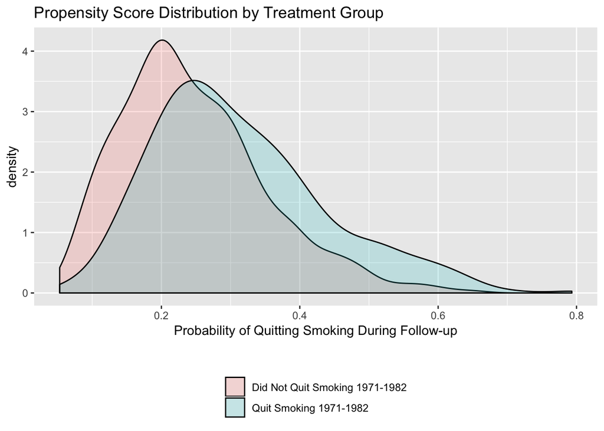

```r
# plot PS distribution by qsmk status (much more helpful)
ggplot(nhefs, aes(x = p.qsmk, fill = qsmklabel)) + geom_density(alpha = 0.2) +
  xlab('Probability of Quitting Smoking During Follow-up') +
  ggtitle('Propensity Score Distribution by Treatment Group') +
  scale_fill_discrete('') +
  theme(legend.position = 'bottom', legend.direction = 'vertical')
```

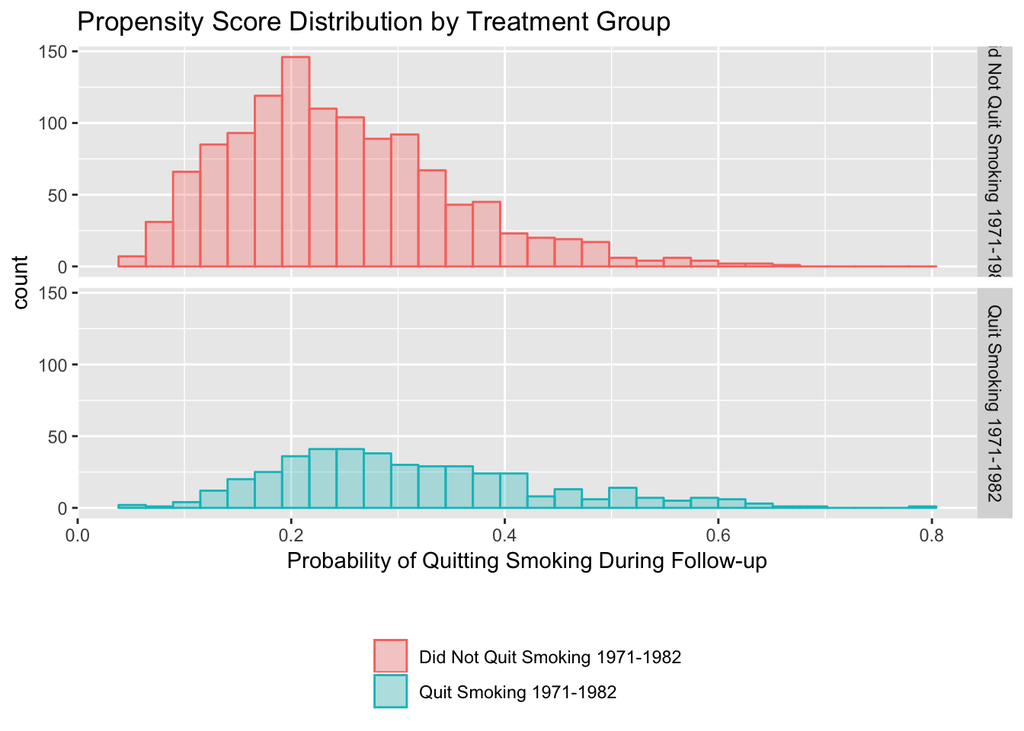

```r
# alternative plot with histograms
ggplot(nhefs, aes(x = p.qsmk, fill = qsmklabel, color = qsmklabel)) +
  geom_histogram(alpha = 0.3, position = 'identity') +
  facet_grid(qsmklabel ~ .) +
  xlab('Probability of Quitting Smoking During Follow-up') +
  ggtitle('Propensity Score Distribution by Treatment Group') +
  scale_fill_discrete('') +
  scale_color_discrete('') +
  theme(legend.position = 'bottom', legend.direction = 'vertical')
```

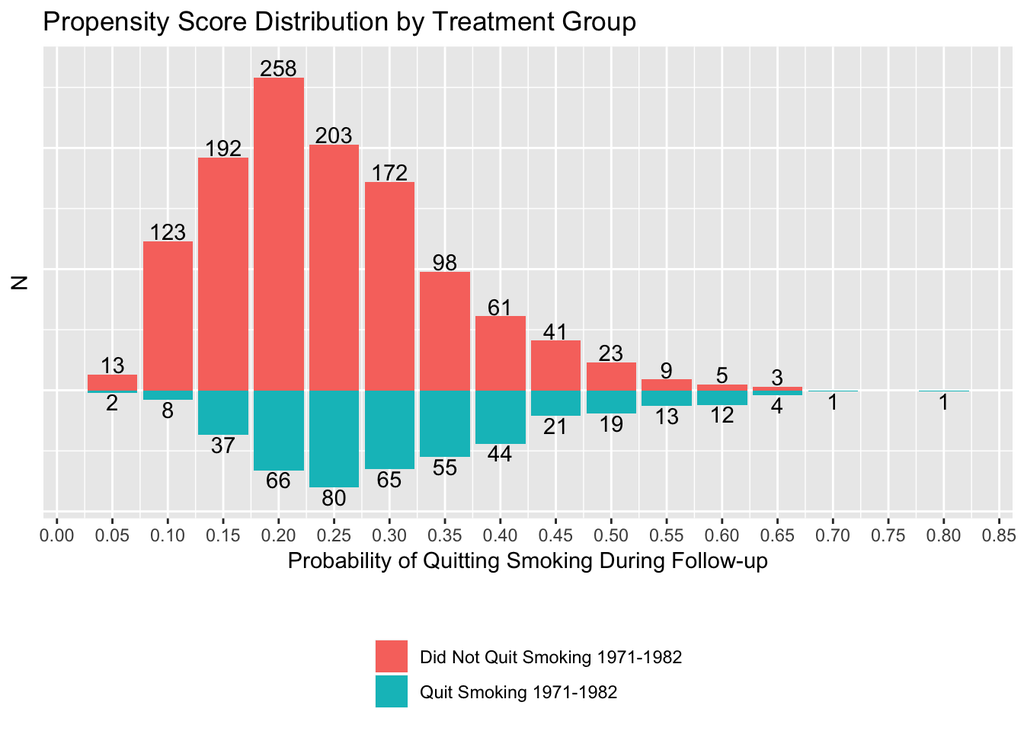

```r
# attempt to reproduce plot from the book
nhefs %>%
  mutate(ps.grp = round(p.qsmk/0.05) * 0.05) %>%
  group_by(qsmk, qsmklabel, ps.grp) %>%
  summarize(n = n()) %>%
  ungroup() %>%
  mutate(n2 = ifelse(qsmk == 0, yes = n, no =  -1*n)) %>%
  ggplot(aes(x = ps.grp, y = n2, fill = qsmklabel)) +
  geom_bar(stat = 'identity', position = 'identity') +
  geom_text(aes(label = n, x = ps.grp, y = n2 + ifelse(qsmk == 0, 8, -8))) +
  xlab('Probability of Quitting Smoking During Follow-up') +
  ylab('N') +
  ggtitle('Propensity Score Distribution by Treatment Group') +
  scale_fill_discrete('') +
  scale_x_continuous(breaks = seq(0, 1, 0.05)) +
  theme(legend.position = 'bottom', legend.direction = 'vertical',
        axis.ticks.y = element_blank(),
        axis.text.y = element_blank())
```

```r
#######################################################################################
#### Program 15.3                                                                  ####
#### Stratification on the propensity score                                        ####
#### Data from NHEFS                                                               ####
#######################################################################################

library(gtools)

# function to create deciles easily
decile <- function(x) {
  return(factor(quantcut(x, seq(0, 1, 0.1), labels = FALSE)))
}

# regression on PS deciles, not allowing for effect modification
model4 <- glm(wt82_71 ~ qsmk + decile(p.qsmk), data = nhefs)
summary(model4)
```

```
##
## Call:
## glm(formula = wt82_71 ~ qsmk + decile(p.qsmk), data = nhefs)
##
## Deviance Residuals:
##    Min      1Q  Median      3Q     Max
## -43.54   -3.93   -0.08    4.23   46.77
##
## Coefficients:
##                  Estimate Std. Error t value Pr(>|t|)
## (Intercept)         3.750      0.609    6.16  9.3e-10 ***
## qsmk                3.500      0.457    7.66  3.3e-14 ***
## decile(p.qsmk)2    -0.739      0.861   -0.86    0.391
## decile(p.qsmk)3    -0.618      0.861   -0.72    0.473
## decile(p.qsmk)4    -0.520      0.858   -0.61    0.544
## decile(p.qsmk)5    -1.488      0.859   -1.73    0.083 .
## decile(p.qsmk)6    -1.623      0.868   -1.87    0.062 .
## decile(p.qsmk)7    -1.985      0.868   -2.29    0.022 *
## decile(p.qsmk)8    -3.445      0.875   -3.94  8.6e-05 ***
## decile(p.qsmk)9    -5.154      0.885   -5.83  6.9e-09 ***
## decile(p.qsmk)10   -4.840      0.883   -5.48  4.9e-08 ***
## ---
## Signif. codes:  0 '***' 0.001 '**' 0.01 '*' 0.05 '.' 0.1 ' ' 1
##
## (Dispersion parameter for gaussian family taken to be 58.4)
##
##     Null deviance: 97176  on 1565  degrees of freedom
## Residual deviance: 90848  on 1555  degrees of freedom
##   (63 observations deleted due to missingness)
## AIC: 10827
##
## Number of Fisher Scoring iterations: 2
```

```r
confint.lm(model4)
```

```
##                  2.5 %  97.5 %
## (Intercept)       2.56  4.9449
## qsmk              2.60  4.3970
## decile(p.qsmk)2  -2.43  0.9498
## decile(p.qsmk)3  -2.31  1.0710
## decile(p.qsmk)4  -2.20  1.1633
## decile(p.qsmk)5  -3.17  0.1966
## decile(p.qsmk)6  -3.32  0.0789
## decile(p.qsmk)7  -3.69 -0.2825
## decile(p.qsmk)8  -5.16 -1.7286
## decile(p.qsmk)9  -6.89 -3.4188
## decile(p.qsmk)10 -6.57 -3.1087
```

```r
# regression on PS deciles, allowing for effect modification
model5 <- glm(wt82_71 ~ qsmk*decile(p.qsmk), data = nhefs)
summary(model5)
```

```
##
## Call:
## glm(formula = wt82_71 ~ qsmk * decile(p.qsmk), data = nhefs)
##
## Deviance Residuals:
##    Min      1Q  Median      3Q     Max
## -43.38   -3.91   -0.07    4.24   46.98
##
## Coefficients:
##                       Estimate Std. Error t value Pr(>|t|)
## (Intercept)             3.9952     0.6303    6.34  3.0e-10 ***
## qsmk                   -0.0147     2.3888   -0.01  0.99511
## decile(p.qsmk)2        -1.0905     0.9164   -1.19  0.23421
## decile(p.qsmk)3        -1.3831     0.9182   -1.51  0.13219
## decile(p.qsmk)4        -0.5205     0.9258   -0.56  0.57404
## decile(p.qsmk)5        -1.8964     0.9402   -2.02  0.04387 *
## decile(p.qsmk)6        -2.1482     0.9537   -2.25  0.02443 *
## decile(p.qsmk)7        -2.4352     0.9491   -2.57  0.01039 *
## decile(p.qsmk)8        -3.7105     0.9738   -3.81  0.00014 ***
## decile(p.qsmk)9        -4.8907     1.0337   -4.73  2.4e-06 ***
## decile(p.qsmk)10       -4.4996     1.0493   -4.29  1.9e-05 ***
## qsmk:decile(p.qsmk)2    4.1634     2.8974    1.44  0.15094
## qsmk:decile(p.qsmk)3    6.5591     2.8836    2.27  0.02307 *
## qsmk:decile(p.qsmk)4    2.3570     2.8079    0.84  0.40137
## qsmk:decile(p.qsmk)5    4.1450     2.7539    1.51  0.13249
## qsmk:decile(p.qsmk)6    4.5580     2.7585    1.65  0.09867 .
## qsmk:decile(p.qsmk)7    4.3306     2.7762    1.56  0.11900
## qsmk:decile(p.qsmk)8    3.5847     2.7436    1.31  0.19154
## qsmk:decile(p.qsmk)9    2.3155     2.7001    0.86  0.39126
## qsmk:decile(p.qsmk)10   2.2549     2.6873    0.84  0.40154
## ---
## Signif. codes:  0 '***' 0.001 '**' 0.01 '*' 0.05 '.' 0.1 ' ' 1
##
## (Dispersion parameter for gaussian family taken to be 58.4)
##
##     Null deviance: 97176  on 1565  degrees of freedom
## Residual deviance: 90289  on 1546  degrees of freedom
##   (63 observations deleted due to missingness)
## AIC: 10835
##
## Number of Fisher Scoring iterations: 2
```

```r
# estimate contrasts to see effect in each decile
# (step 1) set up contrast matrix
K5 <- makeContrastMatrix(model5, 10, paste('Effect of Quitting Smoking in PS Decile', 1:10))
# (step 2) fill in contrast matrix
K5[1:10, 'qsmk'] <- 1
K5[2, 'qsmk:decile(p.qsmk)2'] <- 1
K5[3, 'qsmk:decile(p.qsmk)3'] <- 1
K5[4, 'qsmk:decile(p.qsmk)4'] <- 1
K5[5, 'qsmk:decile(p.qsmk)5'] <- 1
K5[6, 'qsmk:decile(p.qsmk)6'] <- 1
K5[7, 'qsmk:decile(p.qsmk)7'] <- 1
K5[8, 'qsmk:decile(p.qsmk)8'] <- 1
K5[9, 'qsmk:decile(p.qsmk)9'] <- 1
K5[10, 'qsmk:decile(p.qsmk)10'] <- 1

# step(3) view the contrast matrix
K5
```

```
##                                            (Intercept) qsmk
## Effect of Quitting Smoking in PS Decile 1            0    1
## Effect of Quitting Smoking in PS Decile 2            0    1
## Effect of Quitting Smoking in PS Decile 3            0    1
## Effect of Quitting Smoking in PS Decile 4            0    1
## Effect of Quitting Smoking in PS Decile 5            0    1
## Effect of Quitting Smoking in PS Decile 6            0    1
## Effect of Quitting Smoking in PS Decile 7            0    1
## Effect of Quitting Smoking in PS Decile 8            0    1
## Effect of Quitting Smoking in PS Decile 9            0    1
## Effect of Quitting Smoking in PS Decile 10           0    1
##                                            decile(p.qsmk)2 decile(p.qsmk)3
## Effect of Quitting Smoking in PS Decile 1                0               0
## Effect of Quitting Smoking in PS Decile 2                0               0
## Effect of Quitting Smoking in PS Decile 3                0               0
## Effect of Quitting Smoking in PS Decile 4                0               0
## Effect of Quitting Smoking in PS Decile 5                0               0
## Effect of Quitting Smoking in PS Decile 6                0               0
## Effect of Quitting Smoking in PS Decile 7                0               0
## Effect of Quitting Smoking in PS Decile 8                0               0
## Effect of Quitting Smoking in PS Decile 9                0               0
## Effect of Quitting Smoking in PS Decile 10               0               0
##                                            decile(p.qsmk)4 decile(p.qsmk)5
## Effect of Quitting Smoking in PS Decile 1                0               0
## Effect of Quitting Smoking in PS Decile 2                0               0
## Effect of Quitting Smoking in PS Decile 3                0               0
## Effect of Quitting Smoking in PS Decile 4                0               0
## Effect of Quitting Smoking in PS Decile 5                0               0
## Effect of Quitting Smoking in PS Decile 6                0               0
## Effect of Quitting Smoking in PS Decile 7                0               0
## Effect of Quitting Smoking in PS Decile 8                0               0
## Effect of Quitting Smoking in PS Decile 9                0               0
## Effect of Quitting Smoking in PS Decile 10               0               0
##                                            decile(p.qsmk)6 decile(p.qsmk)7
## Effect of Quitting Smoking in PS Decile 1                0               0
## Effect of Quitting Smoking in PS Decile 2                0               0
## Effect of Quitting Smoking in PS Decile 3                0               0
## Effect of Quitting Smoking in PS Decile 4                0               0
## Effect of Quitting Smoking in PS Decile 5                0               0
## Effect of Quitting Smoking in PS Decile 6                0               0
```

[output cut: 110 more lines]

```
## Effect of Quitting Smoking in PS Decile 7                     0
## Effect of Quitting Smoking in PS Decile 8                     0
## Effect of Quitting Smoking in PS Decile 9                     1
## Effect of Quitting Smoking in PS Decile 10                    0
##                                            qsmk:decile(p.qsmk)10
## Effect of Quitting Smoking in PS Decile 1                      0
## Effect of Quitting Smoking in PS Decile 2                      0
## Effect of Quitting Smoking in PS Decile 3                      0
## Effect of Quitting Smoking in PS Decile 4                      0
## Effect of Quitting Smoking in PS Decile 5                      0
## Effect of Quitting Smoking in PS Decile 6                      0
## Effect of Quitting Smoking in PS Decile 7                      0
## Effect of Quitting Smoking in PS Decile 8                      0
## Effect of Quitting Smoking in PS Decile 9                      0
## Effect of Quitting Smoking in PS Decile 10                     1
```

```r
# estimate contrasts and view tests and CIs
estimates5 <- glht(model5, K5)
summary(estimates5)
```

```
##
##   Simultaneous Tests for General Linear Hypotheses
##
## Fit: glm(formula = wt82_71 ~ qsmk * decile(p.qsmk), data = nhefs)
##
## Linear Hypotheses:
##                                                 Estimate Std. Error
## Effect of Quitting Smoking in PS Decile 1 == 0   -0.0147     2.3888
## Effect of Quitting Smoking in PS Decile 2 == 0    4.1487     1.6397
## Effect of Quitting Smoking in PS Decile 3 == 0    6.5445     1.6152
## Effect of Quitting Smoking in PS Decile 4 == 0    2.3423     1.4757
## Effect of Quitting Smoking in PS Decile 5 == 0    4.1304     1.3701
## Effect of Quitting Smoking in PS Decile 6 == 0    4.5433     1.3794
## Effect of Quitting Smoking in PS Decile 7 == 0    4.3159     1.4145
## Effect of Quitting Smoking in PS Decile 8 == 0    3.5701     1.3493
## Effect of Quitting Smoking in PS Decile 9 == 0    2.3008     1.2585
## Effect of Quitting Smoking in PS Decile 10 == 0   2.2402     1.2308
##                                                 z value Pr(>|z|)
## Effect of Quitting Smoking in PS Decile 1 == 0    -0.01  1.00000
## Effect of Quitting Smoking in PS Decile 2 == 0     2.53  0.10833
## Effect of Quitting Smoking in PS Decile 3 == 0     4.05  0.00051 ***
## Effect of Quitting Smoking in PS Decile 4 == 0     1.59  0.69665
## Effect of Quitting Smoking in PS Decile 5 == 0     3.01  0.02543 *
## Effect of Quitting Smoking in PS Decile 6 == 0     3.29  0.00985 **
## Effect of Quitting Smoking in PS Decile 7 == 0     3.05  0.02257 *
## Effect of Quitting Smoking in PS Decile 8 == 0     2.65  0.07855 .
## Effect of Quitting Smoking in PS Decile 9 == 0     1.83  0.50291
## Effect of Quitting Smoking in PS Decile 10 == 0    1.82  0.50936
## ---
## Signif. codes:  0 '***' 0.001 '**' 0.01 '*' 0.05 '.' 0.1 ' ' 1
## (Adjusted p values reported -- single-step method)
```

```r
confint(estimates5)
```

```
##
##   Simultaneous Confidence Intervals
##
## Fit: glm(formula = wt82_71 ~ qsmk * decile(p.qsmk), data = nhefs)
##
## Quantile = 2.8
## 95% family-wise confidence level
##
##
## Linear Hypotheses:
##                                                 Estimate lwr     upr
## Effect of Quitting Smoking in PS Decile 1 == 0  -0.0147  -6.7025  6.6732
## Effect of Quitting Smoking in PS Decile 2 == 0   4.1487  -0.4418  8.7393
## Effect of Quitting Smoking in PS Decile 3 == 0   6.5445   2.0225 11.0664
## Effect of Quitting Smoking in PS Decile 4 == 0   2.3423  -1.7890  6.4736
## Effect of Quitting Smoking in PS Decile 5 == 0   4.1304   0.2946  7.9661
## Effect of Quitting Smoking in PS Decile 6 == 0   4.5433   0.6815  8.4052
## Effect of Quitting Smoking in PS Decile 7 == 0   4.3159   0.3557  8.2761
## Effect of Quitting Smoking in PS Decile 8 == 0   3.5701  -0.2074  7.3476
## Effect of Quitting Smoking in PS Decile 9 == 0   2.3008  -1.2225  5.8242
## Effect of Quitting Smoking in PS Decile 10 == 0  2.2402  -1.2054  5.6859
```

```r
#######################################################################################
#### Program 15.4                                                                  ####
#### Standardization using the propensity score                                    ####
#### Data from NHEFS                                                               ####
#######################################################################################

# regression on the propensity score (linear term)
model6 <- glm(wt82_71 ~ qsmk + p.qsmk, data = nhefs)
summary(model6)
```

```
##
## Call:
## glm(formula = wt82_71 ~ qsmk + p.qsmk, data = nhefs)
##
## Deviance Residuals:
##    Min      1Q  Median      3Q     Max
## -43.31   -4.01   -0.07    4.24   47.16
##
## Coefficients:
##             Estimate Std. Error t value Pr(>|t|)
## (Intercept)    5.594      0.483   11.58  < 2e-16 ***
## qsmk           3.551      0.457    7.76  1.5e-14 ***
## p.qsmk       -14.822      1.758   -8.43  < 2e-16 ***
## ---
## Signif. codes:  0 '***' 0.001 '**' 0.01 '*' 0.05 '.' 0.1 ' ' 1
##
## (Dispersion parameter for gaussian family taken to be 58.3)
##
##     Null deviance: 97176  on 1565  degrees of freedom
## Residual deviance: 91099  on 1563  degrees of freedom
##   (63 observations deleted due to missingness)
## AIC: 10815
##
## Number of Fisher Scoring iterations: 2
```

```r
# standarization on the propensity score
# (step 1) create two new datasets, one with all treated and one with all untreated
treated <- nhefs
  treated$qsmk <- 1

untreated <- nhefs
  untreated$qsmk <- 0

# (step 2) predict values for everyone in each new dataset based on above model
treated$pred.y <- predict(model6, treated)
untreated$pred.y <- predict(model6, untreated)

# (step 3) compare mean weight loss had all been treated vs. that had all been untreated
mean1 <- mean(treated$pred.y, na.rm = TRUE)
mean0 <- mean(untreated$pred.y, na.rm = TRUE)
mean1
```

```
## [1] 5.25
```

```r
mean0
```

```
## [1] 1.7
```

```r
mean1 - mean0
```

```
## [1] 3.55
```

```r
# (step 4) bootstrap a confidence interval
# number of bootstraps
nboot <- 100
# set up a matrix to store results
boots <- data.frame(i = 1:nboot,
                    mean1 = NA,
                    mean0 = NA,
                    difference = NA)
# loop to perform the bootstrapping
nhefs <- subset(nhefs, !is.na(p.qsmk) & !is.na(wt82_71))
for(i in 1:nboot) {
  # sample with replacement
  sampl <- nhefs[sample(1:nrow(nhefs), nrow(nhefs), replace = TRUE), ]

  # fit the model in the bootstrap sample
  bootmod <- glm(wt82_71 ~ qsmk + p.qsmk, data = sampl)

  # create new datasets
  sampl.treated <- sampl %>%
    mutate(qsmk = 1)

  sampl.untreated <- sampl %>%
    mutate(qsmk = 0)

  # predict values
  sampl.treated$pred.y <- predict(bootmod, sampl.treated)
  sampl.untreated$pred.y <- predict(bootmod, sampl.untreated)

  # output results
  boots[i, 'mean1'] <- mean(sampl.treated$pred.y, na.rm = TRUE)
  boots[i, 'mean0'] <- mean(sampl.untreated$pred.y, na.rm = TRUE)
  boots[i, 'difference'] <- boots[i, 'mean1'] - boots[i, 'mean0']

  # once loop is done, print the results
  if(i == nboot) {
    cat('95% CI for the causal mean difference\n')
    cat(mean(boots$difference) - 1.96*sd(boots$difference),
        ',',
        mean(boots$difference) + 1.96*sd(boots$difference))
  }
}
```

```
## 95% CI for the causal mean difference
## 2.61 , 4.5
```

```r
# a more flexible and elegant way to do this is to write a function
# to perform the model fitting, prediction, bootstrapping, and reporting all at once
# view the code contained in the file mstandardize.R to learn more

# load the code for the mstandardize() function
# (you may need to change the filepath)
source('chapter15_mstandardize.R')

# performt the standardization
mstandardize(formula = wt82_71 ~ qsmk + decile(p.qsmk),
             family = 'gaussian',
             trt = 'qsmk',
             nboot = 100,
             data = nhefs)
```

```
##
## Results of Model-Based Standardization
## ---------------------------------------------------------------------------
##   Outcome: wt82_71
##   Model Type: gaussian
##   Model RHS: qsmk + decile(p.qsmk)
##   No. of bootstrap resamples: 100
##   Showing 95 % confidence intervals
```

```
##                                     Estimate  LCL  UCL
## Standardized Mean in the Treated        5.24 4.31 6.17
## Standardized Mean in the Untreated      1.74 1.32 2.15
## Standardized Mean Difference in Pop     3.50 2.50 4.51
## Standardized Mean Ratio in Pop          3.02 2.16 3.88
```

### 0.1.6 Chapter 16 INSTRUMENTAL VARIABLE ESTIMATION

```r
# Author contact: Justin Bohn (jmb619@mail.harvard.edu)
# Last revision : 2015-08-04

#######################################################################################
#### Program 16.1                                                                  ####
#### Estimating the average causal using the standard IV estimator                 ####
#### via the calculation of sample averages                                        ####
#### Data from NHEFS                                                               ####
#######################################################################################

# load external packages (install them if necessary)
library(dplyr)      # easy, readable data manipulation
library(multcomp)   # estimation of linear contrasts from GLMs
library(ggplot2)    # graphics
library(gtools)     # easy decile creation
library(sem)        # two-stage least squares
library(geepack)    # generalized estimating equations

# clean up workspace
rm(list = ls())

# establish working directory (this will be different on your system)
#setwd('~/Downloads/R_part2/')

# read in NHEFS data and preprocess
# note: this is the dplyr method, but can also be easily accomplished
#       in base R with within(). However, dplyr is faster and more readable.
nhefs <- read.csv('nhefs.csv') %>%
  mutate(
    # define censoring variable cens
    cens = ifelse(is.na(wt82_71), yes = 1, no = 0),
    # categorize the school variable
    education = cut(school, breaks = c(0, 8, 11, 12, 15, 20),
                    include.lowest = TRUE,
                    labels = c('8th Grage or Less',
                               'HS Dropout',
                               'HS',
                               'College Dropout',
                               'College or More')),
    # establish active as a factor variable
    active = factor(active),
    # establish exercise as a factor variable
    exercise = factor(exercise),
    # create a treatment label variable
    qsmklabel = ifelse(qsmk == 1,
                       yes = 'Quit Smoking 1971-1982',
                       no = 'Did Not Quit Smoking 1971-1982'),
    # define the (proposed) instrument
    highprice = ifelse(price82 >= 1.5, yes = 1, no = 0),
    # counterfactual weight loss under no treatment, assuming an effect of 2.396
    Hpsi = wt82_71 - (qsmk * 2.396)
  ) %>%
  # provisionally ignore those with missing values on some variables
  filter(!is.na(education),
         !is.na(wt82),
         !is.na(price82))

# check categorizations to be sure
xtabs(~ school + education, data = nhefs)
```

```
##       education
## school 8th Grage or Less HS Dropout  HS College Dropout College or More
##     0                 10          0   0               0               0
##     1                  6          0   0               0               0
##     2                  7          0   0               0               0
##     3                  7          0   0               0               0
##     4                 11          0   0               0               0
##     5                 12          0   0               0               0
##     6                 28          0   0               0               0
##     7                 48          0   0               0               0
##     8                135          0   0               0               0
##     9                  0         79   0               0               0
##     10                 0        140   0               0               0
##     11                 0        103   0               0               0
##     12                 0          0 608               0               0
##     13                 0          0   0              82               0
##     15                 0          0   0              32               0
##     16                 0          0   0               0              92
##     17                 0          0   0               0              76
```

```r
# standard "Wald" estimator
# i.e.  (E[Y|Z=1] - E[Y|Z=0]) / (Pr[A=1|Z=1] - Pr[A=1|Z=0])

# first try it "manually"
a <- mean(nhefs$wt82_71[nhefs$highprice == 1], na.rm = TRUE) # E[Y|Z=1]
  a # print
```

```
## [1] 2.69
```

```r
b <- mean(nhefs$wt82_71[nhefs$highprice == 0], na.rm = TRUE) # E[Y|Z=0]
  b # print
```

```
## [1] 2.54
```

```r
c <- mean(nhefs$qsmk[nhefs$highprice == 1], na.rm = TRUE)    # Pr(A=1|Z=1)
  c # print
```

```
## [1] 0.258
```

```r
d <- mean(nhefs$qsmk[nhefs$highprice == 0], na.rm = TRUE)    # Pr(A=1|Z=0)
  d # print
```

```
## [1] 0.195
```

```r
(a-b)/(c-d)                                                  # the IV estimate
```

```
## [1] 2.4
```

```r
# then wrap it in a function
wald <- function(outcome, treatment, iv, data) {
  # the numerator, i.e., E[Y|Z=1] - E[Y|Z=0]
  num <- coef(lm(data[,outcome] ~ data[,iv]))[2]
  # the denominator, i.e., Pr[A=1|Z=1] - Pr[A=1|Z=0]
  denom <- coef(lm(data[,treatment] ~ data[,iv]))[2]
  return(as.numeric(num/denom))
}

wald('wt82_71', 'qsmk', 'highprice', nhefs)
```

```
## [1] 2.4
```

```r
#######################################################################################
#### Program 16.2                                                                  ####
#### Estimating the average causal using the standard IV estimator                 ####
#### via two-stage least squares regression                                        ####
#### Data from NHEFS                                                               ####
#######################################################################################

library(sem)

model1 <- tsls(wt82_71 ~ qsmk, ~ highprice, data = nhefs)
summary(model1)
```

```
##
##  2SLS Estimates
##
## Model Formula: wt82_71 ~ qsmk
##
## Instruments: ~highprice
##
## Residuals:
##    Min. 1st Qu.  Median    Mean 3rd Qu.    Max.
##   -43.3    -4.0     0.0     0.0     4.2    46.5
##
##             Estimate Std. Error t value Pr(>|t|)
## (Intercept)     2.07       5.09    0.41     0.68
## qsmk            2.40      19.84    0.12     0.90
##
## Residual standard error: 7.856 on 1474 degrees of freedom
```

```r
confint(model1)  # note the wide confidence intervals
```

```
##             2.5 % 97.5 %
## (Intercept)  -7.9   12.0
## qsmk        -36.5   41.3
```

```r
#######################################################################################
#### Program 16.3                                                                  ####
#### Estimating the average causal using the standard IV estimator                 ####
#### via additive marginal structural models                                       ####
#### Data from NHEFS                                                               ####
#######################################################################################

# note: refer to programs from chapter 14 for a consideration of multiple
#       values for psi
summary(geeglm(highprice ~ Hpsi,
               data = subset(nhefs, !is.na(highprice) & !is.na(Hpsi)),
               id = seqn,
               corstr = 'independence',
               family = 'binomial'))
```

```
##
## Call:
## geeglm(formula = highprice ~ Hpsi, family = "binomial", data = subset(nhefs,
##     !is.na(highprice) & !is.na(Hpsi)), id = seqn, corstr = "independence")
##
##  Coefficients:
##             Estimate  Std.err Wald Pr(>|W|)
## (Intercept) 3.56e+00 1.65e-01  463   <2e-16 ***
## Hpsi        2.75e-07 2.27e-02    0        1
## ---
## Signif. codes:  0 '***' 0.001 '**' 0.01 '*' 0.05 '.' 0.1 ' ' 1
##
## Estimated Scale Parameters:
##             Estimate Std.err
## (Intercept)        1   0.761
##
## Correlation: Structure = independenceNumber of clusters:   1476   Maximum cluster size: 1
```

```r
#######################################################################################
#### Program 16.4                                                                  ####
#### Estimating the average causal using the standard IV estimator                 ####
#### with altnerative proposed instruments                                         ####
#### Data from NHEFS                                                               ####
#######################################################################################

# note what happens to estimates....
summary(tsls(wt82_71 ~ qsmk, ~ ifelse(price82 >= 1.6, 1, 0), data = nhefs))
```

```
##
##  2SLS Estimates
##
## Model Formula: wt82_71 ~ qsmk
##
## Instruments: ~ifelse(price82 >= 1.6, 1, 0)
##
## Residuals:
##    Min. 1st Qu.  Median    Mean 3rd Qu.    Max.
##   -55.6   -13.5     7.6     0.0    12.5    56.4
##
##             Estimate Std. Error t value Pr(>|t|)
## (Intercept)    -7.89      42.25   -0.19     0.85
## qsmk           41.28     164.95    0.25     0.80
##
## Residual standard error: 18.605 on 1474 degrees of freedom
```

```r
summary(tsls(wt82_71 ~ qsmk, ~ ifelse(price82 >= 1.7, 1, 0), data = nhefs))
```

```
##
##  2SLS Estimates
##
## Model Formula: wt82_71 ~ qsmk
##
## Instruments: ~ifelse(price82 >= 1.7, 1, 0)
##
## Residuals:
##    Min. 1st Qu.  Median    Mean 3rd Qu.    Max.
##   -54.4   -13.4    -8.4     0.0    18.1    75.3
##
##             Estimate Std. Error t value Pr(>|t|)
## (Intercept)     13.2       48.1    0.27     0.78
## qsmk           -40.9      187.7   -0.22     0.83
##
## Residual standard error: 20.591 on 1474 degrees of freedom
```

```r
summary(tsls(wt82_71 ~ qsmk, ~ ifelse(price82 >= 1.8, 1, 0), data = nhefs))
```

```
##
##  2SLS Estimates
##
## Model Formula: wt82_71 ~ qsmk
##
## Instruments: ~ifelse(price82 >= 1.8, 1, 0)
##
## Residuals:
##    Min. 1st Qu.  Median    Mean 3rd Qu.    Max.
##   -49.4    -8.3    -3.4     0.0     7.3    60.5
##
##             Estimate Std. Error t value Pr(>|t|)
## (Intercept)     8.09       7.29    1.11     0.27
## qsmk          -21.10      28.43   -0.74     0.46
##
## Residual standard error: 13.019 on 1474 degrees of freedom
```

```r
summary(tsls(wt82_71 ~ qsmk, ~ ifelse(price82 >= 1.9, 1, 0), data = nhefs))
```

```
##
##  2SLS Estimates
##
## Model Formula: wt82_71 ~ qsmk
##
## Instruments: ~ifelse(price82 >= 1.9, 1, 0)
##
## Residuals:
##    Min. 1st Qu.  Median    Mean 3rd Qu.    Max.
##   -47.2    -6.3    -1.4     0.0     5.5    54.4
##
##             Estimate Std. Error t value Pr(>|t|)
## (Intercept)     5.96       6.07    0.98     0.33
## qsmk          -12.81      23.67   -0.54     0.59
##
## Residual standard error: 10.364 on 1474 degrees of freedom
```

```r
#######################################################################################
#### Program 16.5                                                                  ####
#### Estimating the average causal using the standard IV estimator                 ####
#### Conditional on baseline covariates                                            ####
#### Data from NHEFS                                                               ####
#######################################################################################

summary(tsls(wt82_71 ~ qsmk + sex + race + age + smokeintensity + smokeyrs +
                      exercise + active + wt71,
             ~ highprice + sex + race + age + smokeintensity + smokeyrs + exercise +
               active + wt71, data = nhefs))
```

```
##
##  2SLS Estimates
##
## Model Formula: wt82_71 ~ qsmk + sex + race + age + smokeintensity + smokeyrs +
##     exercise + active + wt71
##
## Instruments: ~highprice + sex + race + age + smokeintensity + smokeyrs + exercise +
##     active + wt71
##
## Residuals:
##    Min. 1st Qu.  Median    Mean 3rd Qu.    Max.
##   -42.2    -4.3    -0.6     0.0     3.9    46.7
##
##                Estimate Std. Error t value Pr(>|t|)
## (Intercept)    17.28033    2.33540    7.40  2.3e-13 ***
## qsmk           -1.04229   29.98737   -0.03    0.972
## sex            -1.64439    2.63083   -0.63    0.532
## race           -0.18325    4.65039   -0.04    0.969
## age            -0.16364    0.24055   -0.68    0.496
## smokeintensity  0.00577    0.14550    0.04    0.968
## smokeyrs        0.02584    0.16142    0.16    0.873
## exercise1       0.49875    2.17124    0.23    0.818
## exercise2       0.58183    2.18315    0.27    0.790
## active1        -1.17015    0.60747   -1.93    0.054 .
## active2        -0.51228    1.30845   -0.39    0.695
## wt71           -0.09795    0.03627   -2.70    0.007 **
## ---
## Signif. codes:  0 '***' 0.001 '**' 0.01 '*' 0.05 '.' 0.1 ' ' 1
##
## Residual standard error: 7.716 on 1464 degrees of freedom
```

## 0.2 Causal inference (Stephen Pettigrew)

http://www.stephenpettigrew.com/teaching/gov2002/

### 0.2.1 Randomization Inference and Propensity Score Subclassification

```r
#install.packages("/Users/deng/Downloads/ri_0.9.tar.gz", repos = NULL, type="source")
require(ri)
#######
## First generate some data
set.seed(25)
data <- data.frame(y.obs = rnorm(15,mean = 5, sd = 2))

# we'll assume a completely randomized experiment where 8 units are assigned treatment
data$treat <- 0
data$treat[sample(1:nrow(data), 8)] <- 1

#######
# use diff of means estimator as the test statistic
test.stat <- abs(mean(data$y.obs[data$treat == 1]) - mean(data$y.obs[data$treat == 0]))



# get all possible permutations of the treatment vector
# 15 choose 8
possible.d.vectors <- genperms(data$treat)
dim(possible.d.vectors)
```

```
## [1]   15 6435
```

```r
# now calculate the test stat for each possible randomization
all.test.stats <- c()
for(ii in 1:ncol(possible.d.vectors)){
  current.d.vector <- possible.d.vectors[,ii]
  all.test.stats[ii] <- abs(mean(data$y.obs[current.d.vector == 1]) -
                              mean(data$y.obs[current.d.vector == 0]))
}

# or without using a loop:
#apply(possible.d.vectors, 2,function(x) abs(mean(data$y.obs[x == 1]) - mean(data$y.obs[x == 0])))


# what's the fisher exact p-value?
mean(test.stat <= all.test.stats)
```

```
## [1] 0.363
```

```r
# compared to regular diff of means estimator
t.test(data$y.obs[data$treat == 1],
       data$y.obs[data$treat == 0])$p.value
```

```
## [1] 0.378
```

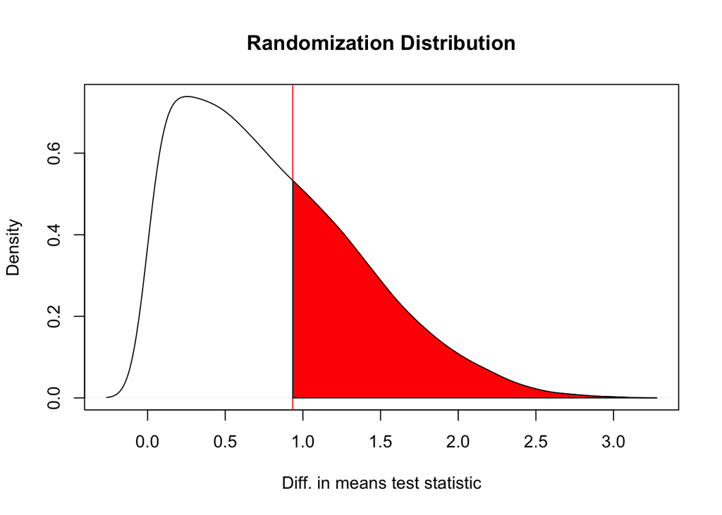

```r
# what's this look like graphically?
dens <- density(all.test.stats)
plot(dens,
     main = "Randomization Distribution",
     xlab = "Diff. in means test statistic")
abline(v = test.stat,
       col = "red")
x1 <- min(which(dens$x >= test.stat))
x2 <- max(which(dens$x <  100))
with(dens, polygon(x=c(x[c(x1,x1:x2,x2)]), y= c(0, y[x1:x2], 0), col="red"))
```

```r
###################################################################

# pulled from Maya Sen and Adam Glynn's 2015 AJPS paper
# http://dx.doi.org/10.7910/DVN/26544

load("judges.RData")

# treatment is whether the judge as at least 1 daughter
judge.means$girls <- judge.means$girls > 0

# result reported in the paper (table 4, model 3)
model <- lm(lib_vote_share ~ girls + as.factor(child) + republican +
              age + I(religion == 4) + woman + I(race == 2) + I(race ==3),
            data = judge.means, weights = judge.means$no_cases)
summary(model)
```

```
##
## Call:
## lm(formula = lib_vote_share ~ girls + as.factor(child) + republican +
##     age + I(religion == 4) + woman + I(race == 2) + I(race ==
##     3), data = judge.means, weights = judge.means$no_cases)
##
## Weighted Residuals:
##     Min      1Q  Median      3Q     Max
## -1.3087 -0.3878  0.0348  0.4593  1.4098
##
## Coefficients:
##                      Estimate Std. Error t value Pr(>|t|)
## (Intercept)           0.30147    0.12592    2.39    0.018 *
## girlsTRUE             0.09243    0.04088    2.26    0.025 *
## as.factor(child)1    -0.07451    0.06585   -1.13    0.260
## as.factor(child)2    -0.11258    0.05706   -1.97    0.050 .
## as.factor(child)3    -0.10449    0.05957   -1.75    0.082 .
## as.factor(child)4    -0.13573    0.07003   -1.94    0.055 .
## as.factor(child)5    -0.08574    0.07711   -1.11    0.268
## as.factor(child)6     0.04284    0.12232    0.35    0.727
## as.factor(child)7    -0.10603    0.14823   -0.72    0.476
## as.factor(child)8    -0.24662    0.25451   -0.97    0.334
## as.factor(child)9    -0.14382    0.16520   -0.87    0.385
## republican           -0.14853    0.03688   -4.03  9.1e-05 ***
## age                   0.00510    0.00248    2.06    0.041 *
## I(religion == 4)TRUE -0.08200    0.03258   -2.52    0.013 *
## woman                -0.08068    0.04601   -1.75    0.082 .
## I(race == 2)TRUE     -0.06104    0.07268   -0.84    0.402
## I(race == 3)TRUE     -0.11027    0.10776   -1.02    0.308
## ---
## Signif. codes:  0 '***' 0.001 '**' 0.01 '*' 0.05 '.' 0.1 ' ' 1
##
## Residual standard error: 0.605 on 144 degrees of freedom
##   (63 observations deleted due to missingness)
## Multiple R-squared:  0.206,  Adjusted R-squared:  0.118
## F-statistic: 2.34 on 16 and 144 DF,  p-value: 0.00422
```

```r
# let's use the t-value for the "girls" coefficient as our test statistic
t <- coef(summary(model))["girlsTRUE","t value"]


# How many possible treatment vectors are there?
choose(nrow(judge.means), sum(judge.means$girls)) # ~100 septendecillion (i.e. a lot)
```

```
## [1] 1.45e+56
```

```r
set.seed(100)
# genperms() produces either an exact or approximate permutation matrix
possible.d.vectors <- genperms(judge.means$girls,
                               maxiter = 3000) # only 3k because the regressions take too long otherwise
```

```
## Too many permutations to use exact method.
## Defaulting to approximate method.
## Increase maxiter to at least 1.44635255293562e+56 to perform exact estimation.
```

```r
dim(possible.d.vectors)
```

```
## [1]  224 3000
```

```r
all.test.stats <- c()
for(ii in 1:ncol(possible.d.vectors)){
  # create a new dataset from the original
  h <- judge.means

  # in that dataset, replace the observed treatment vector
  # with one of the possible vectors if the randomization
  # had been different
  h$girls <- possible.d.vectors[,ii]

  # use the new dataset to run the same regression
  m <- lm(lib_vote_share ~ girls + as.factor(child) + republican +
            age + I(religion == 4) + woman + I(race == 2) + I(race ==3),
          data = h, weights = h$no_cases)

  # store the t-value for "girls" from that regression
  all.test.stats[ii] <- coef(summary(m))["girls","t value"]
}

# (estimated) one-sided Fisher's exact p-value
mean(t <= all.test.stats)
```

```
## [1] 0.0203
```

```r
# (estimated) two-sided Fisher's exact p-value
mean(abs(t) <= abs(all.test.stats))
```

```
## [1] 0.04
```

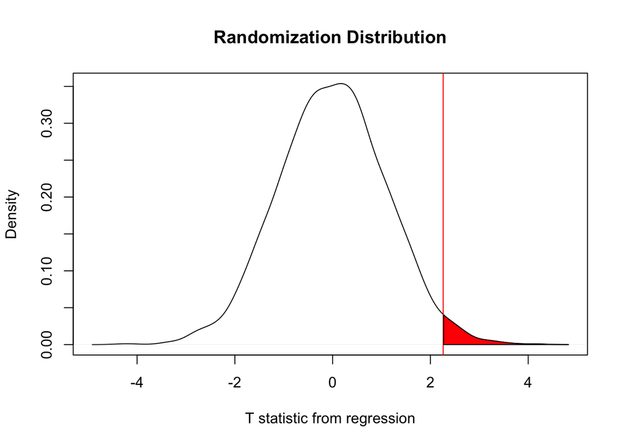

```r
dens <- density(all.test.stats)
plot(dens,
     main = "Randomization Distribution",
     xlab = "T statistic from regression")
abline(v = t,
       col = "red")
x1 <- min(which(dens$x >= t))
x2 <- max(which(dens$x <  100))
with(dens, polygon(x=c(x[c(x1,x1:x2,x2)]), y= c(0, y[x1:x2], 0), col="red"))
```

```r
########################################
## Propensity scores

## Create some data
set.seed(1776)

data <- data.frame(x1 = rnorm(1000),
                   x2 = rpois(1000, lambda = 1.5),
                   x3 = rbinom(1000, size = 1, prob = .25))
linear.pred <- data$x1 - .5 * data$x2 + data$x3 + data$x1*data$x3 + rnorm(1000) # true p-score model
data$d <- rbinom(1000, size = 1, prob = boot::inv.logit(linear.pred))
data$y <- rnorm(1000,
                mean = 3*data$x1 + .8*data$x2 - data$x3 +
                  rnorm(1000, mean = 2.3) * data$d, # varying treatment effects, ATE: 2.3
                sd = 3)

### Get the naive diff of means
dm <- t.test(data$y[data$d == 1],
             data$y[data$d == 0])
dm$estimate
```

```
## mean of x mean of y
##     4.527     0.111
```

```r
diff(rev(dm$estimate))
```

```
## mean of x
##      4.42
```

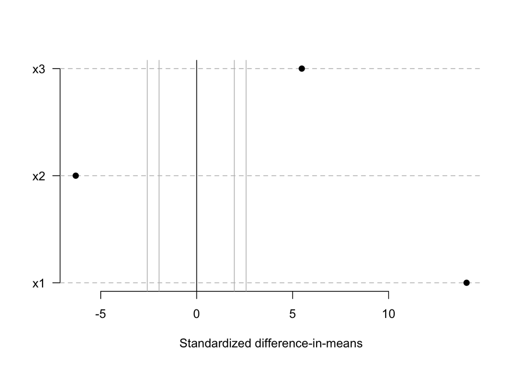

```r
# [1] 4.301641 # naive diff of means


#######################
### check balance

se <- function(x){
  sqrt(var(x, na.rm = T) / sum(!is.na(x)))
}

check.balance <- function(data, covars){
  ## get means and SEs of variables by treatment condition
  balance <- data.frame(mean.t = colMeans(data[data$d == 1, covars], na.rm = T),
                        mean.c = colMeans(data[data$d == 0, covars], na.rm = T),
                        se.t = apply(data[data$d == 1, covars], 2, se),
                        se.c = apply(data[data$d == 0, covars], 2, se))

  balance$mean.diff <- balance$mean.t - balance$mean.c
  balance$se.diff <- sqrt(balance$se.t^2 + balance$se.c^2)

  balance$love <- balance$mean.diff / balance$se.diff # standardized differences

  balance
}

balance <- check.balance(data, covars = c("x1","x2","x3"))



############
## Love plot
love.plot <- function(balance){
  plot(x = NULL, y = NULL,
       xlim = range(balance$love),
       ylim = c(1,nrow(balance)),
       xlab = "Standardized difference-in-means",
       ylab = "",
       yaxt = "n", bty = "n")
  axis(side = 2, labels = rownames(balance),
       at = 1:nrow(balance), las = 2)
  abline(h = 1:nrow(balance), lty = 2, col = "grey")
  abline(v = 0)
  abline(v = c(qnorm(c(.025, .975))),
         col = "gray") #95% confidence bounds
  abline(v = c(qnorm(c(.005, .995))),
         col = "gray") #99% confidence bounds
  points(x = balance$love, y = 1:nrow(balance), pch = 19)
}

love.plot(balance)
```

```r
#############
## Use a p-score model to try to get better balance

model <- glm(d ~ x1 + x2 + x3,
             data = data,
             family = "binomial")
fitted <- model$fitted.values ## could also use the linear predictors here instead


## use subclassification to divide the observations up into
## 4 equally sized strata, based on their p-scores

breakpoints <- quantile(fitted, probs = seq(0,1,length=5))
strata <- cut(fitted, breaks = breakpoints)

table(strata, data$d)
```

```
##
## strata              0   1
##   (0.00317,0.195] 220  29
##   (0.195,0.379]   183  67
##   (0.379,0.575]   125 125
##   (0.575,0.969]    70 180
```

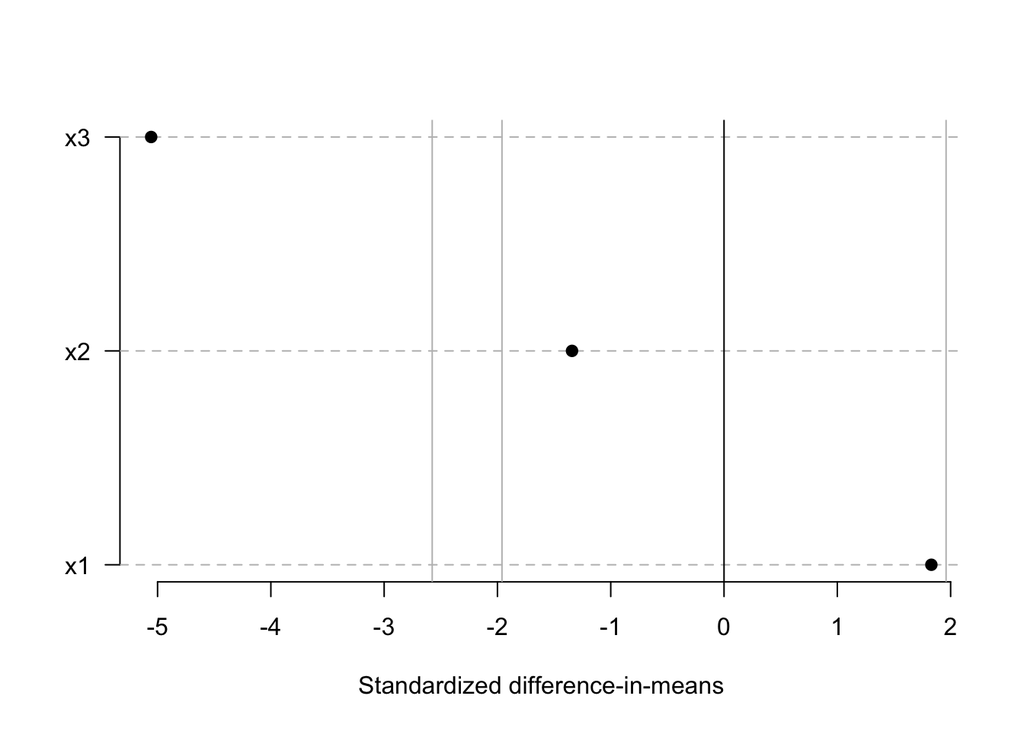

```r
## recheck balance inside of each of these strata

pscore.balance <- check.balance(data[strata == levels(strata)[1],],
                                covars = c("x1","x2","x3"))
love.plot(pscore.balance) # still sucks for x3
```

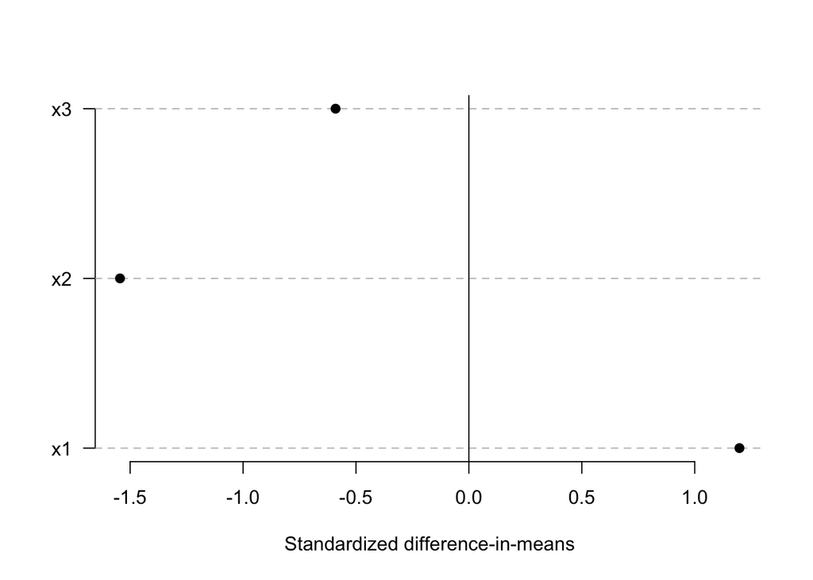

```r
## Let's try again with the 'true' p-score model
model <- glm(d ~ x1 + x2 + x3 + I(x1*x3),
             data = data,
             family = "binomial")
fitted <- model$fitted.values

breakpoints <- quantile(fitted, probs = seq(0,1,length=5))
strata <- cut(fitted, breaks = breakpoints)


love.plot(check.balance(data[strata == levels(strata)[1],],
                        covars = c("x1","x2","x3")))
```

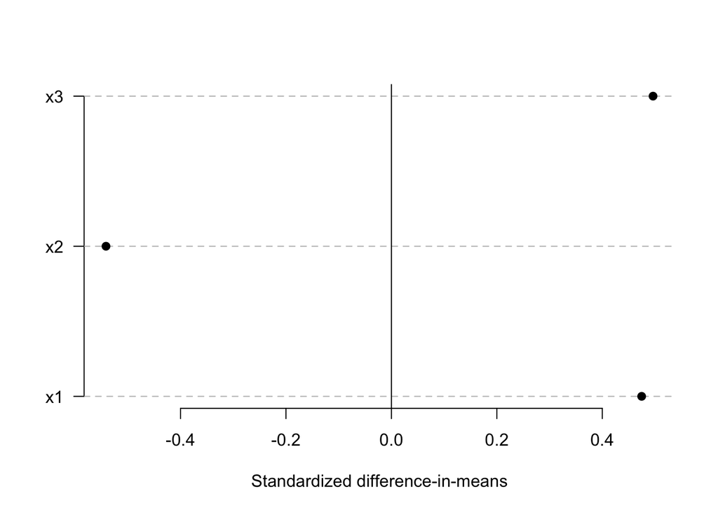

```r
love.plot(check.balance(data[strata == levels(strata)[2],],
                        covars = c("x1","x2","x3")))
```

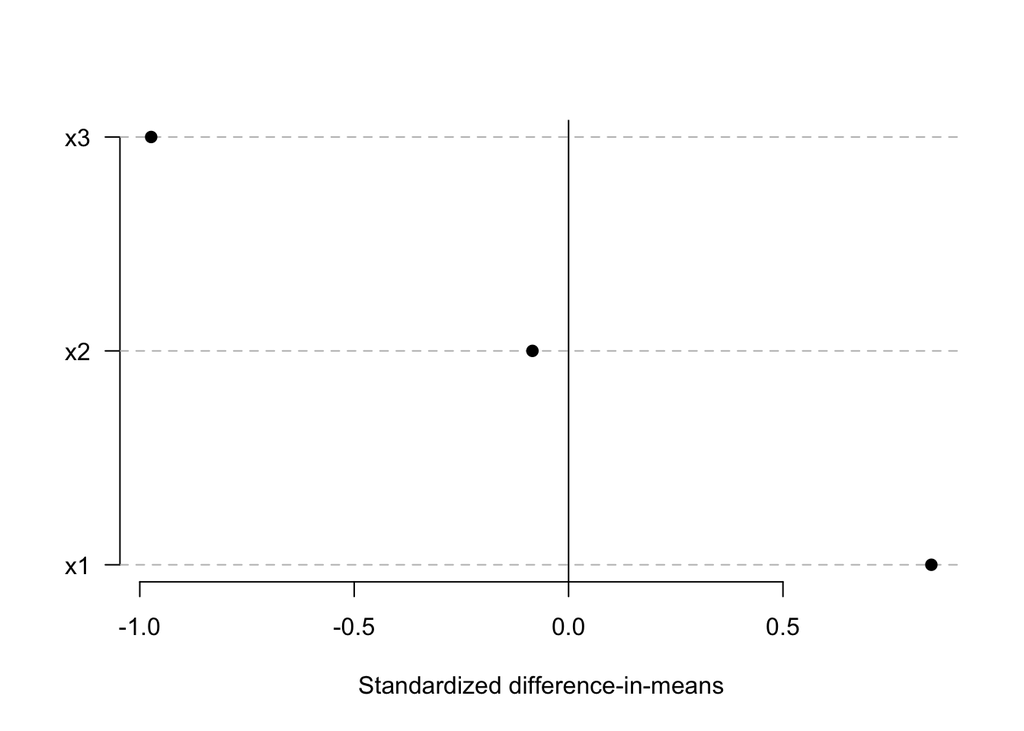

```r
love.plot(check.balance(data[strata == levels(strata)[3],],
                        covars = c("x1","x2","x3")))
```

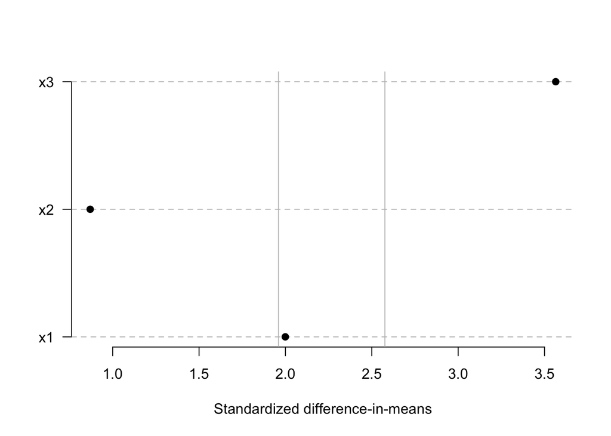

```r
love.plot(check.balance(data[strata == levels(strata)[4],],
                        covars = c("x1","x2","x3")))
```

```r
#### Now that we've got decent balance, let's estimate the ATE

res <- data.frame(y.t = tapply(data$y[data$d == 1],
                               strata[data$d == 1], mean),
                  y.c = tapply(data$y[data$d == 0],
                               strata[data$d == 0], mean),
                  weights = as.numeric(table(strata) / length(strata)))
res$strata.ate <- res$y.t - res$y.c

weighted.mean(res$strata.ate, w = res$weights) # here's our ATE!
```

```
## [1] 2.55
```

### 0.2.2 Matching, Weighting, and Regression

```r
#################################
## Gov 2002 - Fall 2015
## Section 3
## Matching, weighting, and regression
## Stephen Pettigrew
#################################


load("section3_data.RData")

## Get the naive ATE and SE
naive.ate <- mean(data$y[data$t == 1]) - mean(data$y[data$t == 0])
naive.se <- sqrt(var(data$y[data$t == 1]) / sum(data$t == 1) +
                   var(data$y[data$t == 0]) / sum(data$t == 0))
naive.ci <- as.numeric(t.test(data$y[data$t == 1],
                              data$y[data$t == 0])$conf.int)
naive.ate; naive.se; naive.ci
```

```
## [1] 1.47
```

```
## [1] 0.37
```

```
## [1] 0.739 2.192
```

```r
## What if we use regression to estimate the naive effect?
naive.reg <- lm(y ~ t, data = data)
naive.reg.ate <- coef(naive.reg)[2]
naive.reg.se <- sqrt(vcov(naive.reg)[2,2])


## Why don't the SEs match up?
naive.se; naive.reg.se
```

```
## [1] 0.37
```

```
## [1] 0.369
```

```r
#### lmtest::coeftest(naive.reg, vcov = sandwich::sandwich)[[4]]

## How could we use bootstrapping to estimate the SE?

iterations <- 5000
boot.coef <- c()
for(ii in 1:iterations){
  # get the "new" dataset to use in this iteration of the bootstrap
  sampled.rows <- sample(1:nrow(data), size = nrow(data), replace = T)
  boot.sample <- data[sampled.rows,]

  # calculate the quantity of interest with this new datset
  boot.coef[ii] <- coef(lm(y ~ t, data = boot.sample))[2]

  if(ii %% 500 == 0) cat(ii," ") # print every 500th iteration
}
```

```
## 500  1000  1500  2000  2500  3000  3500  4000  4500  5000
```

```r
naive.reg.se; sd(boot.coef)
```

```
## [1] 0.369
```

```
## [1] 0.365
```

```r
###################
#### Matching

#install.packages("cem")
#install.packages("MatchIt")
require(cem)
require(MatchIt)
## What does balance look like in a well-balanced experiment?

n <- 10000
balanced <- data.frame(x1 = rnorm(n),
                       x2 = rnorm(n),
                       t = sample(c(0,1), n, replace = T, prob = c(.5,.5)))
balanced$y <- rnorm(n, mean = balanced$x1 + balanced$x2 + balanced$t)

imbalance(group = balanced$t, d = balanced, drop = c("t","y"))
```

```
##
## Multivariate Imbalance Measure: L1=0.186
## Percentage of local common support: LCS=70.9%
##
## Univariate Imbalance Measures:
##
##    statistic   type       L1    min     25%    50%     75%     max
## x1  -0.00889 (diff) 0.000202  0.773 -0.0166 0.0135 0.00143 -0.2896
## x2   0.03809 (diff) 0.000409 -0.280  0.0239 0.0513 0.03181  0.0994
```

```r
 ## What is L1?

## What does balance look like in our dataset?

imbalance(group = data$t, data = data, drop = c("y", "t"))
```

```
##
## Multivariate Imbalance Measure: L1=0.995
## Percentage of local common support: LCS=0.3%
##
## Univariate Imbalance Measures:
##
##    statistic   type     L1    min     25%      50%     75%    max
## V1  -0.21665 (diff) 0.0659 -0.300 -0.2898 -0.23393 -0.1747 -0.431
## V2  -0.00498 (diff) 0.0073  0.688  0.0902  0.00516 -0.0462  0.152
## V3   0.08025 (diff) 0.0104 -1.335  0.0491  0.05790  0.0943  0.346
## V4  -0.73312 (diff) 0.0255  0.361 -0.6041 -0.82527 -0.9367 -1.950
## V5   0.23672 (diff) 0.0362 -0.488  0.1332  0.26858  0.3544  0.182
## V6  -0.09801 (diff) 0.0980  0.000  0.0000  0.00000  0.0000  0.000
```

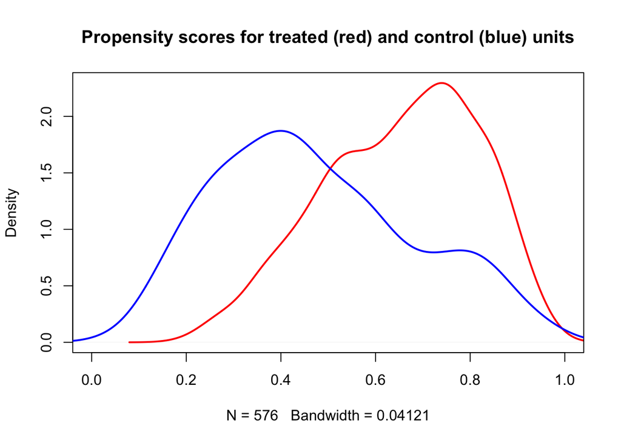

```r
## could also look at love plots like last week



## Let's do propensity score matching to try to improve the balance

pscores <- glm(t ~ V1 + V2 + V3 + V4 + V5 + V6,
               family = "binomial",
               data = data)$fitted.values

plot(density(pscores[data$t == 1]),
     col = "red",
     lwd = 2,
     xlim = c(0,1),
     main = "Propensity scores for treated (red) and control (blue) units")
lines(density(pscores[data$t == 0]),
     col = "blue",
     lwd = 2)
```

```r
# If we were doing subclassification where would we go from here?

m <- matchit(t ~ V1 + V2 + V3 + V4 + V5 + V6,
             data = data,
             replace = T)
m <- match.data(m)
nrow(m)
```

```
## [1] 783
```

```r
imbalance(group = m$t, data = m, drop = c("y", "t", "distance", "weights")) ## we actually made multivar. imbalance a bit worse!
```

```
##
## Multivariate Imbalance Measure: L1=0.998
## Percentage of local common support: LCS=0.1%
##
## Univariate Imbalance Measures:
##
##    statistic   type      L1    min     25%      50%     75%    max
## V1   -0.1416 (diff) 0.05948 -0.300 -0.2220 -0.14923 -0.1036 -0.431
## V2    0.0349 (diff) 0.00944  0.688  0.1003  0.00872 -0.0604  0.829
## V3    0.0824 (diff) 0.01193 -1.388  0.0679  0.08357  0.1076  0.346
## V4   -0.2689 (diff) 0.00853 -0.493 -0.1799 -0.31356 -0.4108 -0.670
## V5    0.0802 (diff) 0.01630 -0.564  0.0283  0.17840  0.1914  0.182
## V6   -0.0248 (diff) 0.02476  0.000  0.0000  0.00000  0.0000  0.000
```

```r
m <- matchit(t ~ V1 + V2 + V3 + V4 + V5 + V6,
             data = data,
             replace = T,
             ratio = 5)
m <- match.data(m)
nrow(m)
```

```
## [1] 920
```

```r
imbalance(group = m$t, data = m, drop = c("y", "t", "distance", "weights")) ## we actually made multivar. imbalance a bit worse!
```

```
##
## Multivariate Imbalance Measure: L1=0.995
## Percentage of local common support: LCS=0.3%
##
## Univariate Imbalance Measures:
##
##    statistic   type      L1    min     25%     50%     75%    max
## V1   -0.1487 (diff) 0.05927 -0.300 -0.1906 -0.1722 -0.0935 -0.431
## V2   -0.0371 (diff) 0.01038  0.688  0.0638 -0.0127 -0.0692  0.152
## V3    0.0742 (diff) 0.01381 -1.381  0.0905  0.0579  0.0787  0.346
## V4   -0.4758 (diff) 0.00408  0.361 -0.4164 -0.6115 -0.6745 -0.734
## V5    0.1936 (diff) 0.02810 -0.564  0.0555  0.2450  0.3379  0.182
## V6   -0.0614 (diff) 0.06137  0.000  0.0000  0.0000  0.0000  0.000
```

```r
m <- matchit(t ~ V1 + V2 + V3 + V4 + V5 + V6 + I(V4^2) + I(V1*V2),
             data = data,
             replace = T)
m <- match.data(m)
nrow(m)
```

```
## [1] 778
```

```r
imbalance(group = m$t, data = m, drop = c("y", "t", "distance", "weights")) ## we actually made multivar. imbalance a bit worse!
```

```
##
## Multivariate Imbalance Measure: L1=0.995
## Percentage of local common support: LCS=0.4%
##
## Univariate Imbalance Measures:
##
##    statistic   type      L1    min     25%     50%     75%     max
## V1   -0.0966 (diff) 0.05769 -0.300 -0.1474 -0.1492 -0.0694 -0.4311
## V2   -0.0458 (diff) 0.00920  0.688  0.0599 -0.0341 -0.1081  0.8433
## V3   -0.0486 (diff) 0.02135 -1.388 -0.0746  0.0333 -0.0497  0.3460
## V4   -0.1778 (diff) 0.00765 -0.672 -0.0399 -0.2420 -0.3314  0.0682
## V5    0.2278 (diff) 0.01774 -0.564  0.0283  0.2645  0.4216  0.1818
## V6   -0.0296 (diff) 0.02957  0.000  0.0000  0.0000  0.0000  0.0000
```

```r
## Let's use this last matched dataset to calculate the effect

ps.matching <- unname(lm(y ~ t + V1 + V2 + V3 + V4 + V5 + V6,
                         data = m)$coefficients[2])
ps.matching
```

```
## [1] 3.37
```

```r
naive.ate
```

```
## [1] 1.47
```

```r
#################
## Weighting estimators

# First calculate the pscores. Let's use the same model we used for pscore matching

pscores <- unname(glm(t ~ V1 + V2 + V3 + V4 + V5 + V6 + I(V4^2) + I(V1*V2),
                      data = data,
                      family = "binomial")$fitted.values)

# The weights for the treated units is the inverse of their p-scores
# The weights for the control units is the inverse of 1-their p-scores

data$weight[data$t == 1] <- 1 / pscores[data$t == 1]
data$weight[data$t == 0] <- 1 / (1 - pscores[data$t == 0])

## Another trick is to use the following formula:
data$weight <- data$t / pscores + (1 - data$t) / (1 - pscores)


weighting <- unname(lm(y ~ t + V1 + V2 + V3 + V4 + V5 + V6,
                       data = data,
                       weights = data$weight)$coefficients[2])
weighting
```

```
## [1] 3.37
```

```r
ps.matching
```

```
## [1] 3.37
```

```r
naive.ate
```

```
## [1] 1.47
```

```r
##################
## Regression imputation estimator

## First do the typical, un-fancy regression
unfancy <- lm(y ~ t + V1 + V2 + V3 + V4 + V5 + V6,
              data = data)
regression <- unname(coef(unfancy)[2])


m.c <- lm(y ~ t + V1 + V2 + V3 + V4 + V5 + V6,
          data = data[data$t == 0,])
m.t <- lm(y ~ t + V1 + V2 + V3 + V4 + V5 + V6,
          data = data[data$t == 1,])

pred.t <- predict(m.t, model.frame(unfancy))
pred.c <- predict(m.c, model.frame(unfancy))
imp.est <- mean(pred.t - pred.c)
### How could we get a SE on this estimate?

imp.est
```

```
## [1] 3.46
```

```r
regression
```

```
## [1] 3.45
```

```r
weighting
```

```
## [1] 3.37
```

```r
ps.matching
```

```
## [1] 3.37
```

```r
naive.ate
```

```
## [1] 1.47
```

```r
## The true ATE is 3.3
## Why is the naive estimator so far off?

## Why are the regression and imputation estimators
## worse than the matching or weighting estimators?
```

### 0.2.3 Fixed Effects and Diff-in-Diff

```r
#################################
## Gov 2002 - Fall 2015
## Section 4
## Fixed effects and diff in diff
## Stephen Pettigrew
#################################

## We first need create some data

set.seed(100)
data <- data.frame(y = runif(100, 0, 100),
                   treat = 0,
                   state = sort(rep(1:50, 2)),
                   year = rep(c(2012,2013),50))
data$treat[seq(2,100,2)] <- sample(0:1, 50, replace = T)
head(data)
```

```
##       y treat state year
## 1 30.78     0     1 2012
## 2 25.77     0     1 2013
## 3 55.23     0     2 2012
## 4  5.64     0     2 2013
## 5 46.85     0     3 2012
## 6 48.38     0     3 2013
```

```r
######################
## First, let's look at 3 ways we could apply the within-tranformation to the data

## Method 1: for-loop

states <- unique(data$state)
states
```

```
##  [1]  1  2  3  4  5  6  7  8  9 10 11 12 13 14 15 16 17 18 19 20 21 22 23
## [24] 24 25 26 27 28 29 30 31 32 33 34 35 36 37 38 39 40 41 42 43 44 45 46
## [47] 47 48 49 50
```

```r
data$state.mean1 <- NA ## create a placeholder for the state mean

for(state in states){
  h <- mean(data$y[data$state == state])
  data$state.mean1[data$state == state] <- h
}


## Method 2: aggregate() function (or you could use by())

h <- aggregate(data$y, by = list(data$state), mean)
h
```

```
##    Group.1    x
## 1        1 28.3
## 2        2 30.4
## 3        3 47.6
## 4        4 59.1
## 5        5 35.8
## 6        6 75.4
## 7        7 33.9
## 8        8 71.6
## 9        9 28.1
## 10      10 52.5
## 11      11 62.3
## 12      12 64.4
## 13      13 29.6
## 14      14 82.6
```

[output cut: 36 more lines]

```r
data$state.mean2 <- h[match(data$state, h$Group.1),2]


## Method 3: using tapply() and split()

###############
## First, an aside about split and unsplit
###############
## split() function:

set.seed(100)
d <- data.frame(obs.id = sample(letters, 26),
                group = sample(1:4, 26, replace = T))
head(d)
```

```
##   obs.id group
## 1      i     4
## 2      g     4
## 3      n     3
## 4      b     2
## 5      k     2
## 6      v     4
```

```r
res <- split(d$obs.id, d$group)
res
```

```
## $`1`
## [1] r f u w
## Levels: a b c d e f g h i j k l m n o p q r s t u v w x y z
##
## $`2`
## [1] b k q p e y a
## Levels: a b c d e f g h i j k l m n o p q r s t u v w x y z
##
## $`3`
## [1] n j x l
## Levels: a b c d e f g h i j k l m n o p q r s t u v w x y z
##
## $`4`
##  [1] i g v h c d s t o z m
## Levels: a b c d e f g h i j k l m n o p q r s t u v w x y z
```

```r
## unsplit() function:

unsplit(res, d$group) # it's somewhat analogous to the expand function in Stata
```

```
##  [1] i g n b k v q h j c r x d f p s t o l e z m u y a w
## Levels: a b c d e f g h i j k l m n o p q r s t u v w x y z
```

```r
head(d)
```

```
##   obs.id group
## 1      i     4
## 2      g     4
## 3      n     3
## 4      b     2
## 5      k     2
## 6      v     4
```

```r
## Now let's use unsplit() and tapply() to get group means

h <- tapply(data$y, data$state, mean)
h
```

```
##    1    2    3    4    5    6    7    8    9   10   11   12   13   14   15
## 28.3 30.4 47.6 59.1 35.8 75.4 33.9 71.6 28.1 52.5 62.3 64.4 29.6 82.6 41.3
##   16   17   18   19   20   21   22   23   24   25   26   27   28   29   30
## 70.8 65.1 79.2 40.5 56.0 59.8 80.2 54.7 83.2 25.7 26.5 25.5 42.2 17.7 40.4
##   31   32   33   34   35   36   37   38   39   40   41   42   43   44   45
## 55.5 81.8 40.1 45.1 47.0 37.0 77.0 64.3 81.6 46.3 52.9 95.1 30.8 49.1 51.7
##   46   47   48   49   50
## 55.8 40.3 64.8 32.1 40.1
```

```r
data$state.means3 <- unsplit(h, data$state)

head(data)
```

```
##       y treat state year state.mean1 state.mean2 state.means3
## 1 30.78     0     1 2012        28.3        28.3         28.3
## 2 25.77     0     1 2013        28.3        28.3         28.3
## 3 55.23     0     2 2012        30.4        30.4         30.4
## 4  5.64     0     2 2013        30.4        30.4         30.4
## 5 46.85     0     3 2012        47.6        47.6         47.6
## 6 48.38     0     3 2013        47.6        47.6         47.6
```

```r
#### Now that we know how to get group means for each observation,
#### let's actually do the double de-meaning

data <- data[,1:4]

dm <- function(variable, group1, group2){
  m1 <- tapply(variable, group1, mean, na.rm = TRUE)
  m1 <- unsplit(m1, group1)
  m2 <- tapply(variable, group2, mean, na.rm = TRUE)
  m2 <- unsplit(m2, group2)
  overall <- mean(variable, na.rm = TRUE)
  variable - m1 - m2 + overall
}

data.demeaned <- data.frame(y.demeaned = dm(data$y, data$state, data$year),
                            treat.demeaned = dm(data$treat, data$state, data$year))

summary(lm(y.demeaned ~ treat.demeaned,
           data = data.demeaned))
```

```
##
## Call:
## lm(formula = y.demeaned ~ treat.demeaned, data = data.demeaned)
##
## Residuals:
##    Min     1Q Median     3Q    Max
##  -39.9  -12.1    0.0   12.1   39.9
##
## Coefficients:
##                 Estimate Std. Error t value Pr(>|t|)
## (Intercept)     5.92e-17   1.79e+00    0.00     1.00
## treat.demeaned -1.07e+01   7.19e+00   -1.48     0.14
##
## Residual standard error: 17.9 on 98 degrees of freedom
## Multiple R-squared:  0.0219, Adjusted R-squared:  0.012
## F-statistic:  2.2 on 1 and 98 DF,  p-value: 0.141
```

```r
## beta: -10.66 (7.189)

## What's wrong with the SE?

########
## Block bootstrap

boots <- 2000
boot.results <- rep(NA, boots)
states <- unique(data$state)
lookup <- split(1:nrow(data), data$state)

set.seed(8675309) # Jenny's phone number

for (ii in 1:boots) {
  states.drawn <- sample(states, length(states), replace = TRUE)
  star <- unlist(lookup[states.drawn])
  boot.dataset <- data[star,]

  data.demeaned <- data.frame(y.demeaned = dm(boot.dataset$y,
                                              boot.dataset$state,
                                              boot.dataset$year),
                              treat.demeaned = dm(boot.dataset$treat,
                                                  boot.dataset$state,
                                                  boot.dataset$year))
  boot.results[ii] <- coef(lm(y.demeaned ~ treat.demeaned,
                              data = data.demeaned))["treat.demeaned"]
  if(ii %% 100 == 0) cat(ii," ")
}
```

```
## 100  200  300  400  500  600  700  800  900  1000  1100  1200  1300  1400  1500  1600  1700  1800  1900  2000
```

```r
mean(boot.results) # -10.63
```

```
## [1] -10.6
```

```r
sd(boot.results) # 10.56
```

```
## [1] 10.6
```

### 0.2.4 Instrumental Variables and Regression Discontinuity

```r
## First simulate some data. Notice that one of the confounders
## is not included in the output and thus unobserved.

simdata <- function(nobs, ate){
  x1 <- rnorm(nobs)
  u <- rnorm(nobs)
  instr <- rnorm(nobs)
  t <- .75*x1 - 3*u + 3*instr
  y <- rnorm(nobs, 3 + 4*x1 - 6*u + ate*t, 2)
  data.frame(y, t, instr, x1)
}

set.seed(3710)
data <- simdata(10000, ate = 3)
head(data)
```

```
##         y       t    instr      x1
## 1  -4.889 -0.3290  0.91669 -0.7975
## 2   0.471  0.0723  0.06393 -0.3376
## 3  -5.381 -2.3220 -0.81168 -0.0898
## 4 -11.662 -3.3683  0.00299  1.3288
## 5 -27.637 -6.3632 -0.66805 -0.6619
## 6  -5.818 -0.1973  1.01858 -1.0620
```

```r
summary(lm(y ~ t + x1, data = data)) ## OLS of y on treatment
```

```
##
## Call:
## lm(formula = y ~ t + x1, data = data)
##
## Residuals:
##     Min      1Q  Median      3Q     Max
## -17.038  -3.104   0.043   3.189  16.265
##
## Coefficients:
##             Estimate Std. Error t value Pr(>|t|)
## (Intercept)   2.9626     0.0466    63.6   <2e-16 ***
## t             3.9949     0.0110   363.8   <2e-16 ***
## x1            3.2521     0.0475    68.5   <2e-16 ***
## ---
## Signif. codes:  0 '***' 0.001 '**' 0.01 '*' 0.05 '.' 0.1 ' ' 1
##
## Residual standard error: 4.66 on 9997 degrees of freedom
## Multiple R-squared:  0.938,  Adjusted R-squared:  0.938
## F-statistic: 7.57e+04 on 2 and 9997 DF,  p-value: <2e-16
```

```r
summary(lm(y ~ instr + x1, data = data)) ## first stage regression of y on instrument
```

```
##
## Call:
## lm(formula = y ~ instr + x1, data = data)
##
## Residuals:
##    Min     1Q Median     3Q    Max
## -52.72 -10.09   0.03  10.29  54.74
##
## Coefficients:
##             Estimate Std. Error t value Pr(>|t|)
## (Intercept)    2.829      0.151    18.8   <2e-16 ***
## instr          9.104      0.152    60.0   <2e-16 ***
## x1             6.349      0.151    42.0   <2e-16 ***
## ---
## Signif. codes:  0 '***' 0.001 '**' 0.01 '*' 0.05 '.' 0.1 ' ' 1
##
## Residual standard error: 15.1 on 9997 degrees of freedom
## Multiple R-squared:  0.352,  Adjusted R-squared:  0.352
## F-statistic: 2.71e+03 on 2 and 9997 DF,  p-value: <2e-16
```

```r
require(AER)
summary(ivreg(y ~ t + x1 | instr + x1, data = data)) ## IV/2SLS estimator
```

```
##
## Call:
## ivreg(formula = y ~ t + x1 | instr + x1, data = data)
##
## Residuals:
##      Min       1Q   Median       3Q      Max
## -22.1386  -4.1800  -0.0262   4.2301  22.9402
##
## Coefficients:
##             Estimate Std. Error t value Pr(>|t|)
## (Intercept)   2.9258     0.0627    46.7   <2e-16 ***
## t             3.0069     0.0208   144.4   <2e-16 ***
## x1            4.0406     0.0650    62.2   <2e-16 ***
## ---
## Signif. codes:  0 '***' 0.001 '**' 0.01 '*' 0.05 '.' 0.1 ' ' 1
##
## Residual standard error: 6.27 on 9997 degrees of freedom
## Multiple R-Squared: 0.888,   Adjusted R-squared: 0.888
## Wald test: 1.57e+04 on 2 and 9997 DF,  p-value: <2e-16
```

```r
#### Wald estimator

## Dichotomize the treatment and instrument
summary(data$t)
```

```
##    Min. 1st Qu.  Median    Mean 3rd Qu.    Max.
##  -15.87   -2.98   -0.05   -0.04    2.91   14.57
```

```r
data$t2 <- data$t > 0

summary(data$instr)
```

```
##    Min. 1st Qu.  Median    Mean 3rd Qu.    Max.
##   -3.43   -0.67    0.00    0.00    0.66    3.50
```

```r
data$instr2 <- data$instr > 0

## Estimate the wald estimator:
## diff in means of y given instrument divided by probability of being treated given instrument

with(data,
     (mean(y[instr2], na.rm = TRUE) - mean(y[!instr2], na.rm = TRUE)) /
        (mean(t2[instr2], na.rm = TRUE) - mean(t2[!instr2], na.rm = TRUE)))
```

```
## [1] 29.1
```

```r
# Alternatively:
coef(lm(y ~ instr2, data))["instr2TRUE"] / coef(lm(t2 ~ instr2, data))["instr2TRUE"]
```

```
## instr2TRUE
##       29.1
```

```r
## Proof that the Wald estimator gives us what we want:
summary(ivreg(y ~ t2 | instr2, data = data))
```

```
##
## Call:
## ivreg(formula = y ~ t2 | instr2, data = data)
##
## Residuals:
##      Min       1Q   Median       3Q      Max
## -55.1725  -8.2956  -0.0912   8.3955  53.1814
##
## Coefficients:
##             Estimate Std. Error t value Pr(>|t|)
## (Intercept)  -11.654      0.268   -43.5   <2e-16 ***
## t2TRUE        29.146      0.481    60.6   <2e-16 ***
## ---
## Signif. codes:  0 '***' 0.001 '**' 0.01 '*' 0.05 '.' 0.1 ' ' 1
##
## Residual standard error: 12.1 on 9998 degrees of freedom
## Multiple R-Squared: 0.58,    Adjusted R-squared: 0.58
## Wald test: 3.67e+03 on 1 and 9998 DF,  p-value: <2e-16
```

```r
#################
## Regression Discontinuity Design

createdata <- function(nobs, te){
  x1 <- rnorm(nobs)
  u <- rnorm(nobs)
  force <- runif(nobs,-2,2)
  t <- force > 0
  y <- rnorm(nobs, 4 - 2*x1 + 3*u + te*t + sin(force)*3)
  data.frame(y, force, t, x1)
}

data <- createdata(nobs = 1000, te = 3)


## Because the cutpoint of the forcing variable is zero, the
## coefficient on the lower order treatment effect is equal to the RDD estimate
lin <- lm(y ~ force * t, data)
summary(lin)
```

```
##
## Call:
## lm(formula = y ~ force * t, data = data)
##
## Residuals:
##     Min      1Q  Median      3Q     Max
## -14.947  -2.479  -0.015   2.611  12.007
##
## Coefficients:
##             Estimate Std. Error t value Pr(>|t|)
## (Intercept)    3.380      0.337   10.03  < 2e-16 ***
## force          1.528      0.294    5.19  2.5e-07 ***
## tTRUE          4.131      0.495    8.35  2.2e-16 ***
## force:tTRUE    0.104      0.427    0.24     0.81
## ---
## Signif. codes:  0 '***' 0.001 '**' 0.01 '*' 0.05 '.' 0.1 ' ' 1
##
## Residual standard error: 3.87 on 996 degrees of freedom
## Multiple R-squared:  0.488,  Adjusted R-squared:  0.486
## F-statistic:  316 on 3 and 996 DF,  p-value: <2e-16
```

```r
cub <- lm(y ~ force * t + I(force^2) * t + I(force^3) * t, data)
summary(cub)
```

```
##
## Call:
## lm(formula = y ~ force * t + I(force^2) * t + I(force^3) * t,
##     data = data)
##
## Residuals:
##     Min      1Q  Median      3Q     Max
## -14.950  -2.564  -0.052   2.622  11.930
##
## Coefficients:
##                  Estimate Std. Error t value Pr(>|t|)
## (Intercept)         4.111      0.688    5.98  3.2e-09 ***
## force               4.132      2.978    1.39   0.1656
## tTRUE               2.945      0.994    2.96   0.0031 **
## I(force^2)          1.916      3.456    0.55   0.5793
## I(force^3)          0.343      1.134    0.30   0.7622
## force:tTRUE        -1.792      4.277   -0.42   0.6753
## tTRUE:I(force^2)   -1.383      4.976   -0.28   0.7811
## tTRUE:I(force^3)   -0.834      1.638   -0.51   0.6108
## ---
## Signif. codes:  0 '***' 0.001 '**' 0.01 '*' 0.05 '.' 0.1 ' ' 1
##
## Residual standard error: 3.86 on 992 degrees of freedom
## Multiple R-squared:  0.49,   Adjusted R-squared:  0.487
## F-statistic:  136 on 7 and 992 DF,  p-value: <2e-16
```

```r
## If we had known that the underlying functional form of the forcing variable
## on the outcome was sinusoidal, then we could get an even better estimate
sinu <- lm(y ~ force * t + I(sin(force)) * t, data)
summary(sinu)
```

```
##
## Call:
## lm(formula = y ~ force * t + I(sin(force)) * t, data = data)
##
## Residuals:
##     Min      1Q  Median      3Q     Max
## -14.862  -2.546  -0.072   2.612  11.980
##
## Coefficients:
##                     Estimate Std. Error t value Pr(>|t|)
## (Intercept)           3.8695     0.4642    8.34  2.5e-16 ***
## force                 0.4509     0.7625    0.59     0.55
## tTRUE                 3.0879     0.6820    4.53  6.7e-06 ***
## I(sin(force))         2.2226     1.4521    1.53     0.13
## force:tTRUE           0.0212     1.0946    0.02     0.98
## tTRUE:I(sin(force))   0.1751     2.0829    0.08     0.93
## ---
## Signif. codes:  0 '***' 0.001 '**' 0.01 '*' 0.05 '.' 0.1 ' ' 1
##
## Residual standard error: 3.86 on 994 degrees of freedom
## Multiple R-squared:  0.49,   Adjusted R-squared:  0.488
## F-statistic:  191 on 5 and 994 DF,  p-value: <2e-16
```

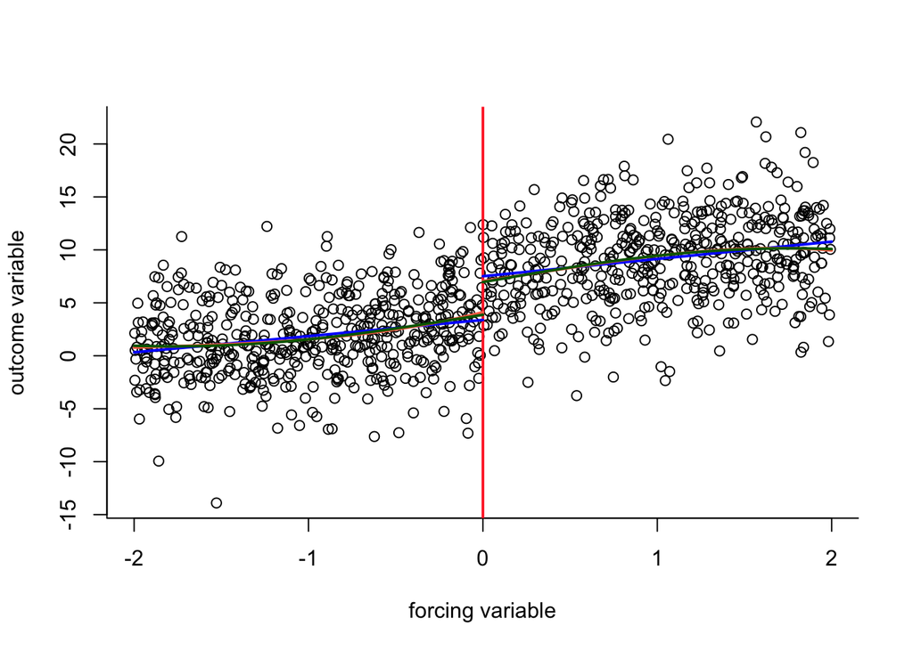

```r
## Let's look at how the estimates from these models look graphically

# First specific values of the forcing variable where we want to get predictions from the models
lo.seq <- seq(-2, 0, by = 0.05)
hi.seq <- seq(0, 2, by = 0.05)

# Get predicted values from the linear functional form model
lin.lo.fit <- predict(lin, data.frame(t = F, force = lo.seq))
lin.hi.fit <- predict(lin, data.frame(t = T, force = hi.seq))

# Get predicted values from the cubic functional form model
cub.lo.fit <- predict(cub, data.frame(t = F, force = lo.seq))
cub.hi.fit <- predict(cub, data.frame(t = T, force = hi.seq))

# Get predicted values from the sinusoidal functional form model
sin.lo.fit <- predict(sinu, data.frame(t = F, force = lo.seq))
sin.hi.fit <- predict(sinu, data.frame(t = T, force = hi.seq))


plot(x = data$force,
     y = data$y,
     bty = "l",
     xlab = "forcing variable",
     ylab = "outcome variable")
abline(v = 0, col = "firebrick1", lwd = 2)
lines(x = lo.seq,
      y = lin.lo.fit,
      col = "blue",
      lwd = 2)
lines(x = hi.seq,
      y = lin.hi.fit,
      col = "blue",
      lwd = 2)
lines(x = lo.seq,
      y = cub.lo.fit,
      col = "coral1",
      lwd = 2)
lines(x = hi.seq,
      y = cub.hi.fit,
      col = "coral1",
      lwd = 2)
lines(x = lo.seq,
      y = sin.lo.fit,
      col = "darkgreen",
      lwd = 2)
lines(x = hi.seq,
      y = sin.hi.fit,
      col = "darkgreen",
      lwd = 2)
```

```r
#########
### Testing different bandwidths

res <- data.frame(full.range = c(coef(lin)["tTRUE"],
                                 coef(cub)["tTRUE"],
                                 coef(sinu)["tTRUE"]),
                  row.names = c("linear","cubic","sin"))

## Try with a bandwidth of 1
res$bw1 <- c(coef(lm(y ~ force * t, data, subset = abs(force) < 1))["tTRUE"],
             coef(lm(y ~ force * t + I(force^2) * t + I(force^3) * t,
                     data, subset = abs(force) < 1))["tTRUE"],
             coef(lm(y ~ force * t + I(sin(force)) * t,
                     data, subset = abs(force) < 1))["tTRUE"])

## Try with a bandwidth of .5
res$bw.5 <- c(coef(lm(y ~ force * t, data, subset = abs(force) < .5))["tTRUE"],
             coef(lm(y ~ force * t + I(force^2) * t + I(force^3) * t,
                     data, subset = abs(force) < .5))["tTRUE"],
             coef(lm(y ~ force * t + I(sin(force)) * t,
                     data, subset = abs(force) < .5))["tTRUE"])


## Try with Imbens-Kalyanaraman bandwidth
require(rdd)
ik.bw <- IKbandwidth(data$force, data$y)
res$bw.ik <- c(coef(lm(y ~ force * t, data, subset = abs(force) < ik.bw))["tTRUE"],
               coef(lm(y ~ force * t + I(force^2) * t + I(force^3) * t,
                       data, subset = abs(force) < ik.bw))["tTRUE"],
               coef(lm(y ~ force * t + I(sin(force)) * t,
                       data, subset = abs(force) < ik.bw))["tTRUE"])


####################
### Lagging a variable
d <- data.frame(state = sort(rep(1:4,3)),
                year = rep(2012:2014,4),
                y = rnorm(12))

d <- d[order(d$state, d$year),] # Make sure the data's sorted properly

## Within each state, create a vector that has the lagged variable for the
## first observation (which should be NA since it's the first observation)
## and the other observations in proper order (except the last one, since
## it's the lagged value for an observation that's not in our dataset)
holder <- tapply(d$y, d$state, function(x) c(NA, x[-length(x)]))
d$lagged <- unlist(holder)
head(d)
```

```
##   state year      y lagged
## 1     1 2012  0.191     NA
## 2     1 2013  1.958  0.191
## 3     1 2014  0.176  1.958
## 4     2 2012 -1.007     NA
## 5     2 2013  1.896 -1.007
## 6     2 2014 -1.623  1.896
```

```r
## The idea is similar with getting the leading value, except the function
## within tapply() is slightly different
d$lead <- unlist(tapply(d$y, d$state, function(x) c(x[-1], NA)))
head(d)
```

```
##   state year      y lagged   lead
## 1     1 2012  0.191     NA  1.958
## 2     1 2013  1.958  0.191  0.176
## 3     1 2014  0.176  1.958     NA
## 4     2 2012 -1.007     NA  1.896
## 5     2 2013  1.896 -1.007 -1.623
## 6     2 2014 -1.623  1.896     NA
```

## 0.3 Mediation package

```r
library("mediation")
set.seed(2014)
data("framing", package = "mediation")
?framing
head(framing)
```

```
##   cond                anx age                        educ gender income
## 1    3   a little anxious  45                 high school   male     13
## 2    4   somewhat anxious  73 bachelor's degree or higher   male     16
## 3    2   a little anxious  53                some college female      3
## 4    1 not anxious at all  45                 high school   male     14
## 5    3   somewhat anxious  55                some college female     12
## 6    1   a little anxious  85                 high school female      3
##   emo p_harm tone eth treat         english immigr anti_info cong_mesg
## 1   7      6    0   1     0          Oppose      4         0         1
## 2   6      3    0   0     0           Favor      3         0         0
## 3   8      7    1   0     0 Strongly Oppose      3         0         0
## 4   9      8    1   1     1 Strongly Oppose      4         0         1
## 5   5      5    0   1     0 Strongly Oppose      2         0         0
## 6   5      6    1   1     1 Strongly Oppose      4         0         0
```

We first fit the mediator model where the measure of anxiety (`emo`) is modeled as a function of the framing treatment (`treat`) and pre-treatment covariates (`age, educ, gender, and income`). Next, we model the outcome variable, which is a binary variable indicating whether or not the participant agreed to send a letter about immigration policy to his or her member of Congress (`cong_mesg`). The explanatory variables of the outcome model include the mediator, treatment status, and the same set of pre-treatment variables as those used in the mediator model.

```r
med.fit <- lm(emo ~ treat + age + educ + gender + income, data = framing)
out.fit <- glm(cong_mesg ~ emo + treat + age + educ + gender + income,
               data = framing, family = binomial("probit"))
```

We now use the `mediate` function to estimate the average causal mediation effects (ACME) and the average direct effects (ADE).

we use a small number of simulations (sims = 100) for the purpose of illustration, one may wish to use the default (1000) or even larger number if the estimates vary too much from one simulation to another.

The default simulation type is the quasi-Bayesian Monte Carlo method based on normal approximation (Imai et al. 2010a).

We use White’s heteroskedasticity-consistent estimator for the covariance matrix from the `sandwich` package (vcovHC; Zeileis 2006) by setting the `robustSE` argument to `TRUE`.

```r
med.out <- mediate(med.fit, out.fit,
                   treat = "treat",
                   mediator = "emo",
                   robustSE = TRUE, sims = 100)
summary(med.out)
```

```
##
## Causal Mediation Analysis
##
## Quasi-Bayesian Confidence Intervals
##
##                          Estimate 95% CI Lower 95% CI Upper p-value
## ACME (control)             0.0791       0.0351         0.15  <2e-16 ***
## ACME (treated)             0.0804       0.0367         0.16  <2e-16 ***
## ADE (control)              0.0206      -0.0976         0.12    0.70
## ADE (treated)              0.0218      -0.1053         0.12    0.70
## Total Effect               0.1009      -0.0497         0.23    0.14
## Prop. Mediated (control)   0.6946      -6.3109         3.68    0.14
## Prop. Mediated (treated)   0.7118      -5.7936         3.50    0.14
## ACME (average)             0.0798       0.0359         0.15  <2e-16 ***
## ADE (average)              0.0212      -0.1014         0.12    0.70
## Prop. Mediated (average)   0.7032      -6.0523         3.59    0.14
## ---
## Signif. codes:  0 '***' 0.001 '**' 0.01 '*' 0.05 '.' 0.1 ' ' 1
##
## Sample Size Used: 265
##
##
## Simulations: 100
```

## 0.4 TODO

https://github.com/TeconomicsBlog/notebooks/blob/master/CausalInference.ipynb http://www.stephenpettigrew.com/teaching/gov2002/ http://rpubs.com/kaz_yos/toc https://rpubs.com/kaz_yos/g-methods1 https://rpubs.com/kaz_yos/confounder1 https://rpubs.com/bbolker/fixed_refit